# SCIE 326 Final

1,577

All phrases694

10 percent per generation1

12.40 ± 0.05 cm1

20 degrees Celsius1

24 hours1

5% compound interest1

52-card deck1

A. Rappaport1

abduction3

abductive1

absolute quantity1

absolute thermodynamic scale1

Abu Hamid al Ghazali1

acceleration due to gravity1

accelerators1

accept as a fact1

accepted domain1

accidental contamination1

accounts of gravity1

accumulated observable changes1

accuracy7

accuracy / precision1

accuracy and precision2

Achilles and arrow paradoxes1

Achilles paradox1

ad hominem1

add their temperatures1

adding ten individuals1

adequacy1

adjusting a new result1

advantages3

adverse-event1

advertisement1

affective1

Alan Turing1

Alan Watts1

Albert A. Bartlett1

Albert Einstein4

alchemy1

Alexander Fleming2

Alexander Friedmann1

Alfred Korzybski1

Alfred North Whitehead3

allowed powers1

Almroth Wright1

alternate theories1

alternative3

alternative explanations2

ambiguous parentage1

analogical5

analogy6

analysed1

analysis11

analytical9

analytical reasoning5

analytical steps1

ancestry tree1

anchoring3

annual compounding1

anomalies1

anomaly2

another argument1

Anthony Zee1

anthropological1

antibiotic drugs1

antibiotic resistance1

apparatus2

apparent contradiction1

apparent credibility1

approximate linearity1

approximation3

arbitrary invention1

Archimedes1

argument21

argument diagram2

argument map1

Aristotelian11

Aristotelian and Baconian accounts1

Aristotelian and Baconian views2

Aristotelian idea of a life cycle1

Aristotelian logic4

Aristotle6

arithmetic1

Arno Penzias1

artificial classifications1

aspect4

aspects3

assimilation versus accommodation1

association1

associational fluency1

associative memory1

assumption33

assumptions22

assumptions omit1

atomic models3

atoms in one mole1

attribute2

attribution error2

autoimmune disease2

autopoiesis5

autopoiesis and self-organization2

auxiliary assumption2

auxiliary assumptions1

availability2

availability can increase1

average5

average temperature1

Avogadro’s number1

avoided1

axiom3

axioms2

back-of-the-envelope calculation2

background radiation1

background universe1

balls1

barometer reading1

base rate1

base-level typology1

baseline2

baseline expectation1

basic assumptions1

beads1

beautiful equation1

beauty in one’s equations1

Bed of Procrustes1

begging the question1

beliefs or expectations1

beliefs or opinions1

beneficial1

Benjamin Disraeli1

better measurement1

Big Bang and Steady State3

Big Bang Theory1

biologists1

birthdays1

Bohr atomic models1

bottom-up6

bottom-up and top-down1

boundaries1

boundary2

breaks1

broken2

broken symmetry2

Bronislaw Malinowski1

bubble chamber1

built-in1

C. H. Waddington2

calibration1

caloric4

calorie theory1

campus library1

canine1

cannot be repeated1

cannot continue indefinitely1

capacity to perform work1

Carl Gustav Jung1

Carl Jung1

cat food1

catastrophe1

catch in this number1

categorical forms1

categorical proposition2

categories6

category8

cats3

causal reasoning1

causal relations1

cause and effect1

cell theory1

Celsius5

Celsius temperatures1

Central Limit Theorem1

central value1

Cepheid variable1

certain3

certainty3

chameleon1

chance favours the prepared mind1

chances are 50-501

changing a theory1

Chapter 191

Chapter 74

characteristics1

Charles Darwin1

Charles Sanders Peirce1

checklists1

Chinese Room2

cholera3

cholera investigation1

chreod2

civilizations1

claims2

Clarence Darrow1

classic thought experiments1

classification11

classification of all necklaces1

classification schemes1

classified3

classify5

close agreement1

cluster of correlated traits1

clustered results1

cognitive illusion5

cognitive illusions2

cognitive strategies1

coherence1

collecting facts1

collection4

collections of objects1

collective development1

collision3

colour4

Columbus1

combined1

combining equal masses1

common-cause3

common-cause principle2

communicate experience1

comparative design1

comparing5

comparison standard1

complement rule1

complementarity1

completeness1

complex logical statements1

complex systems1

components2

compounds2

comprehensive1

computation1

concept of fitness1

conceptual assumptions1

conceptual framework1

conceptual organization1

conclusion7

conclusive argument1

conclusively establishing1

condition9

conditional5

conditional / hypothetical proposition1

conditional logic1

conditional probability2

conditions7

conditions for an experiment1

confidence level1

confirmation and refutation2

conjecture2

conjunction1

connective4

conserved2

consistency2

consistent revision1

constant coefficients1

constrain interpretation1

construct classifications1

constructed4

construction8

construction of scientific facts2

containers1

contemplative and practical purposes1

content1

contention1

contested premise1

continuity3

continuity assumption3

continuous change1

continuous growth1

contradiction5

contradictory3

contradictory laboratory results1

contrapositive4

contrary3

contrary evidence1

contributions of science3

control group3

control information1

controlled experiment4

converse2

convert1

Copernican1

correlate1

correlated2

correlation3

correspondence2

cosmic history1

cosmic microwave background1

cosmology discussion1

Count Rumford1

counter-clockwise1

counterexample4

covering law model2

crash1

creationism1

criteria15

criteria for a typology1

critical8

critical analysis1

critical testing1

critical thinking3

cumulative distances1

cures1

cybernetics1

cyclic pattern1

dangers4

Dante2

Dante and Shakespeare1

data9

data presentation1

data quality1

De Morgan1

debate1

decay3

deduction4

deductive7

deductive reason1

deductive reasoning2

deeply-rooted1

defence of experimentally1

defining trait1

definition of an essence1

definitions3

delay2

deliberately false1

demand for certainty1

demographic figures1

denominator2

denominators1

density4

dentist visits1

dentists in Canada1

dentists required1

depth of sand1

derive4

description, prediction and explanation2

description, prediction, explanation and understanding1

destroys a theory1

determine9

determining1

deterministic1

dextro1

diachronic2

diagram16

diagrammed1

diagrams2

dictionary definition of a fact1

diet1

diet book1

dietary1

different conditions1

different temperatures1

dimensional analyses1

dimensional analysis5

dimensionless constant1

dimensionless factor2

dimensionless factor (beta)1

dimensions4

Dirac and Poincare1

direct causation1

direct proportionality1

direct visibility1

direction of reasoning1

directions of reasoning1

directly proportional1

disconfirming observation1

discourse2

discovery6

discovery and development of penicillin2

Discussion 11.21

Discussion 13.13

Discussion 13.21

Discussion 15.11

Discussion 15.21

Discussion 3.21

distance at equal time intervals1

distant galaxies1

distant galaxy2

distinction5

distinctions2

distinguish162

distinguish evidence1

distinguish productive1

distributed term2

distributed terms1

distribution4

domain of validity1

double3

double-slit1

doubles every six hours1

doubling r1

doubling time2

drag3

drug-resistant bacteria1

drugs2

dynamic5

dynamic symmetry2

dynamic viscosity1

dynamical theories1

dynamics2

E. T. Bell1

earlier model1

earthquake intensity1

ease of enrichment1

ecological niche1

economic forces1

economy1

Edward Jenner2

Edwin Hubble1

effective filters1

effectiveness2

Einstein's elevator1

elaborate dance1

elapsed time for selected distances1

electron2

electron volt1

electron volts1

electrons1

elegant3

elegant theory1

embedded figures1

Emmy Noether1

empathetical6

empathetical reasoning1

empathetical, analogical and analytical reason1

empathetical, analogical and analytical reasoning3

empathy and analogy1

empirical16

empirical and purposive1

empirical basis1

empirical discrepancy1

empirical evidence1

empirical obligation1

empirical proof1

empirical test1

empirical truth4

empirical type2

empirically false1

empty4

empty formal explanation1

empty space1

empty subject class1

enantiomer1

ensemble1

enthymeme1

enumerate1

environmental conditions1

equal masses2

equal time intervals2

equal units of time1

Equation (1) of Discussion 11.11

equilibrium temperature1

equivalences1

equivalent2

Ernest Rutherford2

Ernst Chain1

Ernst Mach1

Ernst Marsden1

error analysis1

Erwin Schrödinger1

essence2

essence of a thing1

essential, statistical and phylogenetic definitions1

establishment1

estimate14

evaluate10

evaluate the claims1

evaluated4

evaluation2

evaluation of causality1

Evariste Galois1

every possible measurement1

evidence14

evidence of effectiveness1

evidence of popularity1

evidence of understanding1

evidential roles1

evolution by variation and selection1

evolution of resistance1

evolution times2

evolutionary theory1

evolved resistance1

evolving1

examples19

excessive inbreeding1

excluded middle1

exclusive or1

exclusive viewpoint1

exemplifies1

expedition1

experience11

experimental8

experimental asymmetry1

experimental classification1

experimental setup1

experimental tests1

experimental uncertainty1

experiments12

explanation14

explanations7

explanatory hypothesis1

exponential growth3

exponential growth and decay2

exponential population growth1

expressional fluency1

external4

external food supply1

external position1

extinction2

extinction of the dinosaurs1

extract heat energy1

extrapolation2

F. Suppe1

facility with words1

fact of experience2

fact of reason2

factors1

facts12

facts of experience2

facts of reason2

factual claim1

Fahrenheit and Celsius1

failed prediction2

fair comparison1

fallacies4

fallacy8

falling bodies2

false conclusion1

false dilemma1

false idea1

false positives1

falsifiability2

familiar analogy1

familiar law1

fast process measurable1

fatality1

favourable1

feedback12

feedback diagram2

feedback loop2

feedback sign1

feline1

fertility1

fiction3

figure8

final conclusions1

final pressure1

finite total1

finiteness1

fit a favourite theory1

fit experiment1

fittest survive1

five beads1

five trials1

fixed amount and temperature1

fixed equilibrium1

flaw in this argument1

fluid4

focus both on them and through them1

food supplies1

food supply3

force4

forces of history1

formal refutation1

formal, causal, statistical and functional explanations3

formal, causal, statistical or functional1

forms of scientific theories1

formulate1

formulation within a theory1

four cards2

four causal principles1

four figures2

four principles of causality1

four-digit binary numbers2

fraction lost1

fraction remains1

framework7

Francis Bacon2

Fred Hoyle1

frequency3

fundamental attribution error1

fundamental attribution fallacy1

further evidence1

G. Spencer-Brown3

Galileo11

Galileo Galilei3

Galileo's inclined plane2

Galileo's inclined-plane work1

Galileo's tied-falling-bodies thought experiment1

Gaussian1

Generabex1

general application1

general law1

general theory of relativity1

generality1

generation times1

generations completed1

generative3

generic name1

genuine1

geometrically1

George Boole1

George Gamow1

Georges Lemaître1

gestalt criteria4

gestalt psychologists1

giraffes1

gold2

good fit4

good form1

good question2

good test of a theory1

Gottfried Wilhelm von Leibniz2

governor1

grains of sand1

gravitational acceleration1

gravitational theory1

greater than one1

greatest European writers1

Gregory Bateson2

Gregory N. Derry2

group9

guide inquiry1

guide research1

half-life2

Hans Geiger1

harmful1

HCl1

heat capacity3

heliocentric1

Henri Poincaré3

Henry Margenau2

Heraclitus1

Hermann Bondi1

Hermann Weyl3

heuristic10

heuristic errors1

heuristic value1

heuristics6

hidden assumption4

hidden assumptions2

hidden influence1

hidden source2

high-energy1

historical5

historical course example1

historical examples1

historical testing1

historical theory1

history6

history of modern cosmology2

homeostasis4

Honoré Fabri1

Hooke's law2

how to assess1

Howard Florey1

human mind1

hunter-gatherer1

hydrogen atom1

hyperbolic1

hypotheses3

hypothesis9

hypothesis formation1

hypothesis testing1

hypothesized2

hypothetical10

hypothetical investigation1

hypothetical organisms1

hypothetical population1

hypothetical system1

hypothetical theory1

hypothetical violation1

hypothetico-deductive3

ideal gas2

ideal gas law1

ideal of natural order3

ideal type2

idealization2

idealized inclined-plane experiment1

ideals of natural order4

identical3

identification numbers1

identity9

identity of indiscernibles6

illustrative3

illustrative, critical and generative thought experiments2

imagined experiment1

imagined intervention1

imagines being a virus1

Immanuel Kant3

immediate inference2

immunity1

implies2

imposed1

improve a model1

improve disagreement1

improvement followed it1

in-built bias1

inadequate criterion1

inappropriate1

inbreeding1

inclined plane experiments1

inclined-plane data1

incremental and all-or-none pictures of learning2

independence4

independent4

independent events1

independent objects1

independent reasons1

independently2

indiscernibles6

individuality1

induction5

inductive4

inductive reason1

inductive reasoning2

infection hypothesis1

infectious disease1

infectivity1

inference11

inference graphically1

inferences as deduction1

infinitely many decreasing intervals1

information7

informative1

insect predation1

instrument4

instrument assumption1

instrumental and theoretical assumptions1

instrumentalism4

instrumentalist1

instrumentation1

instruments2

insulated system1

intellectual humility1

intelligible2

interconnect1

internal3

internal symmetry2

interplay of theory and experiment2

interpretation9

interpreted1

interpreting2

interprets2

interval10

interval or a ratio scale1

intervention caused an improvement1

interventions1

intrinsically older1

intuitional1

invalid inference1

invalidate the conclusions1

invariance of form1

invariant2

invariant under this transformation1

inverse2

inverse relationship1

inversely proportional1

investigation3

iridium1

Isaac Asimov1

Isaac Barrow1

Isaac Newton3

iteration1

J. C. Adams1

J. G. Galle1

J. H. D. Jensen1

J. J. Thomson1

Jacob Bronowski1

James Clerk Maxwell1

James Joule1

James Peebles1

Jean Léonard Marie Poiseuille1

Jenner2

Johann Wolfgang von Goethe1

Johannes Kepler1

John Dalton1

John Searle1

John Snow1

John Stuart Mill2

John Tyndall2

John Venn1

John von Neumann1

Jonas Salk1

Jorge Luis Borges1

judgement1

justification3

justified digits1

justified revision1

Karl Fredrick Gauss1

Karl Friedrich Gauss1

Karl Popper3

kinds of symmetry1

kinematics1

kinetic theory2

Kuhn’s view1

labelled1

laboratory5

language2

Lao Tzu1

late arrival1

law descriptions1

law of coexistence, succession or interaction1

law of conservation of energy1

law of identity2

Law of Large Numbers2

law statement4

laws in science1

laws of coexistence, succession and interaction2

learned framework1

leather worn off1

leave undecided1

left-handed2

legitimate1

legs1

length6

length and width of the beach1

length of stay1

lengths in metres1

Leon Blitzer1

level of discourse2

levo1

Lewis Carroll2

librarian1

light-years1

limitation3

limitations2

limits6

lineages1

linear10

linear algebra1

linear equations1

linear relations3

linear scales4

linear systems1

linear transformation1

linear, exponential and feedback models1

linearly related2

litmus paper1

local comparison1

logical arguments1

logical connectives2

logical contradiction1

logical error1

logical positivist school1

logical validity3

logically2

logically coherent1

lookback time1

Lord Kelvin2

Lorentz contraction1

lottery2

lottery ticket1

Louis Agassiz1

Louis Pasteur2

low velocities1

low-pressure zone1

low-speed drag1

Ludwig Wittgenstein2

Mach's criticism1

Mach's principle1

main hypothesis1

major and minor1

making decisions1

Malthusian argument1

mammals2

many digits1

Margenau's six course criteria1

Margenau's six theory criteria1

Maria Goeppert Mayer1

Marin Mersenne1

marketed1

Martha Weatherby1

Martin Gardner1

Martin Ryle1

mass and distance1

mass starvation1

material substance1

material validity1

mathematical16

mathematical assumptions1

mathematical descriptions1

mathematical elegance1

mathematical exactness1

mathematical invariance1

mathematical science3

mathematical system5

mathematical theorizing1

mathematical theory1

mathematically4

mathematically elegant1

mathematics11

matters2

Max Born1

Max Planck1

mean13

mean speed1

measurable traits1

measurement18

measurement error1

measurement scales5

mechanics2

mediated inference / syllogism1

memory for designs1

mentally fitting things together2

Mercury1

merely restates1

metals1

metaphysical assumptions1

meteor impact1

method of comparison4

metric measurement scales2

metricating1

metrication2

mice2

microscope image1

middle3

Millen Scale1

miniature solar system2

miniature solar system model2

misapplications1

missing evaluative premise1

missing information1

mistaken underlying account1

mistaking the model for reality1

mixed mathematical sciences2

mixture2

model34

model building1

model construction3

model of a reservoir1

modeling1

models17

models of the atom1

mole2

monitored variable1

mood2

more than one role1

Morris's six model criteria1

mountains on the moon1

mouse population1

moving equilibrium2

Murray Gell-Mann1

mushroom-poison1

musical timing2

mutation2

mutual exclusivity1

mutually exclusive events1

N. R. Hanson1

naming3

natural14

natural predators1

natural progression1

natural selection2

nearsightedness1

necessary and sufficient condition1

necklace2

necklaces2

negative feedback2

negative genetic traits1

negative-feedback loop1

negative-feedback system1

Neptune1

new observations1

Newton8

Newton's rotating bucket1

Newton’s theory of gravity1

Newtonian2

Newtonian mechanics2

next state of a single system1

Niccolò Cabeo1

Niels Bohr3

no difference1

no reversals2

nominal4

nominal, ordinal, interval or ratio2

Nominalism1

non-contradiction2

nonempty-class1

nonrandom response rate1

Norbert Wiener1

normal5

normal and revolutionary science2

normal science2

Norman MacLean1

Norwood Russell Hanson1

not linearly related1

not sufficient1

noticing2

nuclear solar-system1

nucleosynthesis1

null3

null hypothesis3

number19

number recognition1

numerical measure1

numerical viscosities1

objections1

observation11

observation from extrapolation1

observational1

observations5

observations intelligible1

observed frequencies1

observed patterns1

obverse1

occupancy1

older2

one phenomenon1

opening hours1

operational measurement1

operational relationship1

optimality principle1

order of magnitude6

order of magnitude estimates3

ordered pain labels1

ordinal5

ordinal scale1

organize observations1

originality1

oscillate1

oscillation1

oscillator1

Oskar Klein1

over-grazing1

overcount1

own experience3

own scientific studies1

p-value2

paradigm6

paradigmatic concepts2

paradigms5

parameter7

parameter fitting2

parameter space2

parameters2

Parmenides1

partial order1

particle6

patient-hours1

patterns of light and dark1

Paul Dirac3

Paul Ehrenfest1

pea plant1

pendulum motion1

penicillin4

perception of events1

period2

permutations1

pesticide-resistant insect1

Peter Dear1

phase change1

philosophers2

philosophy2

photoelectric effect2

phylogenetic4

phylogenetic taxonomy2

physical experiments1

physical law1

physical object1

physical spring1

physical systems1

physico-mathematics2

Pierre Duhem1

Pierre-Louis Moreau de Maupertuis1

planets2

plant-insect interactions1

plants3

plants and insect predators1

plants defend themselves1

Plato8

Plato's five stages2

Plato's learning account1

Platonic solids1

play1

pleasing fit1

plum pudding4

plum pudding model2

Poiseuille's law1

poisonous1

polarities6

polarities of reason4

popular press1

population10

population dynamics1

population of Canada1

population of deer1

populations2

positive4

positive and negative feedback1

positive-feedback1

post hoc, ergo propter hoc1

potential energy3

precise statistical measurement1

precision6

predator-prey feedback diagram1

predator-prey interactions1

predicate2

predict evidence1

prediction12

prediction and testing1

prediction from causal intervention1

premises6

preselected1

preserve1

preserving1

pressure5

pressure gradient1

price1

principle21

principle of equal1

principle of equivalence1

principle of least action1

principles11

principles from specific sciences2

principles listed in Table 14.1.21

principles of interpretation and measurement2

principles of reason4

pro and con1

probabilities2

probability13

probability model1

problem of induction1

process7

product of 3 and 91

productive revision1

properties2

proportional to the object’s velocity1

proportional to v1

proportionality constant1

proposed causal conclusion1

proposed law1

proposition7

propositions1

pros and cons1

Protagoras1

proves a theory1

proving1

psychological2

psychological forces1

psychologism1

public claim1

public schools1

public sources1

publisher’s claim1

purchasers1

purpose6

purpose of a question1

purposeful responses1

qualified interpretation1

qualified position1

qualitative2

quality6

quality / quantity1

quantity6

quantity that remains constant1

quantum numbers2

quantum state1

question-and-answer process1

questionnaire1

questions2

Quine-Duhem thesis2

racemic1

radius3

Ralph Alpher1

random error2

random sample1

random sets of experiences1

randomized1

range1

rate7

rate of this natural development1

ratio9

ratio variables1

ratio-scale1

rational symmetry1

ratios of the readings1

ratios of time elapsed1

raw sensation1

reader feedback1

real danger1

real system1

reason25

reasoning20

recessive trait1

recognition1

reconsider1

Red Queen4

Red Queen race2

redshift1

refer to something real1

reference value2

reflections2

refuted1

regimes1

regularity in nature1

reject1

relatedness1

relational, metric and linear scales2

relative lifespans1

relative time scales1

relevance1

remove particle1

renaming it as a power1

repairing one weakness1

repeated measurements1

repeats the same claim daily1

repetition2

replacement2

representativeness1

reproduce2

reproducible procedure1

reptiles1

resistance7

resistance to evolve1

resistance to flow1

resolution1

resource limits1

response strength1

restoring force1

revision5

revision of a framework1

revolutionary science4

rhetorical fallacy1

Richard Dawkins1

Richard Feynman5

Richard Wiseman1

right-handed1

rival hypothesis1

Robert A. Heinlein1

Robert Anton Wilson1

Robert Dicke1

Robert Herman1

Robert Hooke1

Robert May1

Robert Wilson1

robustness1

rocks1

role in science1

rotations2

rough order of magnitude estimates1

rough order-of-magnitude estimate1

routine work1

Rudy Rucker1

runner wins1

same temperature1

sample selection1

samples4

satellite1

satisfied2

satisfying mechanism1

saturation1

"Saving the appearances"1

scale19

scales15

scaling3

scaling assumption2

scaling assumptions1

scattering1

Schoolmen1

science45

science and philosophy1

scientific44

scientific acceptance1

scientific argument3

scientific descriptions1

scientific example1

scientific fact11

scientific facts8

scientific framework2

scientific idea or hypothesis1

scientific image1

scientific input1

scientific inquiry1

scientific law statement1

scientific model3

scientific paradigms1

scientific theory11

scientific theory construction1

scientific thinking1

scientists3

screening1

search for counterexamples1

seats1

self-organization5

self-regulating relationship1

sensations, apprehensions, perceptions and empirical thought2

sensor1

separation time1

serendipity1

Serious Side Effects1

settle1

seven course1

seven criteria1

seven gestalt criteria3

shared testing1

sharp teeth1

Sherlock Holmes2

shifted zero1

short argument1

similar analysis1

similar meanings1

similarities1

simple arguments1

simple mathematical system1

simple pendulum1

simplest explanation1

simplicity2

simulation2

simultaneous particle states1

single guaranteed scientific method1

sinks one metre in one second1

Sir James Jeans1

six course criteria for scientific facts2

six criteria for a good theory3

six types of scientific theories1

six types of theories2

six-sided1

size of a grain of sand1

size of the effect1

slippery slope1

slope3

small collection1

smallpox2

Snow’s argument1

Sophists1

sort3

source populations1

spatial relations1

spatial scanning1

specified population1

spectacles1

spectral lines1

speed and acceleration1

speed of recognition1

sphere3

sphere radius1

spherical ball bearing1

spread3

spring constant1

square3

square of opposition2

stability5

stable pattern1

stable scientific framework1

standard deviation4

standard error2

standard error of the mean1

standard of measure2

state33

state space3

state transition1

statements7

stating a theory mathematically1

stationary state2

statistical10

statistical significance1

statistical test1

statistical uncertainty1

statistically significant4

statistically significant correlations1

statistically significant result2

statistics2

Stephen Toulmin1

Stillman Drake1

stochastic law1

stochastic variant1

storm frequency1

straight-line relationship1

strategic7

strategic and tactical models2

strategic model2

straw man1

structural2

study visits1

subaltern relations1

subalternation1

subcontrary2

subject4

successful prediction1

successive3

successive approximation2

successive interval distances1

sufficient7

sufficient reason5

supernova1

survival of the fittest1

syllogism9

syllogisms5

syllogistic form1

syllogistic reasoning1

symmetric1

symmetries3

symmetry15

symmetry group1

symmetry transformations1

synchronic2

synthesis2

synthetic2

systematic correction1

systematic error3

systematics2

systems response2

tactical7

tactical model4

take them off1

tannins1

tautology3

taxonomic1

taxonomies1

taxonomy5

telescope2

television1

temperature and pressure1

temperature control1

temperature difference1

temperature scales2

terms12

test17

testable mechanism1

testable understanding1

testing8

testosterone1

tests a claim1

Theodore Roszak1

theorem3

theorems1

theoretical5

theoretical assumptions2

theoretical entity2

theoretical term1

theoria1

theories18

theories and experiments1

theories, hypotheses and observations1

theories, models, paradigms and ideals of natural order2

theory65

theory comparison1

theory ladder2

theory selection1

theory-laden6

theory-laden facts2

theory-laden observation1

theory-ladenness1

thermal equilibrium1

thermometer1

thermostat1

Thomas Gold1

Thomas H. Huxley1

Thomas Kuhn2

Thomas Malthus2

thought experiment13

thought experiments7

three dangers2

three decision heuristics4

three general categories3

three generations1

three heuristics1

three laws4

three original examples2

three principles of reason2

three red and two blue1

three things1

three-bead1

time lag1

time per year1

time-scale estimate1

top-down6

top-down and bottom-up reasoning3

tortoise1

town2

town of 100000 people1

traditional1

traits5

trajectory through state space1

transformed coefficient1

Transitivity1

transmission2

transparency1

treated as identical1

treatment1

true conclusion1

truth table9

truth tables6

tube flow1

tune its parameters1

Turing test2

turned1

twice as hot1

two additional directions1

two behaviours1

two checks1

two explanations1

two foundations3

Tycho Brahe2

type17

type concept1

Type I2

Type II2

typological2

typological identity1

typology8

U. LeVerrier1

unbiased samples1

uncertain assumption1

uncertainty7

uncertainty (error bar)1

unchanging1

“understand” a scientific theory1

understanding4

unexpected measurement1

unfavourable1

uniformity, stability, composition and common cause2

universality1

unobserved theoretical entity1

unrecognized influence1

unreliable evidence1

unrestricted claim1

Uranus1

usable1

use of synonyms1

useful comparison1

useful conjecture1

useful scientific model1

uses of scientific theory2

vaccination1

vague1

valid answer2

valid syllogism1

validation procedure1

validity9

variable15

variable selection1

variables10

variance2

Venn diagram5

Venn diagrams1

verbal comprehension1

violation3

violation of this law1

viscosity5

viscous drag force1

visits to dentists1

visualization1

volt1

volume3

voluntary1

vowel2

W. T. Stace2

W. V. O. Quine1

Walter Gordon1

water clock2

weak assumptions1

weakness2

weather example1

weight of Canada1

well-constructed2

Werner Heisenberg3

what people do1

what they ought to do1

William Blake1

William E. H. Lecky1

William Herschel1

William James1

William of Occam1

William Roberts1

William T. Morris1

willingness1

winning numbers1

world2

writers3

y = C/x1

y = mx1

y = mx + b1

y-intercept1

Ylem1

Yuval Ne'eman1

Zeno of Elea1

Zeroth Law of Thermodynamics1

Zycolon1

694 questions

SCIE 326 Scientific Reasoning · Final · Units 8-15

# Final question bank by key phrase

**694 questions** (84 study guide, 70 objective, 77 recall, 141 term, 128 applied, 162 people, 32 synthesis) and **1,577 underlined key phrases**: the 455 questions of the Final Comprehensive Question Bank, plus 77 recall and 162 people questions with full answers, rebuilt from the "Must-know list" and "Who said what" cards of the earlier Final QA page. Pick a phrase to show only the questions whose wording contains it. Tap a question to show or hide its answer.

**Exam formatFinal format note, the four mixed practice papers and the answer checklist**

### Final exam format

The supplied Final exam format note covers Units 8 to 15 inclusive and describes about 13 short answers worth 5 marks each and 3 long answers or short essays worth 10 marks each. It says the questions resemble those in the study guide in style and difficulty. These approximate allocations add to 95 marks, so they should not be treated as an exact 100-mark blueprint.

The older Student Evaluation page describes a three-hour closed-book final worth 40 percent and says Units 9 to 15. This bank follows the supplied format note by including Unit 8. The broader exam note says that some final versions contain a 300-500 word essay, while others do not. Official study-guide essay lengths are preserved where stated.

### Mixed written practice papers

Each paper selects 13 short questions at 5 practice marks and 3 long questions at 10 practice marks, totaling 95. This mirrors the approximate counts in the supplied note, not an official paper or exact blueprint. All selections reuse bank questions and add no unique prompts. Equal unit weighting is not assumed.

For a three-hour rehearsal, one possible study schedule is about 8 minutes per short answer, 20 per long answer and 16 for planning or review. Adjust this to the instructions and mark distribution of your actual exam.

#### Practice paper 1

Short answers: 13 at 5 marks · Long answers: 3 at 10 marks

1. U8-A01 5 marks A news story repeats the same claim daily. Explain how availability can increase apparent credibility, and describe two checks that could reduce this effect.
2. U9-A01 5 marks Give one argument that is valid with a false conclusion and one that is invalid with a true conclusion. Explain why truth alone cannot establish validity.
3. U10-A01 5 marks Distinguish definitions, axioms and theorems using a simple mathematical system. Explain consistency and why applying the system to nature adds an empirical obligation.
4. U11-A01 5 marks List the rotations and reflections that preserve a square. Distinguish identity, internal symmetry and a change of external position.
5. U12-A01 5 marks Distinguish the experience of seeing a bright point through a telescope from the claim that it is a satellite. Identify the instrumental and theoretical assumptions connecting them.
6. U13-A01 5 marks Compare the contemplative and practical purposes of scientific theory in the course's Aristotelian and Baconian accounts. Explain how one theory might serve both purposes.
7. U14-A01 5 marks Distinguish y = mx, y = mx + b and y = C/x. Give the quantity that remains constant in each relevant relation, and explain why a straight-line relationship need not be direct proportionality.
8. U15-A01 5 marks Use three new examples to distinguish empathetical, analogical and analytical reasoning. For each, explain whether it generates a conjecture, tests a claim or does both.
9. U8-A07 5 marks An argument states that all effective filters remove particles, this device removes particles, therefore it is effective. Identify the logical error and give a counterexample with the same form.
10. U9-A08 5 marks Assess: No reptiles are mammals; some pets are reptiles; therefore some pets are not mammals. Identify the middle term and explain the inference graphically.
11. U10-A07 5 marks A bag contains three red and two blue balls. Find the probability of two red draws without replacement, and compare it with the probability when the first ball is replaced.
12. U11-A08 5 marks A typology mixes colour, price and a vague label such as useful. Evaluate its variables for relevance, universality, qualitative difference and logical independence. Propose clearer operational definitions.
13. U12-A07 5 marks Why is a body at 20 degrees Celsius not twice as hot in the ratio-scale sense as a body at 10 degrees Celsius? Contrast Celsius with an absolute thermodynamic scale.
14. SYN01 10 marks Can a theory be logically coherent, mathematically elegant and empirically false? Develop a supported answer using validity, correspondence, a scientific model and a historical course example.
15. SYN04 10 marks Compare the seven gestalt criteria for a good fit, Morris's six model criteria and Margenau's six theory criteria. Explain which kinds of judgement they support and why they are not interchangeable checklists.
16. SYN08 10 marks Compare empirical truth with logical validity and statistical significance. Explain what each can establish and use a single hypothetical investigation to show their different roles.

#### Practice paper 2

Short answers: 13 at 5 marks · Long answers: 3 at 10 marks

1. U8-A02 5 marks A researcher keeps adjusting a new result to fit a favourite theory. Explain anchoring in the course sense, and distinguish productive use of a framework from resistance to contrary evidence.
2. U9-A02 5 marks Classify the inferences as deduction, induction or abduction: a theory predicts a measurement; repeated measurements suggest a general law; an unexpected measurement suggests a hidden source. Explain their different limitations.
3. U10-A02 5 marks A geometrically exact result describes a measured field only approximately. Explain coherence, correspondence, measurement error and the course continuity assumption in this application.
4. U11-A02 5 marks Explain how drawing a boundary breaks some symmetries while preserving others. Use an example to connect distinction, information and a generic name.
5. U12-A02 5 marks Compare a fact of reason, a fact of experience and a scientific fact using three original examples. Explain the kind of certainty available in each case.
6. U13-A02 5 marks Distinguish description, prediction, explanation and understanding using a weather example. Explain why accurate prediction need not supply a satisfying mechanism.
7. U14-A02 5 marks For an ideal gas at fixed amount and temperature, volume changes from 2 to 5 litres while initial pressure is 150 kPa. Find final pressure and explain the inverse relationship.
8. U15-A02 5 marks A scientist imagines being a virus to generate an infection hypothesis. Explain the heuristic value and the further evidence needed before the hypothesis is accepted.
9. U9-A09 5 marks Assess: All samples are labelled; no controls are samples; therefore no controls are labelled. Identify exactly what the premises leave undecided.
10. U10-A08 5 marks In a hypothetical screening exercise, 10 of 1000 samples truly contain a target. The test detects 9 of those 10 and gives 90 false positives among the other samples. What fraction of positive results are genuine? Explain why the base rate matters.
11. U11-A09 5 marks Distinguish nominal, ordinal, interval and ratio variables in a classification of rocks. Give one example of each and identify which numerical comparisons are justified.
12. U12-A08 5 marks Convert 20 and 30 degrees Celsius using F = 9C/5 + 32. Compare the temperature difference in both units and explain why ratios of the readings are not invariant.
13. U13-A10 5 marks Classify these law descriptions and justify each choice: a restriction on simultaneous particle states; a rule for the next state of a single system; a rule for a collision. Give a stochastic variant of one.
14. SYN09 10 marks Explain how a correlation can contribute to explanation without showing direct causation. Connect heuristic errors, the common-cause principle, comparative design and statistical uncertainty.
15. SYN12 10 marks How does the identity of indiscernibles support naming without eliminating individuality? Discuss symmetry, typological identity, the level of discourse and an experimental classification.
16. SYN16 10 marks Use the development of atomic models to compare analogy, empirical discrepancy, analytical reasoning and successive approximation. Explain why replacement need not erase every useful element of an earlier model.

#### Practice paper 3

Short answers: 13 at 5 marks · Long answers: 3 at 10 marks

1. U8-A03 5 marks A quiet person who enjoys books is classified as a librarian without considering how common different occupations are. Identify the heuristic and the missing information.
2. U9-A04 5 marks State the A, E, I and O categorical forms using a single subject and predicate. Identify the quantity, quality and distributed terms in each.
3. U10-A04 5 marks Explain simplicity, economy, generality and precision as advantages of mathematical theorizing. Show two of these advantages using F = ma.
4. U11-A03 5 marks A classification treats two objects as identical for one purpose but different for another. Explain the level of discourse and the identity of indiscernibles without claiming they are the same physical object.
5. U12-A03 5 marks A microscope image is interpreted differently before and after learning cell theory. Explain theory-ladenness and why shared testing can still constrain interpretation.
6. U13-A03 5 marks Explain the incremental and all-or-none pictures of learning, and relate them to Plato's five stages. Give an example of applying a learned framework to a new case.
7. U14-A03 5 marks Hooke's law is F = -kx and x = ay. Derive the expression in y, identify the transformed coefficient and explain invariance of form without claiming that a physical spring was altered.
8. U15-A04 5 marks Why can a beautiful equation or a familiar analogy guide research without conclusively establishing a claim about nature? Use the Dirac and Poincare contrast from the course.
9. U10-A09 5 marks A lottery chooses five distinct numbers from 40 without regard to order. Derive the probability that one ticket matches all five, and explain why permutations would overcount.
10. U11-A10 5 marks Compare essential, statistical and phylogenetic definitions of a type. Explain when a cluster of correlated traits might be useful even without one defining trait.
11. U12-A10 5 marks Explain why combining equal masses adds their mass but combining equally sized samples at different temperatures does not add their temperatures. State assumptions for taking an average temperature.
12. U13-A11 5 marks Distinguish a regularity in nature from its formulation within a theory. Use changing accounts of gravity to explain how a law statement may change while some observed patterns remain.
13. U14-A08 5 marks Construct a feedback diagram for a thermostat. Label the monitored variable, reference value, sensor, action and feedback sign; explain how delay could produce oscillation.
14. SYN17 10 marks Compare a strategic model, a tactical model and a scientific theory. Use one system to show how questions, variables, data, hypotheses and a conceptual framework interact.
15. SYN20 10 marks Compare normal science and revolutionary science using autopoiesis and self-organization. Explain the benefits and possible costs of a stable scientific framework.
16. SYN24 10 marks Evaluate a Malthusian argument without importing unverified present-day demographic figures. State its mathematical assumptions, discuss limits and feedback, and identify evidence needed to assess a specified population.

#### Practice paper 4

Short answers: 13 at 5 marks · Long answers: 3 at 10 marks

1. U8-A05 5 marks A student explains a classmate's late arrival by laziness but explains their own late arrival by traffic. Analyse the attribution error and propose a fair comparison.
2. U9-A06 5 marks Assess: All biologists are scientists; some teachers are biologists; therefore some teachers are scientists. Identify all three terms and premises, give its figure and mood, and draw a Venn diagram.
3. U10-A05 5 marks A fair six-sided die is rolled twice independently. Find the probability of two sixes and of at least one six. Explain the role of independence and the complement rule.
4. U11-A05 5 marks Under the simplified assumptions in the mushroom-poison problem, compare a pure natural enantiomer with a racemic synthetic mixture. Explain optical rotation, the value of a control sample and why this evidence alone does not establish a person's guilt.
5. U12-A05 5 marks A researcher calls every unobserved theoretical entity a fiction. Compare potential energy and caloric to explain why direct visibility is an inadequate criterion.
6. U13-A04 5 marks Trace sensations, apprehensions, perceptions and empirical thought in the interpretation of an unfamiliar scientific image. Explain where conceptual organization enters.
7. U14-A04 5 marks A population grows by 10 percent per generation from an initial 100. Compute its size after three generations and compare it with adding ten individuals each generation. Explain the different assumptions.
8. U15-A05 5 marks Describe the premises, imagined intervention and inference in Galileo's tied-falling-bodies thought experiment. Explain which assumption the contradiction challenges.
9. U11-A11 5 marks Construct a possible ancestry tree for 000, 100, 010, 110 and 111, starting at 000. Allow one new 1 per step and no reversals. Mark ambiguous parentage instead of inventing a unique history.
10. U12-A11 5 marks Equal masses of the same material at 20 and 80 degrees Celsius are mixed in an insulated system, with constant heat capacity and no phase change. Estimate equilibrium temperature, then explain what fails if the materials differ.
11. U13-A13 5 marks Use Margenau's six course criteria to evaluate a hypothetical theory that is elegant and comprehensive but yields no possible empirical test. Identify the strongest and weakest features.
12. U14-A09 5 marks Construct one positive-feedback and one negative-feedback loop for a hypothetical system. Explain why positive does not mean beneficial and negative does not mean harmful.
13. U15-A11 5 marks A proposed thought experiment assumes both a familiar law and a hypothetical violation of the conditions on which that law depends. Diagnose the problem and outline a consistent revision.
14. SYN25 10 marks Explain how symmetry can serve classification, mathematical invariance and the search for a hidden influence. Discuss the relationship to sufficient reason without treating symmetry alone as empirical proof.
15. SYN28 10 marks Can dimensional analysis establish a physical law? Explain its power and limits using low-speed drag or pendulum motion, including variable selection and an undetermined dimensionless constant.
16. SYN32 10 marks Evaluate the claim that there is a single guaranteed scientific method. Use examples of discovery, modeling, measurement, explanation and critical testing to defend a qualified position.

### Checking your written answers

Definitions should state the essential distinction and include an apt example. Explanations should show how a conclusion follows. Comparisons should use common dimensions. Evaluations should offer reasons and consider a realistic objection. Personal-example questions require your own experience; do not present an invented event as something that happened to you.

For formal logic, write the premises and target conclusion, identify the form, and show the truth table, distribution check or Venn evidence requested. Separate validity from truth and make existential assumptions explicit. For calculations, show the rule, substitutions, units, rounding and interpretation. For experimental questions, state variables, controls, measurement procedure and important limitations.

For models and theories, explain purpose, empirical contact, assumptions, range of validity and prospects for revision. For estimates and dimensional analysis, show how quantities combine and identify missing information. A confident numerical answer with an unstated assumption is weaker than a justified range or a clear explanation of underdetermination.

Unit 8

## Reason and Critical Thinking

Approach Draw argument maps when asked, and distinguish factual evidence from normative assumptions. Use the seven course gestalt criteria rather than unrelated visual-grouping laws.

### Official study guide questions13

U8-SG01Study guide

List and describe the seven gestalt criteria for good form.

Source Unit 8 Study Questions question 1

Gestalt psychologists of the early 20th century studied what makes a "good form" in the visual field. Discussion 8.1 adapts their criteria to scientific hypotheses and arguments, as rules of thumb for judging when ideas "fit" together.

1. **Regularity.** A hypothesis that can be seen as an extension of existing, accepted ideas is preferred to one that requires radical changes in those ideas.

2. **Symmetry.** A hypothesis that is symmetrically related to accepted ideas is preferred; for example, an idea that has succeeded in one field of science is carried over into another field by analogy.

3. **Harmony.** A hypothesis that is in harmony with (resonates with) accepted ideas is preferred, and so is an argument whose structure matches existing patterns of reasoning.

4. **Simplicity.** The simpler hypothesis or argument is preferred.

5. **Conciseness.** The more concise hypothesis or argument is preferred. Simplicity and conciseness are versions of Occam's razor: "entities are not to be multiplied unnecessarily."

6. **Inclusiveness.** The hypothesis that explains the most is preferred. This might seem to clash with simplicity, but in science the simplest theories often turn out to be the most inclusive: Newton's three laws and his law of gravitation explain the planets, falling bodies and the tides; Darwin's variation and natural selection explain the diversity of life.

7. **Unity.** Theories that give a sense of closure, a unified understanding of a whole field of phenomena, are the goal of science.

The first six hold only "all other things being equal." In practice they must be traded off against each other (a more inclusive hypothesis may not be a regular extension of current theory), so finding a good fit is "more a matter of aesthetic sensitivity than of applying fixed rules."

U8-SG02Study guide

Choose one of the two examples of the development of a scientific theory given in Chapter 2 of *What Science Is*, and discuss ways in which it exemplifies the idea of a good fit.

Source Unit 8 Study Questions question 2

I choose the second example in Derry's Chapter 2, **drifting continents** (§2, pp. 30-34). The chapter is called "Nature's Jigsaw," and the story is literally about pieces fitting together: at first they fitted "in more than one way," and only later did one picture become a good fit by every gestalt criterion.

**Why drift was at first a poor fit.**

1. **Regularity and harmony failed.** Wegener's theory (1910 onward) was "a radical innovation." Continents drifting "like icebergs" clashed with common sense and with accepted geophysics, since the lower crust seemed too rigid for the upper crust to move. His proposed force, small gravity differences plus tides, was "millions of times too small." Critics rejected the theory because it did not harmonize with what they already knew, even though it fitted much of the evidence.

2. **A rival fit existed.** Sunken land bridges also explained the matching geology, fossils and living things, so the evidence could be fitted together in two ways and there was "no definite choice."

**How plate tectonics became a good fit.**

3. **Inclusiveness.** One theory came to explain the matching coastlines (Wegener rightly used the edges of the continental shelf), the matching rocks and fossils, the very different past climates of the continents, the worldwide mid-ocean ridges with their central rift, the young basaltic sea floor, the apparent "wandering" of the magnetic pole, the alternating magnetic stripes beside the ridges, the Pacific "ring of fire" and the continental mountain ranges.

4. **Regularity and harmony restored.** Holmes's mantle convection (1928) rests on a well-known fact, that the earth's interior is heated by radioactivity and the heat must escape. Hess's sea-floor spreading (about 1960) extends that idea. Drift now harmonized with accepted physics instead of contradicting it.

5. **Symmetry, in the course's sense of an idea carried over from another field by analogy.** Convection, familiar from the physics of heat and fluids, was carried into the mantle, and compass-needle magnetism was carried into rock (paleomagnetism). Reading the pole data as "the continents wander, not the pole" was a symmetrical reversal that made the measurements fit Wegener's paths exactly.

6. **Simplicity and conciseness.** A few ideas (rigid plates, convection, spreading) replaced many separate explanations, such as a different sunken bridge for each fossil match and a wandering pole.

7. **Unity.** By the mid-1960s Tuzo Wilson and others assembled "all of these pieces into a coherent picture." Plate tectonics became "one of the fundamental organizing principles of modern geology," which is the sense of closure the unity criterion describes.

The case also shows why the criteria hold only "all other things being equal": drift was inclusive from the start but failed regularity and harmony, so it waited for new pieces of evidence. Poincaré's line in the chapter's epigraph, that a collection of facts is no more a science "than a heap of stones is a house," is exactly the difference between Wegener's first evidence and the finished fit.

Note*Outside fact: the magnetic stripes on the two sides of a ridge are mirror images of each other (Vine and Matthews, 1963), which is the symmetry sea-floor spreading predicts. Derry describes the stripes as running parallel to the rifts and alternating outward but does not mention the mirror image.*

U8-SG03Study guide

What are the three heuristics that are used in making decisions? Give examples of each.

Source Unit 8 Study Questions question 3

Discussion 8.2 names three heuristics, or rules of thumb, on which most judgements and decisions are based.

1. **Representativeness.** We quickly pick out a few obvious, easily recognized features of a thing and treat them as characteristic of the whole thing. We cannot keep every feature of a person, animal or object in mind, so we must choose a few.

*Examples:* a group is judged to contain more women if the women in it are famous; after one rude member of a social group we assume the whole group is rude; we expect causes to resemble their effects (Mill's "great events must have great causes"); we judge others by personality rather than circumstance (the fundamental attribution error).

2. **Availability.** We judge frequency, probability and causes by what comes most easily to mind, from the senses or from memory. The mind is "lazy" and avoids long memory searches.

*Examples:* the "traffic light phenomenon," "Why do I always hit the red lights?", because stopping takes effort and causes irritation, so red lights are better remembered; graphic photographs of a murder victim sway a jury because vivid images are easily recalled.

3. **Anchoring.** We quickly select an interpretation, belief, theory or scenario and keep it even against strong contrary evidence, making minor changes or ad hoc excuses rather than changing the "anchor."

*Examples:* the man who says "Must be a woman driver," then, when the driver is a man, "He drives just like a woman!"; believers in astrology who count a few coincidental hits as proof and do not see the many misses as contrary evidence.

All three save mental effort and are essential for thought; they become cognitive illusions when used automatically and uncritically.

U8-SG04Study guide

Give an example from your own experience of how each of these heuristics has led to a cognitive illusion.

Source Unit 8 Study Questions question 4

This question needs real incidents from your own life, so the answer below is a frame: each example is set in a job from your background, written as the kind of thing that happens there. Replace each one with a real memory, keeping the four steps: the situation, the heuristic, the false conclusion, and how the error showed up.

**Representativeness.** *Setting: a first job in a new country, such as kitchen helper at McDonald's in Regina.* If the first co-worker a newcomer deals with is short and impatient during a lunch rush, it is natural to conclude that the whole crew is unfriendly. One vivid encounter is being treated as representative of the group, the error Discussion 8.2 describes in its footnote on first meetings. Weeks of ordinary shifts usually show that most co-workers are helpful and that the rush, not the person, explained the first encounter, so this is also a small fundamental attribution error.

**Availability.** *Setting: building Android and iOS apps.* A handful of angry one-star reviews saying an app "crashes all the time" stick in the mind, and the developer starts to believe it crashes very often. The reviews are vivid and emotional, so they are the most available memories. The crash statistics, which count every session, are the check: if crashes turn out to be rare, the judgement of frequency was following ease of recall, not the record.

**Anchoring.** *Setting: maintaining government applications.* When a system fails just after a software update, it is easy to decide at once that "the update broke it" and then explain away each log entry that does not fit as another side effect of the update, a series of ad hoc patches that keep the first explanation intact. The error shows up when the evidence is listed without assuming the answer and points somewhere else. The anchor had turned every new observation into an instance of the belief instead of a test of it.

In each case the heuristic saves effort, but used without checking it produces a confident and false conclusion: a cognitive illusion.

Note*The Final bank's own advice applies here: "Personal-example questions require your own experience; do not present an invented event as something that happened to you." The settings come from your background file; the incidents are illustrations, not things you have told me happened.*

U8-SG05Study guide

Which fallacy of causal reasoning did John Stuart Mill describe as “the most deeply-rooted, perhaps”?

Source Unit 8 Study Questions question 5

John Stuart Mill called it the prejudice that "**the conditions of a phenomenon must, or at least probably will, resemble the phenomenon itself**" (*A System of Logic*, Book V, "On Fallacies"). In other words, we assume that causes resemble their effects.

Examples from Discussion 8.2: great events must have great causes, complex events must have complex causes, and emotional events must have emotional causes. A disaster that kills thousands therefore "must" have a grand cause such as a conspiracy, when a small cause, such as a microscopic organism, can be enough.

The fallacy is a product of the **representativeness heuristic**: when we look for causes, we tend to consider those whose features match features of the effect.

It matters for science because nature often breaks the rule: Snow's cholera "poison" could not be seen even with a microscope, yet it caused an epidemic (Discussion 3.4).

U8-SG06Study guide

What is the “fundamental attribution fallacy”?

Source Unit 8 Study Questions question 6

The **fundamental attribution error** (the study question calls it a "fallacy") is the tendency, when we observe another person's behaviour, to assume that it is characteristic of their personality rather than a product of the context in which we observe them, even though we explain our own behaviour in terms of the situation (Discussion 8.2).

Example: a driver who cuts us off is "a jerk," but when we cut someone off it is because we were late or did not see them.

Discussion 8.2 presents it as one of the errors of the **representativeness heuristic**: a single observed act is treated as representative of a stable character.

The cure is to look at the situation and at the person's behaviour on other occasions before attributing a fixed trait, which is the same move from one case to a fair sample that science makes.

U8-SG07Study guide

It seems that the perception of events in terms of cause and effect is a built-in aspect of the way the human mind interprets the world, to the extent that we automatically assume causal relations even in completely random sets of experiences. Write a short essay (300-500 words) discussing why such an in-built bias might be of value for a hunter-gatherer.

Source Unit 8 Study Questions question 7

Discussion 8.2 notes that we seem "genetically programmed to identify causal connections on the basis of very weak evidence," while finding it "extremely difficult to infer a lack of causal connections." Even very young children read covariance between events as causality. For a modern scientist this is a weakness, but for a hunter-gatherer it would have been a strength, for at least four reasons.

The first is the difference in cost between two kinds of mistake. Suppose a hunter hears a rustle in the grass. If she assumes it has a cause, perhaps a predator, and she is wrong, she has wasted a few seconds in flight. If she assumes it is random noise and she is wrong, she may be killed. A mind that sees causes too readily makes many cheap mistakes and few fatal ones. A cautious mind that waits for good statistics makes fewer mistakes, but some of them are deadly. Natural selection favours the first kind of mind.

The second reason is speed of learning. A hunter-gatherer cannot run controlled experiments with large random samples. If someone falls ill after eating an unfamiliar berry, treating that single coincidence as a cause, and avoiding the berry, is a sensible rule even if it is sometimes wrong. Learning from one or two experiences keeps people alive in a dangerous environment. Discussion 8.1 makes the same point: we do not survive by strength, speed or camouflage, but "because we are able to learn from experience and make judgements on the basis of what we have learned."

Third, a causal view of the world makes prediction and control possible. Tracking animals by their signs, finding water, timing seasonal gathering, making tools and fire, and reading the moods of others in the group all depend on linking signs to their causes. Even a rough causal story turns a confusing world into one in which action is possible.

Fourth, causal explanations give psychological security. Discussion 8.2 observes that without an interpretive framework "we do not have that comfortable feeling of 'understanding'," and that lack produces insecurity. A group that shares causal explanations, even partly wrong ones, can act together with confidence instead of freezing.

The same bias has costs today. It produces superstitions and belief in astrology, in which a few coincidental hits take on causal power while the many misses go unnoticed, and it encourages post hoc reasoning in politics and medicine. That is why science developed tools such as controlled experiments, random samples, statistics and causal models (Derry ch. 7). These tools keep the useful instinct to look for causes while testing which causes are real.

The bias is therefore best seen as an adaptation to a world in which quick, cautious causal guesses kept people alive. Science does not remove it; it disciplines it.

Note*Essay length: 465 words.*

U8-SG08Study guide

Write a short essay (300-500 words) defending the contention that the three decision heuristics are necessary for any use of language to think about or communicate experience.

Source Unit 8 Study Questions question 8

Discussion 8.2 argues that the three decision heuristics, though they produce cognitive illusions, are essential for science, because things "must be represented, placed in a context of available information for comparisons, and viewed within some conceptual framework." The same is true of any use of language to think about or communicate experience, because each heuristic supplies one thing language cannot work without.

Language depends on **representativeness**. Every common noun names a category, and a category works by letting a few typical features stand for the whole. We "can never keep all of the features of a person, animal or object in mind," so to think or say "dog" we must select a few relevant features and ignore countless others. Discussion 8.1 describes reasoning as discriminating which things fit together into a category, which is then "reborn" as an object of consciousness that we can name and speak about. Without representativeness there would be no general words, only an endless list of particular experiences that could never be shared.

Language depends on **availability**. Speaking and listening happen in real time. To produce or understand a sentence we must retrieve words, meanings and comparisons instantly, using whatever comes to mind first rather than searching our whole memory. Metaphor and analogy, on which much of our thinking relies, work only because familiar images are readily available to compare with new ones; Discussion 8.1's account of *Homo sapiens* as the being who has "tasted" the world is an example.

Language depends on **anchoring**. A sentence has meaning only within a context or framework of interpretation. Discussion 4.2 notes that the cross "means something very different to Christians than it did to the ancient Romans." To understand any utterance we must quickly settle on an interpretation and hold it while the conversation continues; if we kept every possible meaning open and revised it at every word, we could never reply. Without an anchor there is no "comfortable feeling of 'understanding'," only confusion.

The heuristics therefore make thought and communication possible, at the price of occasional errors. The answer is not to abandon them but to refine them, which is what science does. Classification refines representativeness by finding significant categories; statistics and repeatable observation correct the biases of availability; and the study of theories, paradigms and conceptual frameworks shows both the value and the limits of our anchors. As Discussion 8.2 puts it, the evolution of science is a process of "developing tools for the accurate application of these heuristics, rather than their replacement by something new." Huxley was right that scientific thought is everyday thinking made more precise: the heuristics are the everyday thinking, and the tools of science supply the precision.

Note*Essay length: 447 words.*

U8-SG09Study guide

Identify the two foundations for a well-constructed scientific argument discussed in Chapter 7 of *What Science Is*.

Source Unit 8 Study Questions question 9

Derry opens Chapter 7 (p. 89) by saying that a well-constructed scientific argument "generally rests upon two foundations":

1. **Reliable empirical evidence**, and

2. **Sound logical reasoning.**

Shoddy arguments without them "generally don't withstand the test of time." The point is not that science always has both, but that it always should.

The two are independent: a valid argument from false premises can reach a false conclusion (all cows are reptiles; all reptiles can fly; so all cows can fly), and true evidence joined by invalid logic proves nothing (assuming the converse).

Snow's cholera work shows both: the water-company death rates (315 against 37 deaths per 10,000 houses) were the evidence, and his comparison of the two companies' customers, with rival theories answered, was the reasoning.

U8-SG10Study guide

Define “deductive reason” and “inductive reason,” and describe the limitations of each.

Source Unit 8 Study Questions question 10

**Deductive reasoning** finds relationships between statements (premises and conclusion) that guarantee the truth of the conclusion if the premises are true (Derry ch. 7 §1). Its central tool is the syllogism: all cats are cute; Smokey is a cat; therefore Smokey is cute.

*Limitations of deduction:*

1. It is only as good as its premises. A valid argument with false premises can give a false conclusion: all cows are reptiles; all reptiles can fly; therefore all cows can fly.

2. Its advantage is certainty, but "we seldom have any well-defined general premises that we know are true."

3. It cannot run backwards: a true conclusion tells us nothing about whether the premises are true, and false premises tell us nothing about the conclusion. (It does work one way: if the conclusion is false, at least one premise is false.)

4. The conclusion contains nothing that was not already in the premises, so deduction alone cannot discover new facts about the world.

**Inductive reasoning** uses the truth of many particular statements to make a generalization: every cat I have ever seen is cute, so all cats are cute.

*Limitations of induction:*

5. Its conclusions are never certain: "I might run into an ugly cat tomorrow."

6. The problem of induction (Derry ch. 14): no finite set of observations can guarantee a universal statement, and justifying induction by its past success ("induction has always worked") is circular.

7. Inductive conclusions have in fact turned out wrong: the elements were "known" to be unchangeable until Rutherford showed radioactive decay changes one element into another.

8. Its strength depends on the number and quality of the cases: one or two examples are "basically worthless," while thousands of well-controlled, documented cases justify provisional acceptance.

In science the two work together: induction suggests general laws, deduction draws out their consequences, and new evidence tests them.

U8-SG11Study guide

Identify the three general categories of fallacies and describe one fallacy from each category. Give examples of each category of fallacy from the popular press, television or other public sources.

Source Unit 8 Study Questions question 11

Derry (ch. 7 §3) sorts bad arguments into three general categories.

**1. Invalid logic.** The argument attempts a logical structure but the structure is flawed, so the conclusion does not follow even if the premises are true.

*Fallacy described:* **assuming the converse.** From "if A then B" and "B is true," the arguer concludes "A is true." Derry's example: "If taxes are too high, productivity is low; productivity is low; therefore taxes are too high." Productivity could be low for other reasons. (The other invalid-logic fallacies are the inverse and the undistributed middle.)

*Public-source example:* commentary on an economic slowdown often runs: "If a government overspends, interest rates rise; interest rates have risen, so the government has overspent," ignoring central-bank policy and world markets as other causes.

**2. Invalid evidence.** The logic may be fine, but the facts it rests on are false, incomplete or misleading.

*Fallacy described:* **suppressed evidence** (an error of omission). We are told the truth, but only part of it: a politician says she has only five thousand dollars in her bank account and omits the two million dollars she has in stocks.

*Public-source example:* advertisements for sugary breakfast cereals that announce "fat-free" or "with added vitamins," true statements that omit the high sugar content. A related case of invalid evidence from the press is Andrew Wakefield's 1998 study linking the MMR vaccine to autism, which rested on only 12 children and was retracted by *The Lancet* in 2010.

**3. Rhetoric and fallacy.** Persuasive devices that convince without valid logic or evidence: the straw man, ad hominem, false dilemma, begging the question and slippery slope.

*Fallacy described:* the **false dilemma**: two alternatives are offered as the only possibilities, one is shown to be bad, and the other is declared correct, though many other options exist. Derry's example: "We must engage in a massive military buildup because unilateral disarmament will surely lead to the destruction of our country."

*Public-source example:* President George W. Bush's televised address of 20 September 2001, "Either you are with us, or you are with the terrorists," which left out every position in between.

Note*Outside facts: the Wakefield study and retraction, and the wording and date of Bush's 2001 address. The cereal and economic examples are typical forms rather than quotations; if the exam asks for sources, name a specific item you have seen yourself.*

U8-SG12Study guide

In Discussion 8.3, we analysed and diagrammed an argument in favour of giving creationism equal time with evolution in the public schools. Carry out a similar analysis of the argument against this idea and construct a diagram based on your analysis. Then, combine the pro and con diagrams into a single diagram, and from this diagram list two additional directions in which each side in the debate might continue to develop their arguments.

Source Unit 8 Study Questions question 12

**1. Analysis of the con argument** (the "Con" paragraph of Discussion 8.3), using the steps the discussion lists:

- *Conclusion:* creationism should not be taught as a legitimate scientific alternative to evolution, so it should not get equal time in public-school biology.

- *Basic assumption:* to count as science, a theory must make testable claims and fit the empirical evidence.

- *Evidence:* almost all biologists accept evolution by natural selection; the fossil record; antibiotic-resistant strains of bacteria; disagreements among biologists concern details only, "as is the case with every accepted scientific theory."

- *Supporting claims:* evolution is a well-supported scientific theory; creationism rests on an untestable hypothesis and ignores or misinterprets the evidence; so it is "nothing more than an attempt to sneak a religious belief into science classes."

- *Hidden assumption:* science classes should teach only ideas that meet scientific standards, so not every claimed alternative is owed equal time. (A second one: the agreement of almost all experts is good evidence about a scientific question.)

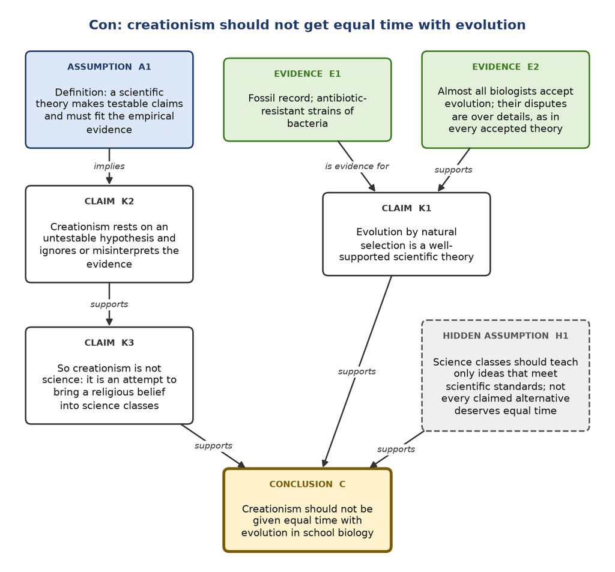

**2. Combined diagram.** The pro boxes follow Figure 8.3.3; each con box is attached, with a dashed red arrow, to the pro element it disputes.

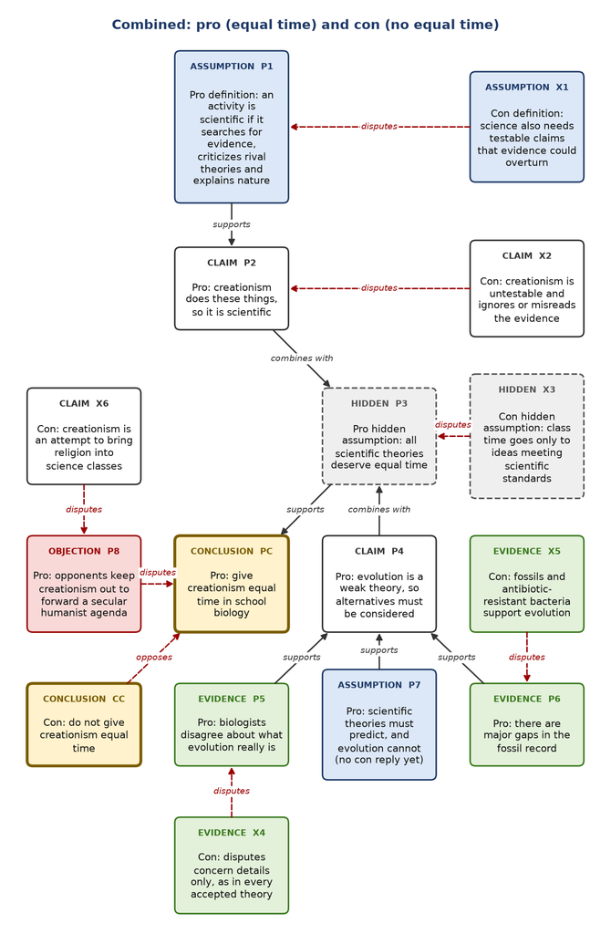

Note*Box key for both diagrams: blue = assumption, dashed grey = hidden assumption, green = evidence, white = claim, red = objection, yellow = conclusion. Dashed red arrows dispute or oppose.*

**3. Further directions shown by the combined diagram.**

*Pro side:*

- Answer X2 (untestability) by stating positive, testable predictions that creationism makes and that observation could refute. Derry notes that creation science "has never even attempted to construct a positive research program" (ch. 12 §4), so this is where the pro case is weakest.

- Defend its hidden assumption P3 against X3: argue why fairness in education requires equal time even for a minority view, or defend its own definition of science (P1) against the con definition (X1) using an accepted account of science.

*Con side:*

- Answer P7, the one pro box with no con reply: show that evolution does make testable predictions (the order of fossils in the rock layers, intermediate forms, the spread of drug resistance) and explain why a historical science need not predict exactly when a new species will appear.

- Support X2 in more depth by applying Derry's criteria of pseudoscience to creation science: its ideas are static, it lacks organized skepticism, its explanations are ad hoc and "loosely connected," and it disregards established results in geology and physics (ch. 12).

- (A third direction) Reply to P6 directly: gaps in the fossil record are expected because fossilization is rare, and each new find has fitted the evolutionary sequence.

As Discussion 8.3 warns, the diagram itself proves nothing; it shows where the evidence and the links between claims need to be argued.

U8-SG13Study guide

In Unit 3, you read about the way that John Snow came to his conclusion about how cholera was spread. Review this story and then construct a diagram of Snow’s argument. Clearly identify his basic assumptions, evidence, responses to alternate theories and final conclusions.

Source Unit 8 Study Questions question 13

**The story (Discussion 3.4).** In the London epidemic of 1853-54, John Snow argued that cholera is spread by a "morbid material" from victims' excretions, carried in water and on hands and food. The rival theory was "effluvia": something given off in patients' exhalations or by the dead.

- **Basic assumptions:** cholera is a communicable disease caused by swallowing a material from victims; an agent can be real even if it cannot yet be seen.

- **Hidden assumption:** the customers of the two water companies differed only in their water. Snow defended it: the pipes ran down the same streets, "each Company supplies both rich and poor," and 300,000 people were "divided into two groups without their choice."

- **Evidence:** cases spread by close contact; those who washed victims' linen often fell ill, while careful hand-washers rarely did; in Soho, cases clustered around the Broad Street pump and fell after its handle was removed, while the workhouse (own well) and brewery (beer) nearby were spared; deaths per 10,000 houses were 315 for Southwark & Vauxhall (sewage-contaminated intake), 37 for Lambeth (upstream intake) and 59 for the rest of London.

- **Responses to alternative theories:** against effluvia, not everyone who breathes them falls ill, and outbreaks begin where no one was exposed to a victim; other routes of spread are known, so there is no need to focus on effluvia. Against "no agent can be seen," the matter of smallpox and chancre "can only be recognized by their effects."

- **Final conclusion:** cholera spreads through water, hands and food contaminated by victims' excretions, so clean water, hand washing, washing of linen, drainage and the other public-health measures follow.

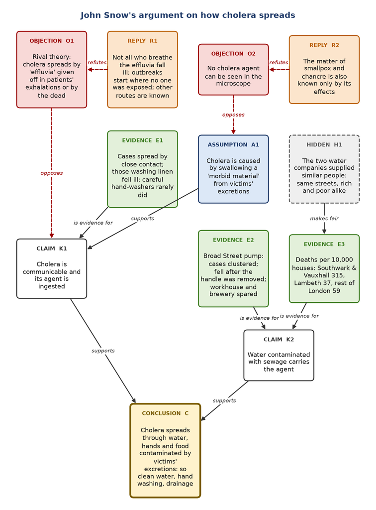

Note*Box key: blue = assumption, dashed grey = hidden assumption, green = evidence, white = claim, red = objection (rival theory), orange = Snow's reply, yellow = conclusion. Dashed red arrows oppose or refute.*

The diagram shows why the argument was strong: two independent lines of evidence (personal contact and the water comparison) converge on the conclusion, and both rival objections are answered. Snow's work did not prove his theory, but it gave "sufficient reasons"; *Vibrio cholerae* was identified about 30 years later.

### Learning objective questions12

U8-OBJ01Objective

explain reasoning as a process of mentally fitting things together, and describe, briefly, three sorts of reason-empathetical, analogical and analytical.

Source Unit 8 Overview objective 1

1. **Reason as fitting together.** "Reason" (and "ratio") comes from the proto-Indo-European root *ar*, "to fit together," so reasoning is the mind's process of fitting things together (Discussion 8.1). Sensations are fitted into perceptions, perceptions into thoughts, and thoughts into judgements and actions.

2. **It needs distinction as well as fitting.** To know how a watch works we must first know what its pieces are and then how they fit; we must distinguish a thing from its environment before we can see how it fits into it. Logic (root *leg*, "to collect" or "to speak") studies how things can be collected into categories and spoken about.

3. **Empathetical reason** places us inside another point of view experientially, not just analytically: "walk a mile in their shoes." It gives "the real feeling of a fit," like good taste in design.

4. **Analogical reason** fits things together by likeness and metaphor. Discussion 8.1's example: *Homo* (from a root meaning "earth") *sapiens* (from *sap*, "taste, perception") is, by analogy, the being of the earth who has "tasted" the world and so become perceptive.

5. **Analytical reason** is the "cold calculation" we usually call rational: breaking a situation into components and working out their logical relations, as in deduction. It is a tool of reason, not the whole of it; the Overview says formal logic is no more the same as reason than a hammer is the same as carpentry.

U8-OBJ02Objective

describe seven criteria for a “good fit,” and apply them to reasoning.

Source Unit 8 Overview objective 2

**The seven criteria** (Discussion 8.1): regularity (extends accepted ideas), symmetry (symmetrically related to accepted ideas, often an idea carried from one field to another by analogy), harmony (resonates with accepted ideas and patterns of reasoning), simplicity, conciseness (both forms of Occam's razor), inclusiveness (explains the most) and unity (gives closure, a unified understanding of a field).

**Applying them to reasoning,** using Darwin's theory as the example:

1. *Regularity and harmony:* natural selection extends a familiar practice, the artificial selection used by breeders, and fits the long geological time scale accepted by geologists.

2. *Symmetry:* an idea from another field is carried over by analogy, Malthus's struggle for existence in human populations applied to all living things.

3. *Simplicity and conciseness:* two ideas, variation and natural selection, do the work.

4. *Inclusiveness:* they explain "the vast diversity of life on earth" (Discussion 8.1).

5. *Unity:* the theory became a central organizing principle of biology.

The criteria are rules of thumb, applied "all other things being equal," and they can conflict: a theory may be more inclusive but less regular (Wegener's drift). A pleasing fit guides inquiry, but it is not empirical proof; evidence still decides.

Note*Outside facts: Darwin's use of artificial selection and of Malthus's essay on population. The course itself names only Darwin's "variation and natural selection" and its inclusiveness.*

U8-OBJ03Objective

define the three decision heuristics and give examples of how they operate in thought.

Source Unit 8 Overview objective 3

1. **Representativeness:** the quick selection of a few obvious, easily recognized features of a thing, used as characteristic of the whole thing. *In thought:* on meeting one rude member of a group, we assume the whole group is rude; in looking for causes, we pick causes that resemble the effect.

2. **Availability:** judging frequency, probability and causes by what comes most easily to mind, through the senses or memory. *In thought:* "Why do I always hit the red lights?"; vivid, emotional events such as a graphic crime photo are over-weighted.

3. **Anchoring:** the quick selection of an interpretation, belief or scenario that is then kept even against strong contrary evidence, patched with minor changes and ad hoc excuses. *In thought:* the "woman driver" joke; astrology believers who notice the hits and not the misses.

4. **Why we use them:** the mind is "lazy" and avoids long analysis; the heuristics let us recognize, compare and interpret quickly, and without them thought would be impossible.

5. **Their place in science:** they are not replaced but refined. Classification sharpens representativeness, statistics and repeatable observation correct availability, and awareness of paradigms and conceptual frameworks shows the value and limits of anchors (Discussion 8.2).

U8-OBJ04Objective

give examples of some of the cognitive illusions that result from use of the three decision heuristics.

Source Unit 8 Overview objective 4

**From representativeness:**

1. Vivid but unrepresentative features dominate: a group's share of women is estimated higher when the women in it are famous.

2. Small samples are taken as typical: one rude person stands for a whole social group.

3. Mill's causal fallacy: causes are assumed to resemble effects (great events must have great causes).

4. The fundamental attribution error: other people's behaviour is put down to personality, our own to the situation.

**From availability:**

5. The "traffic light phenomenon": red lights take effort and irritate us, so they are remembered better, and we think we always hit them.

6. Vivid and emotional events, such as graphic pictures of a murder victim, are judged more frequent or more important than they are, and lists of possible causes recalled from memory may have been pre-selected by hidden biases.

**From anchoring:**

7. The "woman driver" joke: contrary cases are explained away ("He drives just like a woman!").

8. We believe what we hear or read first and doubt only later, which advertisers exploit with distracting "cognitive noise."

9. Causes are seen in random covariation, and contrary cases are ignored: a few coincidences make a horoscope seem to have causal power, while the misses are not counted as evidence.

U8-OBJ05Objective

state the two foundations of a well-constructed scientific argument.

Source Unit 8 Overview objective 5

A well-constructed scientific argument rests on two foundations (Derry ch. 7, p. 89):

1. **Reliable empirical evidence**, and

2. **Sound logical reasoning.**

Both are needed: a valid argument from false premises can give a false conclusion, and accurate data joined by invalid logic prove nothing. Arguments lacking them "generally don't withstand the test of time"; science does not always have both, but it always should.

U8-OBJ06Objective

define “deductive reasoning” and “inductive reasoning,” and describe each briefly.

Source Unit 8 Overview objective 6

1. **Deductive reasoning** looks for relationships between premises and a conclusion such that the truth of the premises guarantees the truth of the conclusion (Derry ch. 7 §1).

2. Its standard form is the **syllogism**, two premises and a conclusion: all cats are cute; Smokey is a cat; therefore Smokey is cute. Its strength is certainty; its weakness is that we seldom know general premises to be true.

3. **Inductive reasoning** uses the truth of many particular statements to reach a generalization: every cat I have seen is cute, so all cats are cute.

4. Its strength is that it lets us learn general things from experience, and some use of induction is "almost unavoidable"; its weakness is that the conclusion is never certain ("I might run into an ugly cat tomorrow").

5. An inductive conclusion deserves the respect its evidence earns: one or two examples are "basically worthless," while thousands of well-controlled, documented cases justify provisional acceptance.

U8-OBJ07Objective

describe some ways in which the use of critical analysis in everyday life can benefit from scientific input.

Source Unit 8 Overview objective 7

Derry (ch. 7 §2) lists several ways in which scientific habits of thought improve everyday critical analysis.

1. **Using basic knowledge as a constraint.** Some scientific knowledge is so secure that it rules out premises without further study: a policy that depends on creating energy from nothing violates conservation of energy; the earth is finite, so any argument assuming limitless resources is wrong; exponential growth has fixed arithmetic properties whatever the subject. These tell us what must be wrong rather than what is right.

2. **Probabilistic thinking.** Instead of insisting a claim is simply right or wrong, estimate how likely it is, rank the alternatives and test the best first. This keeps us open to new information while still allowing judgements.

3. **Finding hidden assumptions.** Bring unstated premises into the open so their truth can be examined (the enthymeme "Sacco is evil because he is an anarchist").

4. **Evaluating causality.** Avoid post hoc reasoning, consider a common cause, multiple causes, feedback and coincidence, and ask whether a cause is necessary and sufficient.

5. **Models and analogies.** Since models are a kind of analogy, experience with models helps us judge whether an argument's analogy is apt or wildly inappropriate.

6. **Quantitative thinking.** Ask how accurate and precise the numbers are, check them with an order-of-magnitude estimate, and compare them with something relevant, such as a percent change (a 1.2 percent "increase" is a cut when inflation is 4.5 percent).

More generally, science shows reasoned discourse at work on relatively tidy problems, and its skeptical attitude encourages critical analysis across many issues.

U8-OBJ08Objective

discuss the importance of identifying hidden assumptions in both science and everyday life.

Source Unit 8 Overview objective 8

1. **Why they matter.** A conclusion rests on its premises, but in everyday argument premises are often implied or taken for granted. A hidden assumption "may or may not be correct, but until we bring it out into the open by making an explicit statement of the assumption, we can't engage in an analysis of its correctness" (Derry ch. 7).

2. **The enthymeme.** A syllogism with an unstated premise: "Sacco is evil because he is an anarchist" hides the major premise "all anarchists are evil," which, once stated, is plainly questionable.

3. **In science.** A chemist who pumps the air out of a container assumes the leftover oxygen (about 0.01 percent) will not affect the reaction; physicists assumed the measured speed of light depends on the observer's motion until Einstein stated it was only an assumption, and a false one; biologists assumed every organism is either a plant or an animal; medical researchers assumed studies on adult males apply to everyone.

4. **In everyday life and politics.** Gun-control debates assume a relationship between the legal availability of guns and violent crime; arguments against environmental rules assume they cost jobs; large tax-cut proposals assume no link between revenue and government services.

5. **The lesson.** Hidden assumptions can be right or wrong, and the most important ones are often shared by both sides of a debate; stating them is the first step of critical analysis and of argument diagramming (Discussion 8.3).

U8-OBJ09Objective

discuss some of the issues involved in the evaluation of causality.

Source Unit 8 Overview objective 9

1. **Post hoc, ergo propter hoc** ("after this, therefore because of this"): one event following another is not proof that the first caused the second. Inflation followed Carter's election, but earlier spending and the oil cartels' price rises were more plausible causes.

2. **A common cause.** A car needing engine repairs, then a muffler, battery and tires does not mean each problem caused the next; the car's age causes them all. "C causes both A and B" is often worth considering.

3. **Other alternatives to a direct link:** many partial causes contributing to one effect, a feedback loop in which each affects the other, or plain coincidence. Correlation alone does not show causation.

4. **What rigorous proof needs.** The cause must be shown to be both **necessary** (present whenever the effect occurs) and **sufficient** (the effect always follows), which science can sometimes do with carefully controlled experiments.

5. **When that is impossible.** With multiple partial causes, or when monetary and ethical limits rule out controlled experiments (as in many biomedical studies), we settle for a statistical inference from a large random sample. For a one-time historical event, rigorous proof is "virtually impossible"; we can only weigh all known factors and make a convincing, probable case.

6. **A causal model** makes a claim more believable by explaining how A produces B: the link between smoking and lung cancer rests on statistics plus the physiology of the carcinogenic tars.

U8-OBJ10Objective

apply the affective and cognitive strategies of critical thinking.

Source Unit 8 Overview objective 10

**Affective strategies** are the attitudes or dispositions of a good thinker; **cognitive strategies** are the techniques used to analyse and evaluate claims.

**Affective strategies:**

1. *Intellectual humility and suspending judgement:* recognizing that our first interpretation may be an anchor, and holding conclusions provisionally (probabilistic thinking, Derry ch. 7).

2. *Fair-mindedness and empathy:* stating an opponent's position in its strongest form before criticizing it (avoiding the straw man) and seeing how their world fits together (empathetical reason, Discussion 8.1).

3. *Thinking independently and with courage:* judging an idea on its merits, not on who holds it (avoiding ad hominem and deference to authority).

4. *Intellectual integrity and perseverance:* holding our own views to the same standard as others' and working through difficult evidence instead of giving up.

**Cognitive strategies:**

5. *Clarify the argument:* identify the conclusion, premises and hidden assumptions, and diagram them (Discussion 8.3).

6. *Check the logic:* test for the converse, the inverse and the undistributed middle.

7. *Evaluate the evidence:* its source, documentation, plausibility, suppressed evidence, sample size and randomness, question wording.

8. *Evaluate causal claims and numbers:* look for post hoc reasoning and common causes, and check figures against an order-of-magnitude estimate.

**Applying them** to a claim such as "a new supplement boosts memory; thousands of satisfied customers say so": affectively, I notice that I want it to be true and suspend judgement; cognitively, I see that the testimonials are a self-selected sample with no comparison group, that improvement after use may be post hoc, and that the seller has a stake in the claim, so I would look for a controlled trial.

Note*The course never defines "affective and cognitive strategies": the phrase appears only in this objective, not in Discussions 8.1 to 8.3 or Derry Chapter 7. The terms match Richard Paul's well-known list of critical-thinking strategies (Foundation for Critical Thinking), which divides 35 dimensions into 9 affective strategies (such as thinking independently, fair-mindedness, intellectual humility, courage, integrity, perseverance and confidence in reason) and cognitive macro-abilities and micro-skills (such as clarifying issues, evaluating sources, examining assumptions and exploring implications). This answer maps those categories onto the course's own tools.*

U8-OBJ11Objective

define the three general categories of fallacies, identify the fallacies in each category and give examples of each fallacy.

Source Unit 8 Overview objective 11

Derry (ch. 7 §3) divides bad, or materially invalid, arguments into three categories.

**1. Invalid logic** (the structure is flawed):

- *Assuming the converse:* "If I am a corporate executive, I make a good salary; I make a good salary, so I am a corporate executive." I might be a doctor or a basketball star.

- *The inverse:* "All dimes are coins. This is not a dime, so it can't be a coin." It may be a nickel. Also "those who support the war are patriotic, so those who don't are not."

- *The undistributed middle:* "All cats are cute; all dogs are cute; therefore all cats are dogs." The middle term must be distributed at least once. The FOPL case: Jones is a member of a "Communist front," so Jones is a Communist. The rule: no conclusion stronger than its premises.

**2. Invalid evidence** (the facts are false or misleading):

- *The lie:* claims made with no regard for truth, such as tobacco-industry spokespersons' claims.

- *Suppressed evidence (error of omission):* the politician with $5,000 in the bank and $2 million in stocks; an ad praising ingredients that all competitors also contain.

- *Selective quotation:* a sentence fragment quoted out of context from an hour-long speech.

- *Unreliable or uninformed sources:* "many scientists agree"; an anti-vaccination tract whose every citation is one book by an unqualified author; parties claiming to know their opponents' motives.

- *Misused statistics:* small or non-random samples (surveying Sierra Club members), non-random response, loaded question wording ("helping starving children" versus "welfare cheats"), crimes reported rather than committed, and misleading comparisons (a 1.2 percent increase with 4.5 percent inflation).

**3. Rhetoric and fallacy** (persuasion without logic or evidence):

- *Straw man:* attacking a distorted, weaker or more extreme version of the opponent's position.

- *Ad hominem:* attacking the person: opposing Senator Krupt's campaign-finance bill because he has used the very practices it bans.

- *False dilemma:* "We must engage in a massive military buildup because unilateral disarmament will surely lead to the destruction of our country"; "either good jobs or a livable environment."

- *Begging the question* (circular reasoning): "The government spends too much of our money. Therefore, we need to cut back on government spending."

- *Slippery slope:* "If we allow any logging in this old growth forest, then we'll soon be clearcutting the entire area"; the domino theory of the Vietnam war.

U8-OBJ12Objective

diagram simple arguments.

Source Unit 8 Overview objective 12

Discussion 8.3's guidelines for diagramming an argument:

1. Identify the conclusion and the basic assumptions.

2. Write a brief summary of each and put it in a box (different frames can mark different roles).

3. Identify the supporting assumptions and items of evidence, and box them.

4. Identify hidden assumptions, and box them.

5. If needed, add possible objections and their counters.

6. Connect the boxes with arrows labelled by role: *supports, implies, proves, is evidence for, suggests*; or, for opposing elements, *contradicts, opposes, counters, refutes, disproves, is evidence against*.

**Example** (Derry ch. 7, pp. 97-98): "Smoking causes lung cancer, because lung cancer is far more common among smokers and the tars in smoke are known to cause cancer."

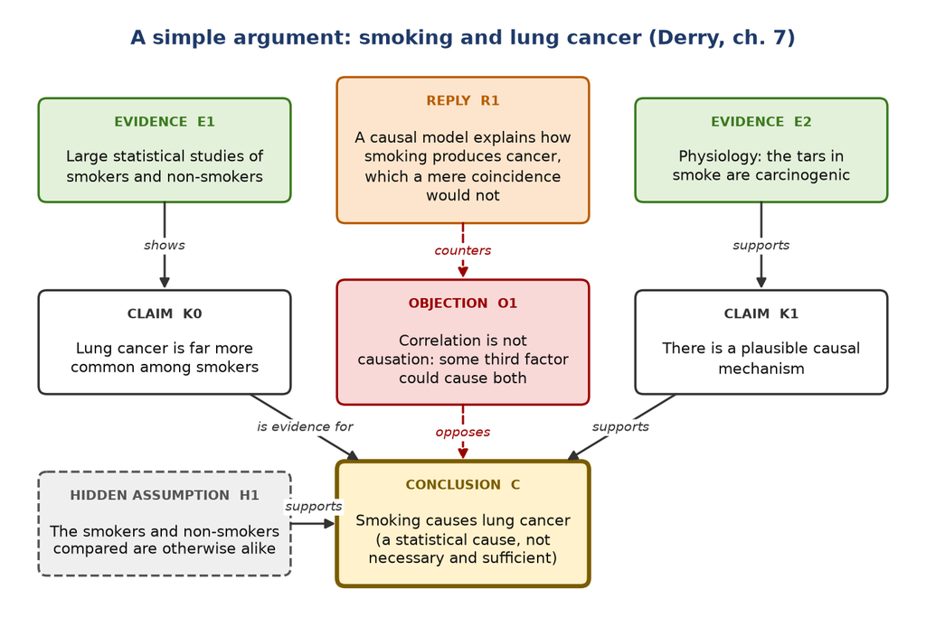

Note*Box key: blue = assumption, dashed grey = hidden assumption, green = evidence, white = claim, red = objection, orange = reply, yellow = conclusion. Dashed red arrows oppose or counter.*

The diagram makes the structure visible: two independent lines of support (statistics and a causal model), a hidden assumption that the groups were comparable, and the standard objection with its reply. It is illustrative, not proof; each box still has to be checked.

### Lists and concept recall6

U8-R01Recall

Explain this topic from the assigned readings: reason as mentally fitting things together. Give an example or explain its significance in this unit.

Source Reason as fitting together (Discussion 8.1)

1. **Fitting together.** Discussion 8.1 starts from etymology: "reason" and "ratio" both derive from the proto-Indo-European root *ar*, "to fit together." Since we think of reason as a mental process, this gives "a working understanding of reasoning as a mental process of fitting together" (Discussion 8.1). Everyday speech agrees: to a reasonable idea we reply, "yes, that fits."

2. **Logic.** "Logic" comes from the root *leg*, "to collect," or "to speak." Logic therefore studies how things may be fitted together and spoken about: speaking roughly, it is "the study of the ways in which a collection of things may be fitted together and spoken about" (Discussion 8.1). The root of "discriminate", *skeri*, "to cut or separate, to sift," is close to *skei*, a root of "consciousness" and "science".

3. **Distinguish, then fit.** Fitting together needs distinction first. To know how a watch works we must know what the pieces are and how they fit together, and more generally "we must distinguish something from its environment before we can understand how it fits into its environment" (Discussion 8.1). Identifying components and fitting them together is the difference between analysis and synthesis, deduction and induction, and the top-down and bottom-up approaches of Unit 9.

4. **Three sorts of reason.** Reasoning is often pictured as cold calculation, but Discussion 8.1 names three sorts of reason, all ways of fitting things together:

| Sort of reason | How it fits things together | Course example |
| --- | --- | --- |
| **Empathetical** | Placing ourselves into another point of view, "not simply from an analytical or analogical standpoint, but experientially"; it is what "gives us the real feeling of a fit" | To understand a person we must walk a mile in their shoes; good taste, the sense that a design feels "right and fitting" (taste is metaphorically a form of empathy) |
| **Analogical** | Fitting things together by likeness or metaphor | *Homo* (Latin for man, root *dhghen*, "earth") *sapiens* (Latin for wisdom, root *sap*, "taste, perception"): a human is a being of the Earth who has "tasted" the world and so become perceptive |
| **Analytical** | "cold calculation based on an analysis of a situation and its possibilities": distinguishing components and their logical relations | Analysis and deduction, with formal logic as the tool |

5. **Scholastic reasoning.** The etymological reasoning of Discussion 8.1 itself is not scientific reasoning but "scholastic reasoning": inference from dictionary definitions by the rules of analogy and the Aristotelian syllogism. It may sometimes be used in science, but "it is an error to assume that scientific reasoning is only an elaboration of scholastic reasoning" (Discussion 8.1); it is not the same thing.

6. **Example.** Reason fits things together at every level: sensations are fitted together into perceptions, perceptions in thinking, and thoughts in judgements and decisions on action. In a primitive and dangerous environment, "if our action is in bad taste ... then we may end up as a tasty morsel in some predator's diet" (Discussion 8.1). We survive not by brute strength, speed or camouflage but by learning from experience and judging what fits, so reason is "our main tool for survival".

7. **Significance.** Unit 8 widens reason beyond formal logic: formal logic "is a tool of reason, it is not the same thing as reason, any more than a hammer is the same thing as carpentry" (Unit 8 Overview). Unit 9 adds a limit: empathy and analogy serve personal understanding and the communication of science, but "only analytic reason can be used in support of a scientific truth claim" (Unit 9 Overview), so a hypothesis that "feels right" still needs analytic and empirical demonstration.

U8-R02Recall

Explain this topic from the assigned readings: the seven gestalt criteria for a good fit. Give an example or explain its significance in this unit.

Source Seven gestalt criteria for a good fit (Discussion 8.1)

1. **Origin.** If reasoning is fitting together, we need a way to tell a good fit. In the early 20th century gestalt psychologists set out criteria for a "good form" in the visual field; Discussion 8.1 adapts them to scientific hypotheses, because they also apply to "good forms" in theoretical systems of ideas. They are not fixed rules, merely "rules of thumb" (Discussion 8.1).

2. **The seven criteria.** Each says which hypothesis or argument to prefer:

| Criterion | What to prefer |
| --- | --- |
| 1. **Regularity** | A hypothesis that extends already existing and accepted ideas, over one that needs radical changes in them |
| 2. **Symmetry** | A hypothesis symmetrically related to accepted ideas, for example an idea successful in one field of science carried into another field by analogy |
| 3. **Harmony** | A hypothesis that is in harmony with, or resonates with, accepted ideas; and an argument whose structure is harmonious with existing patterns of reasoning |
| 4. **Simplicity** | The simpler hypothesis or argument |
| 5. **Conciseness** | The more concise hypothesis or argument |
| 6. **Inclusiveness** | The hypothesis that explains the most; it seems to oppose simplicity and conciseness, but often the simplest, most concise theory is also the most inclusive (Newton, Darwin) |
| 7. **Unity** | Seek theories that give a sense of closure, a unified understanding of a field of phenomena, as the goal of science |

3. **Occam's razor.** Simplicity and conciseness reflect Occam's razor, the philosophical injunction that "entities are not to be multiplied unnecessarily" (Discussion 8.1).

4. **Trade-offs.** The first six hold only "all other things being equal," and in practice they pull against each other: a hypothesis that is not a regular extension of existing theory may be more inclusive, or the simplest hypothesis may not be in harmony with existing theory. Trade-offs need aesthetic sensitivity: finding a good fit is "more a matter of aesthetic sensitivity than of applying fixed rules," and "harmony" and "art" share the proto-Indo-European root of "reason" (Discussion 8.1).

5. **Example.** Newton's law of universal gravitation is simple and concise yet inclusive: from his three laws of motion and his gravitational force equation it explained the motion of the planets, the behaviour of falling bodies and the tides. Darwin's theory explains "the vast diversity of life on earth" with the simple and concise ideas of variation and natural selection. Discussion 8.1 calls this agreement of simplicity with inclusiveness one of the remarkable things about science.

6. **Significance.** These are the "general non-analytic criteria for evaluating reasons" of Unit 8 (Unit 8 Overview): when evidence cannot yet decide, they guide which hypothesis to prefer and pursue. They are rules of thumb, not proof; acceptance of a hypothesis as scientifically valid still depends on analytic and empirical demonstration (Unit 9 Overview).

U8-R03Recall

Explain this topic from the assigned readings: the three decision heuristics and their cognitive illusions. Give an example or explain its significance in this unit.

Source Three decision heuristics and their illusions (Discussion 8.2)

1. **Rules of thumb.** Until the early 1960s psychologists believed that people mostly made rational decisions, with mistakes due to ignorance, emotional interference or faulty data. Research since then shows that we form confident opinions on insufficient, often biased data, hold them against strong contrary evidence, imagine connections between events and overlook important details; such effects are "cognitive illusions" (Discussion 8.2). Three general heuristics, or rules of thumb, are the basis of most decisions and judgements.

2. **The three heuristics.** Representativeness, availability and anchoring each save the mind effort, and each produces its own illusions (Discussion 8.2):

[output not shown]

3. **Mill and attribution.** John Stuart Mill called the "most deeply-rooted, perhaps" fallacy of causal reasoning the prejudice that "the conditions of a phenomenon must, or at least probably will, resemble the phenomenon itself": great events must have great causes, complex events complex causes. The fundamental attribution error is assuming that a person's behaviour shows their personality rather than the context in which we observe them, though we explain our own behaviour by the situation (Discussion 8.2).

4. **Why anchors hold.** Without an interpretive framework we lose the comfortable feeling of understanding, so we hold on tightly, and a false belief costs little because a belief "does not need to be true to fact to be useful" (Discussion 8.2). Aristotle noted that the ability to doubt is rare; people believe what they hear first and question it later, which advertisers exploit. In psychological terms anchoring favours assimilation of events to an existing belief over accommodation of beliefs to new evidence.

5. **Example.** At a red light many drivers think, "Why do I always hit the red lights?" Over the long run red and green lights balance out, but a green light is passed without effort while a red light means an extra effort to stop and a slight irritation, so memory keeps more red lights (availability). Likewise a few coincidences with a horoscope give it causal power, while the many misses are not seen as contrary evidence (anchoring).

6. **Significance.** The heuristics are not irrational: reason is fitting together, and that is what they do, so they "are essential for science" (Discussion 8.2). Science is the development of tools for using them accurately, not replacing them: "a process of developing tools for the accurate application of these heuristics, rather than their replacement by something new." Formal logic and classification serve representativeness, repeatable observation and unbiased statistical methods serve availability, and research into theories, paradigms and conceptual frameworks shows the value and limits of anchors. As Thomas H. Huxley said, scientific thought is our everyday thinking made more precise, and like a gymnast's skill the precision takes long training.

U8-R04Recall

Explain this topic from the assigned readings: the essentials of Derry's Chapter 7, the two foundations of a scientific argument, deductive reasoning and inductive reasoning, and the contributions of science to critical thinking. Give an example or explain its significance in this unit.

Source Derry ch. 7 essentials

1. **Two foundations.** A well-constructed "scientific argument, defending a scientific conclusion, generally rests upon two foundations: reliable empirical evidence and sound logical reasoning" (Derry, p. 89). Shoddy arguments exist in science too, but they do not withstand the test of time: "The point isn't that we always have proper evidence and reasoning in the sciences, the point is that we always should have these things" (Derry, p. 89).

2. **Deduction.** "The purpose of deductive logic is to find relationships between statements (called premises and conclusions) that guarantee the truth of the conclusions if the premises are true" (Derry, p. 90). Its central form is the syllogism, two premises and a conclusion: all cats are cute (major premise); Smokey is a cat (minor premise); therefore Smokey is cute (conclusion). With no conditional propositions it is a categorical syllogism. The logic can be reversed: if the conclusion is false, at least one premise is false; but a true conclusion says nothing about the premises, and false premises say nothing about the conclusion (Derry, pp. 91-92). Deduction gives certainty, but "we seldom have any well-defined general premises that we know are true" (Derry, p. 92).

3. **Induction.** Inductive logic uses "the truth of many particular statements to make a generalization" (Derry, p. 92): every cat I've seen is cute, so all cats are cute. Generalizing from many particular cases is almost unavoidable but never certain: "I might run into an ugly cat tomorrow." Judge it by the evidence behind it: a generalization from one or two examples is "basically worthless", one from thousands of well-controlled, documented cases can be accepted provisionally (Derry, p. 92).

4. **Evidence.** Deduction needs true premises and induction needs reliable particular cases, so an argument rests as much on its evidence as on its logic. Ask for documentation and the reliability of the source, and test plausibility: internal contradictions, conflicts with common sense or known facts, numerical estimates that make no sense (Derry, pp. 92-93).

5. **Contributions of science.** Derry's §2 lists modes of thinking that science offers critical thinking (Derry ch. 7):

[output not shown]

6. **Example.** A car needs engine repairs, then a new muffler, a new battery and new tires. Each problem did not cause the next; the likelier explanation is that the car is old, so "C causes both A and B" (Derry, p. 97). In the same way, a claimed link between correlated trends may hide a common cause, several causes, a feedback loop or mere coincidence.

7. **Significance.** Critical thinking is "the use of specific tools and strategies of thought to come to clear conclusions on whether to accept or reject claims that are made, and to determine the degree of reliability of our conclusions" (Unit 8 Overview). Science is a model for it because it is one of the few endeavours that can start from a general premise, deduce its results and compare them with evidence of very high quality (Derry, p. 93). The methods extend beyond science: "Differing values are no excuse for bad logic and lack of evidence" (Derry, p. 90).

U8-R05Recall

Explain this topic from the assigned readings: the three general categories of fallacies. Give an example or explain its significance in this unit.

Source Three categories of fallacies (Derry ch. 7 §3)

1. **Bad arguments.** For Derry an argument is bad when its conclusion is untrustworthy, "as opposed to being invalid in a formal sense"; logicians call this "material" validity (Derry, p. 98). An argument can be bad through flawed logic, through false premises (the formally valid "All cows are reptiles" syllogism), through statements too ambiguous to mean anything, or through rhetorical devices that convince without valid logic or evidence. Derry sorts the common fallacies into three categories (Derry ch. 7):

[output not shown]

2. **Distribution.** A term is distributed when a statement is about every member of its class: in "all cats are cute" the term "cats" is distributed and "cute" is not. The middle term must be distributed in at least one premise. Mr. Jones joined the FOPL and the FOPL is a Communist front, but that premise only means "some members of the FOPL are Communists," so nothing follows about Mr. Jones (Derry, p. 100). The rule behind it: "You can't draw a conclusion that is stronger than the premises on which the conclusion is based" (Derry, p. 101).

3. **Causal fallacy.** Post hoc, ergo propter hoc, "after this, therefore because of this," assumes that the earlier of two events caused the later. The inflation that followed Jimmy Carter's election had more plausible causes: years of high military and domestic spending and oil cartels driving up energy prices (Derry, p. 96).

4. **Example.** A party boasts of a 1.2 percent "increase" for a popular program, but with inflation at 4.5 percent this "represents a substantial cut" (Derry, p. 103). Recomputed: the program keeps 1.012 / 1.045 = 0.968 of its purchasing power, a real cut of about 3.2 percent. The numbers are accurate; the comparison misleads.

5. **Significance.** The categories mirror the two foundations of a scientific argument: invalid logic fails sound reasoning, invalid evidence fails reliable evidence, and rhetoric replaces both with persuasion. Spotting invalid logic is enough to reject an argument without weighing its premises (Derry, p. 91). Fallacies are hard to see because style disguises structure, but "all these difficulties can be overcome to some extent by critically evaluating the arguments we encounter" (Derry, p. 105).

U8-R06Recall

Explain this topic from the assigned readings: diagramming an argument, the steps for building an argument diagram. Give an example or explain its significance in this unit.

Source Diagramming an argument (Discussion 8.3)

1. **What it is.** "Argument analysis is not something distinct from critical thinking", but it uses a technique of diagramming arguments that helps us apply the critical tools (Discussion 8.3). A diagram lays bare the structure of an argument: "We have, as it were, carved it at the joints." It shows where the argument, and the links between its parts, can be criticized.

2. **Six steps.** There are no firmly established rules for diagramming arguments, but Discussion 8.3 suggests these:

[output not shown]

3. **Example.** Figure 8.3.1 diagrams the argument that Azande witchcraft is equivalent to science. Conclusion: the two are equivalent explanatory systems. Major assumptions: a definition of science, and the claim that both systems are culturally closed ("incommensurable"), so neither accepts arguments valid in the other and their merits cannot be judged objectively. Witchcraft is said to meet the definition: it explains the world, is internally consistent, has great generality and uses an experimental method. The diagram shows where to attack: the definition leaves out the inductive attitude, the experimental-method claim can be challenged, and the closure claim ignores the in principle open nature of science (Discussion 8.3).

4. **Second example.** For giving creationism equal time with evolution, the pro side's basic assumptions are that an activity is scientific if it searches for evidence for a theory, criticizes competing theories and explains some aspect of nature; that a conspiracy of secular humanists imposes evolution; and that scientific theories ought to make exact experimental predictions. Its evidence is disputes among biologists and gaps in the fossil record, and its hidden assumption is that all scientific theories deserve equal time (Figure 8.3.3).

5. **Limits.** In ongoing disputes a complete diagram may be impossible because not all the evidence is in: the failure to observe stellar parallax counted against Copernican theory until 19th-century instruments could detect it. A diagram is an aid to critical thinking, not a substitute: "Of themselves, they cannot provide support for or against any argument or conclusion; their function is illustrative rather than normative" (Discussion 8.3).

6. **Significance.** Diagramming simple arguments is a Unit 8 objective (Unit 8 Overview), and the study questions apply it to the con side of the creationism debate and to John Snow's argument about cholera (Unit 8 Study Questions). Putting an argument and its counter-argument in one diagram, as Figure 8.3.2 does for the Azande case, shows where the main issues lie (the inductive attitude, what counts as an experimental method) and where each side must develop its case further.

### Key term questions12

U8-T01Term

Define or distinguish Heuristic. Give an example and explain its role in this unit.

1. **Definition.** A heuristic is a rule of thumb: a quick, automatic shortcut the mind uses to make judgements and decisions without full analysis.

2. **Role in this unit.** Discussion 8.2 identifies three, representativeness, availability and anchoring, as the basis of most judgements, and shows that they also produce cognitive illusions.

3. **Example.** Availability: judging how common an event is by how easily examples come to mind ("Why do I always hit the red lights?").

4. **Distinction.** A heuristic is not a fallacy or a mistake in itself; it is a useful strategy that becomes an error when used uncritically. Discussion 8.1 also calls the gestalt criteria "rules of thumb," not fixed rules.

5. **Significance.** The heuristics are essential for science, which develops tools to apply them accurately rather than replacing them.

U8-T02Term

Define or distinguish Cognitive illusion. Give an example and explain its role in this unit.

1. **Definition.** A cognitive illusion is a systematic error in judgement or reasoning that feels correct to the person making it, the thinking counterpart of an optical illusion.

2. **Role in this unit.** Discussion 8.2 shows that we form confident opinions from insufficient, biased data, hold them against strong contrary evidence, imagine connections between events and overlook important details; these effects come from the three decision heuristics.

3. **Example.** The traffic light phenomenon: we "always" hit red lights because stopping is effortful and irritating, so red lights are remembered better (availability).

4. **Distinction.** An optical illusion fools perception; a cognitive illusion fools judgement, and is harder to notice because "we are in charge of our own thought."

5. **Significance.** Many scientific tools, such as statistics, random samples and controlled experiments, exist to correct cognitive illusions, which is why they can seem counter-intuitive.

U8-T03Term

Define or distinguish Fundamental attribution error. Give an example and explain its role in this unit.

1. **Definition.** The tendency to explain another person's behaviour by their personality while explaining our own behaviour by the situation (Discussion 8.2).

2. **Role in this unit.** It is one of the cognitive illusions of the representativeness heuristic: one observed act is taken as representative of a stable character.

3. **Example.** A classmate who arrives late is "lazy," but when I arrive late it is because of traffic.

4. **Distinction.** It differs from Mill's fallacy (causes resemble effects), which is about events, and from post hoc reasoning, which is about time order; this error is about persons versus circumstances.

5. **Correction.** Look at the context and at the person's behaviour on other occasions, and judge others by the standard used for oneself.

U8-T04Term

Define or distinguish Assimilation versus accommodation. Give an example and explain its role in this unit.

1. **Definition.** *Assimilation* means fitting a new event into an existing belief; *accommodation* means changing the belief to fit new evidence (Discussion 8.2, footnote 164).

2. **Role in this unit.** Anchoring biases us toward assimilation: we treat new experiences "as instances of our beliefs rather than as evidence that might test those beliefs," the language of Discussion 5.2.

3. **Example.** The man who calls a poorly driving man someone who "drives just like a woman" assimilates the case to his anchor instead of accommodating his belief about women drivers.

4. **Distinction.** Both are needed: assimilation lets a framework organize experience; accommodation lets it learn. A scientific framework is used by assimilation but must remain open to accommodation.

5. **Significance.** Science is an open system because it institutionalizes accommodation (testing, organized skepticism); Mendeleev's correction of atomic weights shows a framework used to assimilate data while making testable predictions.

U8-T05Term

Define or distinguish Syllogism. Give an example and explain its role in this unit.

1. **Definition.** A syllogism is a form of deductive argument with two premises (major and minor) and a conclusion; in a valid syllogism the truth of the premises guarantees the truth of the conclusion (Derry ch. 7).

2. **Role in this unit.** It is the central tool of the older verbal logic going back to Aristotle, which Derry uses to separate the logic of an argument from the truth of its premises.

3. **Example.** All cats are cute (major premise); Smokey is a cat (minor premise); therefore Smokey is cute (conclusion).

4. **Distinction.** A *categorical* syllogism contains no conditional propositions; premises may be general, particular or conditional. Validity concerns form; the flying-cows syllogism is valid with every statement false.

5. **Use.** Once the syllogistic form is isolated, invalid logic (such as an undistributed middle) can be spotted without judging the premises at all; and if a valid syllogism's conclusion is false, at least one premise must be false.

U8-T06Term

Define or distinguish Conditional / hypothetical proposition. Give an example and explain its role in this unit.

1. **Definition.** A conditional proposition states something about the truth of statements taken together. One type pairs statements ("either 1+1=2 or my understanding of arithmetic is wrong"); the *hypothetical* type takes the "if . . . then" form ("if the Orioles win one more game, then they will be in the playoffs") (Derry ch. 7).

2. **Role in this unit.** Conditional propositions can be premises of a syllogism, and the commonest invalid-logic fallacies misuse them.

3. **Example of misuse.** Assuming the converse: "If taxes are too high, productivity is low; productivity is low; so taxes are too high."

4. **Distinction.** "If A then B" does not imply "if B then A" (the converse) or "if not A then not B" (the inverse).

5. **Significance for science.** Hypotheses are tested through conditionals: "if the theory is true, then we should observe X." Observing X supports the theory but does not prove it (that would be assuming the converse), while failing to observe X counts against it.

U8-T07Term

Define or distinguish Distribution. Give an example and explain its role in this unit.

1. **Definition.** A term is *distributed* when a statement says something about every member of the class it names (Derry ch. 7).

2. **Example.** In "all cats are cute," "cats" is distributed (every cat is covered) but "cute" is not (nothing is said about all cute things).

3. **The rule.** The middle term of a syllogism, the one appearing in both premises, must be distributed in at least one premise; otherwise no valid conclusion follows.

4. **The fallacy.** "All cats are cute; all dogs are cute; therefore all cats are dogs" commits the undistributed middle. Derry's real-world case: Jones belongs to the FOPL; the FOPL is a Communist front (really: *some* members are Communists); so Jones is a Communist.

5. **Significance.** Derry sums up the rules of distribution as "You can't draw a conclusion that is stronger than the premises on which the conclusion is based," a rule that applies equally to scientific generalizations.

U8-T08Term

Define or distinguish Enthymeme. Give an example and explain its role in this unit.

1. **Definition.** An enthymeme is a syllogism with an unstated but clearly implied premise (Derry ch. 7).

2. **Example.** "Sacco is evil because he is an anarchist" hides the major premise "all anarchists are evil," and states the conclusion first.

3. **Role in this unit.** It is the formal name for the commonest kind of hidden assumption, which Derry and Discussion 8.3 say must be made explicit before an argument can be evaluated.

4. **Distinction.** An enthymeme is not necessarily invalid; once the missing premise is supplied the logic may be fine. The danger is that the missing premise, the weakest part, escapes scrutiny.

5. **Use.** In diagramming, the supplied premise goes in a hidden-assumption box, as with "all scientific theories deserve equal time" in the creationism argument (Figure 8.3.3).

U8-T09Term

Define or distinguish Material validity. Give an example and explain its role in this unit.

1. **Definition.** Material validity concerns whether an argument's conclusion is trustworthy, as opposed to formal validity, which concerns only whether the conclusion follows from the premises (Derry ch. 7 §3).

2. **Role in this unit.** Derry defines a bad argument as one with an untrustworthy conclusion, that is, materially invalid; it can fail through invalid logic, false premises, meaningless ambiguity or rhetorical tricks.

3. **Example.** "All cows are reptiles; all reptiles can fly; therefore all cows can fly" is formally valid but materially invalid, since every statement is false.

4. **Distinction.** Formal validity is about structure alone; material validity needs both foundations, sound reasoning and reliable evidence.

5. **Significance.** Scientific conclusions must be materially valid: a valid deduction from an untested premise proves nothing about the world.

U8-T10Term

Define or distinguish Post hoc, ergo propter hoc. Give an example and explain its role in this unit.

1. **Definition.** Latin for "after this, therefore because of this": the fallacy of assuming that because one event followed another, the first caused the second (Derry ch. 7).

2. **Example.** Inflation followed Jimmy Carter's election, so his policies were blamed, although earlier military and domestic spending and oil-cartel price rises were more plausible causes.

3. **Role in this unit.** It is the commonest error in evaluating causality, a form of the built-in bias to see causes in sequences and covariation (Discussion 8.2).

4. **Distinction.** Time order is necessary for causation (a cause comes before its effect) but not sufficient; alternatives include a common cause, coincidence and other changes at the same time. It differs from the converse, which is an error of form rather than of time.

5. **Correction.** Compare with a group that did not get the supposed cause over the same period, and look for a causal model.

U8-T11Term

Define or distinguish Necessary and sufficient condition. Give an example and explain its role in this unit.

1. **Definitions.** A *necessary* condition must be present for the effect to occur; a *sufficient* condition always produces the effect when present (Derry ch. 7).

2. **Role in this unit.** To demonstrate a causal link rigorously we must show the cause is both necessary and sufficient, which science can sometimes do with carefully controlled experiments.

3. **Example.** Oxygen is necessary for a fire but not sufficient (fuel and heat are also needed); a fatal dose of a poison is sufficient for death but not necessary, since there are other causes of death.

4. **Distinction.** In everyday and medical use, "cause" often means a partial cause that is neither necessary nor sufficient, such as smoking for lung cancer; such claims need statistical inference from large random samples.

5. **Significance.** The distinction explains why biomedical studies can be highly suggestive yet unable to prove causality, and why one-time historical events can only be given a probable, not rigorous, causal account.

U8-T12Term

Define or distinguish Straw man, ad hominem, false dilemma, begging the question, slippery slope. Give an example and explain its role in this unit.

1. **Straw man:** attacking a distorted version of an opponent's position, weaker or more extreme than the real one, instead of the real position. *Example:* replying to "we should reduce car traffic downtown" as if it said "ban all cars."

2. **Ad hominem** ("to the man"): attacking the person instead of the argument. *Example:* opposing Senator Krupt's campaign-finance reform by pointing out his own sleazy fundraising, "possibly true, but definitely irrelevant."

3. **False dilemma:** offering only two options, attacking the weaker and concluding the other must be right. *Example:* "either good jobs or a livable environment."

4. **Begging the question** (circular reasoning): assuming the conclusion in the premises. *Example:* "The government spends too much of our money. Therefore, we need to cut back on government spending."

5. **Slippery slope:** claiming without good evidence that a step will inevitably lead to a terrible result, then arguing against the result. *Example:* "If we allow any logging in this old growth forest, we'll soon be clearcutting the entire area"; the Vietnam-era domino theory.

**Role and distinction.** All five belong to Derry's third category, rhetoric and fallacy: they persuade without valid logic or evidence. They differ in their target: the opponent's position (straw man), the person (ad hominem), the range of options (false dilemma), the premises (begging the question) or the consequences (slippery slope).

### Applied written questions16

U8-A01Applied5 marks

A news story repeats the same claim daily. Explain how availability can increase apparent credibility and describe two checks that could reduce this effect.

Source Discussion 8.2

1. **How availability works here:** we judge how likely or common something is by how easily it comes to mind (Discussion 8.2). A claim repeated daily becomes highly available, so it feels familiar, and familiarity is mistaken for frequency and truth: "What I tell you three times is true" (Lewis Carroll, the Discussion 8.2 epigraph).

2. **Why repetition adds no evidence:** repeating one claim does not add independent observations; ten reports of the same source are one piece of evidence, not ten. Anchoring adds to the effect, since people tend to believe what they hear first and question it only later.

3. **Check 1, the source:** ask where the claim comes from, whether it is documented, and whether the source could actually know the fact (Derry ch. 7, evaluating evidence). Many repetitions often trace back to one unverified origin.

4. **Check 2, independent comparison:** look for independent sources and for base rates or counts: how often the thing really happens, compared with a relevant measure, rather than how often it is mentioned (probabilistic and quantitative thinking).

5. **Result:** the claim is accepted only tentatively and in proportion to the independent evidence, not to how familiar it has become.

U8-A02Applied5 marks

A researcher keeps adjusting a new result to fit a favourite theory. Explain anchoring in the course sense and distinguish productive use of a framework from resistance to contrary evidence.

Source Discussions 8.2 and 8.3

1. **Anchoring in the course sense:** quickly selecting an interpretation or theory and keeping it "even in the face of strong contrary evidence," with minor modifications or ad hoc explanations for cases that do not fit (Discussion 8.2).

2. **The case:** adjusting each new result until it fits the favourite theory is assimilation of the evidence to the belief instead of accommodation of the belief to the evidence (footnote 164); the man with the "woman driver" joke does the same.

3. **Productive use of a framework:** every scientist needs an anchor; without one there is no way to interpret data, and science depends on conceptual frameworks. A productive framework makes risky predictions, states in advance what would count against it, and changes when the evidence requires: Mendeleev changed accepted atomic weights to fit his table, but as testable predictions that measurements later confirmed (Derry ch. 2).

4. **Resistance to contrary evidence:** the adjustments are made after the event, are not independently testable, and could be made for any result, so nothing could ever count against the theory; in Discussion 5.2's language, data become instances of the belief, not evidence that tests it.

5. **Safeguards:** state the test and the criteria before seeing the result, report all results, and submit the work to colleagues' organized skepticism; a diagram of the argument (Discussion 8.3) shows whether each adjustment has its own support.

U8-A03Applied5 marks

A quiet person who enjoys books is classified as a librarian without considering how common different occupations are. Identify the heuristic and the missing information.

Source Discussion 8.2

1. **Heuristic:** **representativeness**: a few features, quiet and fond of books, are taken as characteristic of a librarian, and the person is matched to the stereotype (Discussion 8.2).

2. **Missing information:** how common the different occupations are (the base rate). Far more people work in sales, offices or trades than as librarians, so even if quiet book lovers are more common among librarians, most quiet book lovers are probably not librarians.

3. **Also missing:** how common the features are in each occupation; quietness and reading are widespread, so they do little to separate the groups.

4. **Why the error happens:** we choose "vivid, striking features even if they are highly unrepresentative," and treat a stereotype as a fair sample of the group.

5. **Better reasoning:** start from the proportions of each occupation, adjust by how much more likely the features are in each, and look for other evidence about the person (probabilistic thinking, Derry ch. 7).

U8-A04Applied10 marks

Explain how representativeness, availability and anchoring can each help a scientist form a useful conjecture while also producing a cognitive illusion. Use three different examples.

Source Discussion 8.2

**Representativeness**

1. *Useful conjecture:* treating a few striking features as typical lets a scientist form categories and guess at relations. Mendeleev grouped elements by recurring properties and atomic weight, and the pattern let him predict gallium and germanium (Derry ch. 2).

2. *Illusion:* the same heuristic leads to expecting causes to resemble effects (Mill's fallacy) or to generalizing from a small, vivid sample, as when a few dramatic cases are taken to show what a whole population is like.

3. *Correction:* significant classification criteria tested by observation, and large random samples.

**Availability**

4. *Useful conjecture:* the possible causes that come to mind first are a quick starting list. Snow, knowing that diseases could spread through what people swallow, suspected the water supply and could test that idea directly (Discussion 3.4).

5. *Illusion:* what is easily recalled may reflect vividness, not frequency: the traffic light phenomenon, or remembering the one dramatic result that confirmed a hunch and forgetting the dull ones that did not. A list of possible causes drawn from memory may have been "pre-selected for us by hidden biases."

6. *Correction:* systematic records, repeatable observation and statistics that count every case.

**Anchoring**

7. *Useful conjecture:* holding a framework long enough to work it out is essential. Wegener kept faith in drift through decades of criticism, and the theory was vindicated by sea-floor spreading and paleomagnetism (Derry ch. 2).

8. *Illusion:* the same persistence can protect a false idea with ad hoc patches, as with the opponents of drift, who kept their land bridges and dismissed Wegener's evidence because his mechanism was wrong, or with astrology's remembered hits.

9. *Correction:* stating in advance what would count against the theory, and organized skepticism by other scientists.

10. **Conclusion:** the heuristics generate conjectures quickly, which science needs; they turn into illusions when the conjecture is not tested. Science, in Discussion 8.2's words, develops "tools for the accurate application of these heuristics, rather than their replacement."

U8-A05Applied5 marks

A student explains a classmate's late arrival by laziness but explains their own late arrival by traffic. Analyse the attribution error and propose a fair comparison.

Source Discussion 8.2

1. **The error:** the **fundamental attribution error**: the classmate's lateness is put down to character (laziness), the student's own lateness to the situation (traffic), even though the evidence for each is the same, one late arrival (Discussion 8.2).

2. **Source:** representativeness: one observed act is taken as representative of a stable trait, while the circumstances of the other person are invisible to us and our own circumstances are vivid.

3. **The double standard:** the student has information about the traffic in their own case but none in the classmate's; lack of information is treated as evidence of a character flaw.

4. **A fair comparison:** apply the same standard to both: ask about the classmate's circumstances that morning, and compare how often each of them is late across many days, under similar conditions.

5. **Conclusion:** only a repeated pattern, not explained by circumstances that apply to everyone, would justify a judgement about character; one case supports neither conclusion.

U8-A06Applied5 marks

An advertisement says that a product works because it is popular. Separate evidence of popularity from evidence of effectiveness, identify a hidden assumption, and propose a test.

Source Discussion 8.3; Derry Chapter 7

1. **Popularity versus effectiveness:** popularity is evidence about how many people buy or like the product; effectiveness is a claim about what the product does. The advertisement treats evidence for the first as evidence for the second.

2. **Hidden assumption:** "if many people use a product, it must work" (or "buyers can tell whether a product works"). As an enthymeme, the missing premise carries the whole argument (Derry ch. 7).

3. **Why the assumption is weak:** people may buy because of advertising, price or habit; they may credit the product for improvements that would have happened anyway (post hoc) or through placebo; and dissatisfied users are not counted (suppressed evidence). Many popular remedies of the past did nothing.

4. **A test:** a controlled comparison: randomly assign people to the product or to an identical-looking placebo (or to a rival product), without telling them which they have, and measure an outcome defined in advance.

5. **Judging the result:** only a clear difference in a large enough random sample would show effectiveness; popularity would remain irrelevant to that question.

U8-A07Applied5 marks

An argument states that all effective filters remove particles, this device removes particles, therefore it is effective. Identify the logical error and give a counterexample with the same form.

Source Derry Chapter 7

1. **Logical form:** All effective filters remove particles (all A are B). This device removes particles (this is a B). Therefore it is effective (it is an A).

2. **The error:** **assuming the converse**, or in terms of distribution an **undistributed middle**: "removes particles" (the middle term) is not distributed in either premise; the first premise says something about all effective filters, not about all particle-removers (Derry ch. 7).

3. **Why it fails:** a device can remove particles and still be ineffective, for example by removing only large particles, or by letting harmful gases or microbes through.

4. **Counterexample with the same form:** "All dimes are coins; this nickel is a coin; therefore this nickel is a dime." The premises are true and the conclusion is false, which proves the form invalid.

5. **Repair:** the conclusion would need a premise distributing the middle term, "everything that removes particles is an effective filter," which is false, or direct evidence of effectiveness from a test against a defined standard.

U8-A08Applied5 marks

An argument concludes that an intervention caused an improvement because the improvement followed it. Give three alternative explanations and describe a useful comparison.

Source Derry Chapter 7

1. **The error:** concluding that the intervention caused the improvement because the improvement followed it is **post hoc, ergo propter hoc** (Derry ch. 7).

2. **Alternative 1, natural change:** the problem may have improved on its own (recovery over time, or a rebound from an unusually bad starting point).

3. **Alternative 2, another change at the same time:** a different factor (new staff, a policy change, the season) may have caused the improvement, or a common cause produced both the decision to intervene and the improvement.

4. **Alternative 3, measurement, expectation or chance:** the way improvement was measured may have changed; people who know they are being helped may report or perform better (a placebo-type effect); or the change is within normal random variation, especially in a small sample.

5. **A useful comparison:** a control group like the treated group in every other way, ideally chosen at random, measured over the same period with the same method; if only the treated group improves, the alternatives become unlikely, though the inference remains statistical.

U8-A09Applied5 marks

Construct a short argument with two independent reasons for one conclusion and another argument whose reasons must be combined. Diagram both and explain the difference.

Source Discussion 8.3

**A. Two independent reasons.** "Africa and South America were once joined, because their coastlines (continental shelves) match, and because the same fossils are found on both coasts." Each reason supports the conclusion on its own; if one were removed, the other would still give some support (Derry ch. 2, Wegener).

**B. Linked reasons.** "Smokey is cute, because all cats are cute and Smokey is a cat." Neither premise supports the conclusion alone: that all cats are cute says nothing about Smokey, and that Smokey is a cat says nothing about cuteness. Only together do they imply the conclusion (Derry's syllogism, ch. 7).

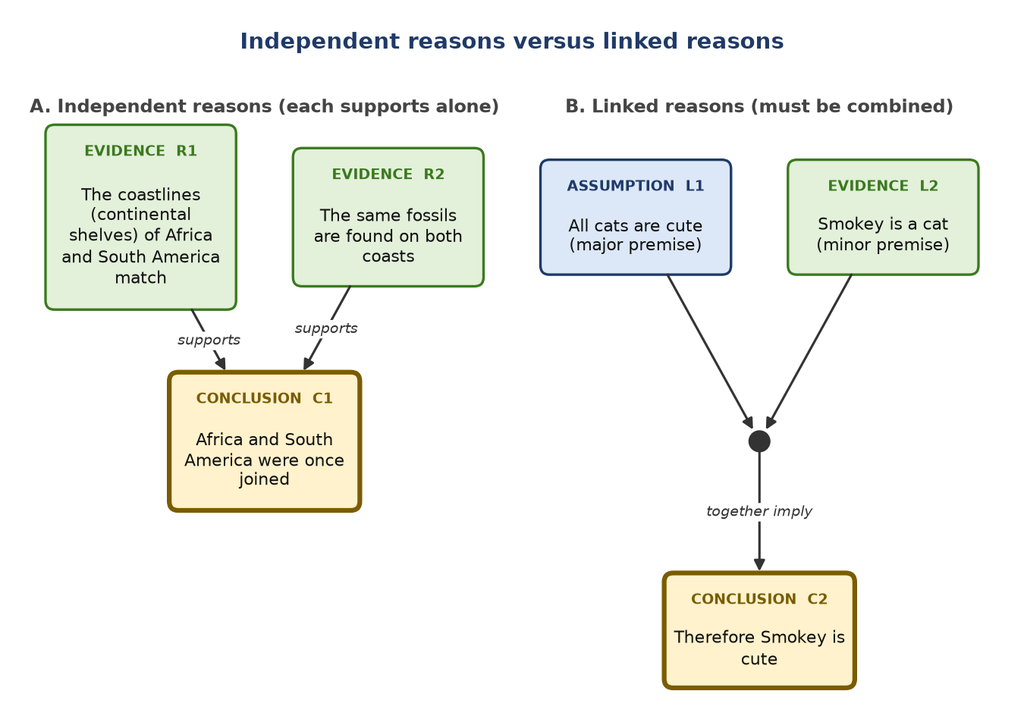

Note*In B the two arrows meet at a junction, the course's "combines with," and only the combination supports the conclusion.*

**The difference.**

1. Independent (convergent) reasons each carry their own arrow to the conclusion; their supports add up, and the argument survives the loss of one.

2. Linked reasons share one arrow from their junction; if either premise is false, that support collapses entirely.

3. This changes how to criticize the argument: against independent reasons every one must be answered, while against linked reasons refuting a single premise is enough.

4. In Figure 8.3.3 the claims that creationism is scientific and that all scientific theories deserve equal time are linked ("combines with"), so the con side can defeat the pro conclusion by refuting either one.

U8-A10Applied5 marks

An argument moves from a factual claim about what people do to a claim about what they ought to do. Identify the missing evaluative premise and explain how to assess it.

Source Discussion 8.3; Derry Chapter 7

1. **The gap:** a factual claim about what people do ("most people eat meat") cannot by itself establish what they ought to do ("so eating meat is right"). An "ought" needs at least one premise that is itself about values.

2. **The missing evaluative premise:** "whatever most people do is what they ought to do," or a narrower version such as "a widespread practice is morally acceptable." The argument is an enthymeme, and this premise is its hidden assumption (Derry ch. 7; Discussion 8.3).

3. **Assessing the factual premise:** check it like any evidence: the source, the sample and the wording of any survey (Derry's warning on public-opinion statistics).

4. **Assessing the evaluative premise:** state it openly and test it against cases: many widespread practices (slavery, child labour) were wrong, so the general premise is false, and at most a weaker premise, such as "common practices deserve a hearing," survives. Derry says that when issues turn on values "we are obligated to isolate these differences and identify them clearly."

5. **Conclusion:** the argument can be repaired only by defending a value premise with reasons of its own; science can test the factual part but cannot by itself supply the "ought" (Unit 7's point, from Einstein, that science can ascertain only what is).

U8-A11Applied10 marks

Compare an invalid inference, unreliable evidence and a rhetorical fallacy using three original examples. Explain why repairing one weakness needs not repair the others.

Source Derry Chapter 7

**Invalid inference (Derry's first category, invalid logic)**

1. *Example:* "If a bridge design is safe, it passes the computer simulation; this design passed, so it is safe." The data are accurate, but the inference assumes the converse: the simulation may miss failure modes.

2. *Repair:* change the logic: state a valid form, or limit the conclusion ("it passed the simulation; further tests are needed").

**Unreliable evidence (second category, invalid evidence)**

3. *Example:* "In a survey of 20 people outside a gym, 18 said they exercise every day, so 90 percent of Canadians exercise daily." Generalizing from a sample can be reasonable, but this sample is small and non-random, like Derry's survey of Sierra Club members on environmental opinion.

4. *Repair:* gather better evidence: a random, larger survey, documented sources.

**Rhetorical fallacy (third category)**

5. *Example:* "We shouldn't listen to the new climate report; its lead author once failed his driving test." This is an ad hominem; it gives neither data nor inference about the report.

6. *Repair:* remove the attack and address the report's evidence and reasoning directly.

**Why repairing one does not repair the others**

7. Derry's two foundations, reliable evidence and sound reasoning, are independent: a valid argument can rest on false premises (the flying cows), and true data can be joined by invalid logic.

9. Arguments often combine weaknesses, so each must be checked separately: isolate the logical form first (if it is invalid, the premises do not matter), then evaluate the evidence, then strip the rhetoric.

10. A diagram helps, because it separates the evidence boxes from the inference arrows, but it does not decide either question; it only shows where each must be judged (Discussion 8.3).

U8-A12Applied10 marks

Use the seven course gestalt criteria to compare two explanations of one phenomenon. Show how a pleasing fit can guide inquiry without establishing empirical truth.

Source Discussion 8.1

**Phenomenon:** the yellowing of a houseplant's leaves. *Explanation X:* overwatering starves the roots of oxygen. *Explanation Y:* a combination of a mineral deficiency, a cold draft and an invisible pest.

1. **Regularity:** X extends accepted plant physiology; Y needs a new, unseen pest. X preferred.

2. **Symmetry:** X carries a known idea over by analogy (waterlogged crops yellow the same way). X preferred.

3. **Harmony:** X resonates with gardeners' experience; Y's parts are familiar but do not form one pattern.

4. **Simplicity:** one cause (X) against three (Y).

5. **Conciseness:** X fits in a sentence; Y needs a list.

6. **Inclusiveness:** if the new leaves also show yellowing between green veins, only Y's mineral deficiency explains that, so Y may be more inclusive.

7. **Unity:** X gives closure, one understanding of all the symptoms if they fit.

8. **How the fit guides inquiry:** X's better fit tells the gardener which explanation to test first and what to look at (soggy soil, root rot); Wegener's continental drift was likewise pursued because it fitted the jigsaw of coastlines and fossils so well.

9. **Why fit does not establish truth:** the criteria hold only "all other things being equal," are rules of thumb, and can conflict (point 6). Drift was rejected for decades because it failed regularity and harmony, yet it was true; the land bridges fitted accepted ideas and were false. A pleasing fit is an aesthetic judgement, not an observation.

10. **What does establish it:** testing predictions: let the soil dry and test it for minerals; whichever explanation's prediction fails is ruled out. Discussion 8.1 makes the fit a guide to inquiry; Derry ch. 7 makes reliable evidence and sound reasoning the foundation of acceptance.

U8-A13Applied5 marks

Explain how a theory can organize observations through analogy while requiring analytical and empirical support for its scientific acceptance.

Source Discussion 8.1

1. **Analogy organizes observations:** analogical reasoning fits things together by likeness (Discussion 8.1). A theory built on an analogy lets scattered observations be seen as one pattern, and the gestalt criterion of symmetry favours ideas carried from one field into another.

2. **Example:** Holmes's mantle convection (1928) explained continental drift by analogy with convection currents in a heated fluid, the crust carried along "like a ship carried by a water current"; Hess's sea-floor spreading added the image of boxes on a conveyor belt (Derry ch. 2).

3. **Why analogy is not enough:** an analogy "might be very apt, but it might also be wildly inappropriate"; since models are a kind of analogy, it must be judged as a model is judged (Derry ch. 7). Holmes's idea "did not attract much support" because the convection currents were unproven.

4. **Analytical support:** the analogy must yield definite consequences that can be worked out: if the sea floor spreads from the ridges, rock should be youngest at the ridges and the magnetic record should form stripes parallel to them.

5. **Empirical support and acceptance:** those consequences were then observed (the young basaltic sea floor and the alternating magnetic stripes, "a startling vindication"), and only then did plate tectonics become accepted. The analogy organized the observations; analysis and evidence earned the acceptance.

U8-A14Applied5 marks

A study reports an association between two behaviours. Sketch an argument map that includes the observation, a proposed causal conclusion, a common-cause alternative and evidence that would distinguish them.

Source Discussion 8.3; Derry Chapter 7

**Argument map.**

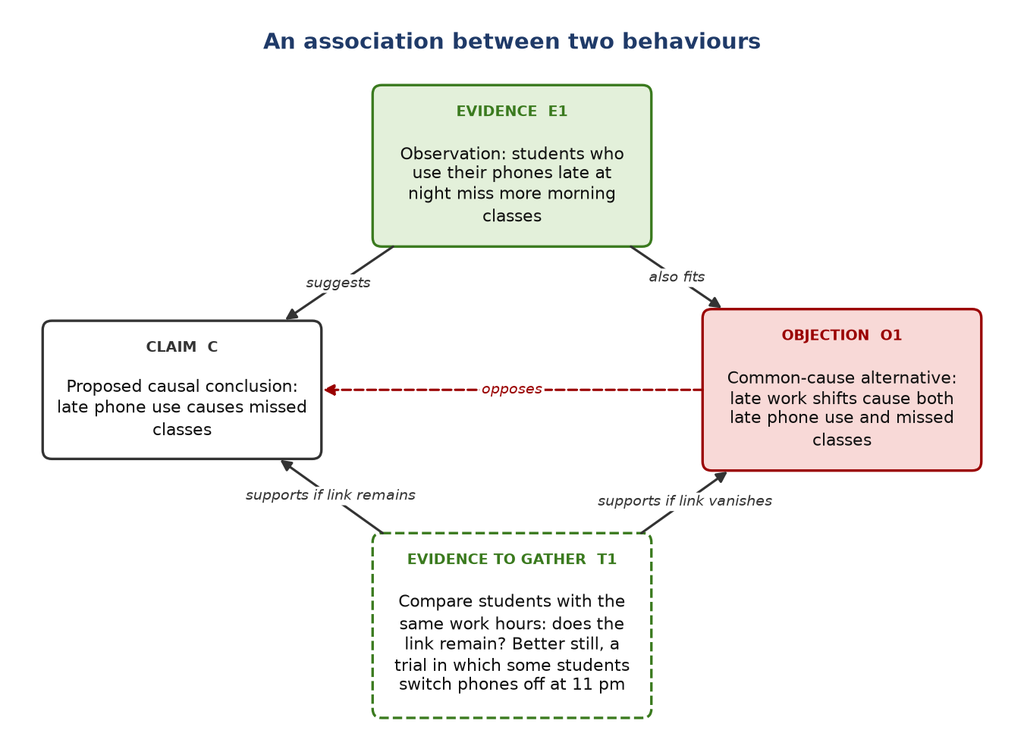

Note*Box key: green = evidence, white = claim, red = objection, dashed green = evidence still to gather. The dashed red arrow opposes.*

1. **Observation (E1):** students who use their phones late at night miss more morning classes.

2. **Proposed causal conclusion (C):** late phone use causes missed classes (for example, by cutting sleep).

3. **Common-cause alternative (O1):** a third factor, such as late work shifts, causes both late phone use and missed classes; Derry's "C causes both A and B" (the old car).

4. **Distinguishing evidence (T1):** compare students with the same work hours: if the association remains within each group, the common cause is ruled out as the whole story; if it vanishes, the common cause explains it. Stronger still, a controlled trial in which a random half of volunteers switch phones off at 11 pm would show whether reducing phone use reduces absences.

5. **Other checks:** time order (does heavier phone use come before the absences or after?), reverse causation (students with no morning classes may stay up later), and sample size, so that chance is not the explanation.

U8-A15Applied5 marks

Describe how intellectual humility, willingness to reconsider and a search for counterexamples could improve disagreement. Distinguish these attitudes from the analytical steps used to evaluate the claims.

Source Unit 8 Objective 10; Derry Chapter 7

**Attitudes (the affective side)**

1. *Intellectual humility:* accepting that my view may be an anchor or a cognitive illusion, so I hold it provisionally, with a degree of confidence rather than certainty (Derry's probabilistic thinking).

2. *Willingness to reconsider:* being ready to accommodate my belief to new evidence instead of assimilating the evidence to my belief (Discussion 8.2).

3. *Search for counterexamples:* actively looking for cases that would show me wrong, since a single good counterexample defeats a universal claim, and inviting the other side to supply them.

4. **How they improve disagreement:** each side stops defending a position at all costs; arguments are judged on their merits instead of by who holds them (avoiding ad hominem and the straw man), and the disagreement narrows to the points where evidence is really needed.

**Analytical steps (the cognitive side)**

5. **These are different:** attitudes make a person willing to evaluate fairly; the analytical steps are how the evaluation is done: identify the conclusion and premises, bring hidden assumptions into the open, check the logic (converse, inverse, distribution), evaluate the evidence (source, sample, suppressed evidence), assess causal claims, and diagram the argument (Derry ch. 7; Discussion 8.3). A humble person can still reason badly, and a skilled analyst can still refuse to see a counterexample; good critical thinking needs both.

Note*The course names "affective and cognitive strategies" only in Objective 10 and does not define them; see the note under OBJ10.*

U8-A16Applied10 marks

Use Snow's cholera investigation to distinguish evidence, an explanatory hypothesis, a hidden assumption and a response to a rival hypothesis. Explain why the comparison was informative without calling it randomized.

Source Unit 8 Study Question 13; Derry Chapter 3

1. **Evidence:** observations Snow collected: cholera cases clustered around the Broad Street pump and fell after its handle was removed; deaths per 10,000 houses were 315 among Southwark & Vauxhall customers (water drawn from a sewage-contaminated stretch of the Thames), 37 among Lambeth customers (intake moved upstream) and 59 in the rest of London (Discussion 3.4).

2. **Explanatory hypothesis:** cholera is caused by swallowing a "morbid material" from victims' excretions, carried in contaminated water (and on hands and food).

3. **Hidden assumption:** the two companies' customers differed only in their water. Snow made it explicit and defended it: the pipes of both companies ran down the same streets, a single house could differ from its neighbours, and each company supplied rich and poor, large houses and small.

4. **Response to a rival hypothesis:** against the effluvia theory, not everyone who breathes the effluvia of a patient falls ill, and outbreaks begin where no one was exposed to a victim; against the objection that no agent could be seen, smallpox and chancre matter are also known only by their effects.

5. **The comparison was informative:** about 300,000 people of every class and occupation "were divided into two groups without their choice, and, in most cases, without their knowledge," one receiving sewage-contaminated water and one clean water, so the usual alternative causes (poverty, crowding, district) were spread across both groups.

6. **A large, sharp difference:** a more than eight-fold difference in death rates (315 against 37) in so large a sample is too great to be chance, and the rest-of-London figure (59) gives a third reference point.

7. **Converging lines:** the water comparison agreed with independent evidence, the Broad Street cluster, the spared workhouse and brewery that had their own water or beer, and the pattern of personal-contact cases.

8. **Why it was not randomized:** no one assigned houses to companies by chance; supply depended on decisions made by owners or occupiers when the companies were competing. It was a natural experiment (an observational comparison), so some unknown difference between the groups could not be ruled out with certainty.

9. **So the conclusion is strong but provisional:** Discussion 3.4 says Snow's studies "did not demonstrate that his theory was true" but gave "sufficient reasons"; the causal model was completed when *Vibrio cholerae* was identified about 30 years later.

10. **Lesson for Unit 8:** the case uses both of Derry's foundations, reliable evidence and sound reasoning, and shows why making a hidden assumption explicit lets it be checked.

Note*The bank lists "Derry Chapter 3" as a source for this question, but Derry's book never mentions John Snow (Chapter 3 is about scientific instruments); the Snow story is in the course's Discussion 3.4.*

### People and attributions10

U8-P01Person

Identify Immanuel Kant (1724-1804) and the idea or contribution the assigned readings ascribe to this person. Explain its significance in this unit.

Source Discussion 8.1 epigraph

1. **Who.** Immanuel Kant (1724-1804) was a German philosopher (Discussion 1.1). Discussion 8.1 opens with a passage from the Preface to the First Edition (1781) of his *Critique of Pure Reason*, and says that Kant "has given what many consider to be the deepest analysis" of how the mind fits things together into categories (Discussion 8.1).

2. **Quotation.** "[T]he critique of reason leads ... naturally and necessarily to science; and, on the other hand, the dogmatical use of reason without criticism leads to groundless assertions, against which others equally specious can always be set, thus ending unavoidably in skepticism" (Discussion 8.1).

3. **Meaning.** Reason that examines its own grounds and limits leads to science. Reason used dogmatically, without that criticism, produces assertions that can always be met by equally plausible counter-assertions, so it ends in skepticism. Discussion 1.1 quotes the same passage when it argues that the tools of science must be kept "sharp" and used from the proper point of view.

4. **Significance.** Unit 8 treats reason as fitting things together and formal logic as one tool of reason, not reason itself. Critical thinking, introduced in Derry's Chapter 7, is the criticism Kant calls for: using specific tools to decide "whether to accept or reject claims that are made" and how reliable our conclusions are (Unit 8 Overview).

U8-P02Person

Identify Ludwig Wittgenstein (1889-1951) and the idea or contribution the assigned readings ascribe to this person. Explain its significance in this unit.

Source Discussion 8.1 epigraph

1. **Who.** Ludwig Wittgenstein (1889-1951) was an Austrian-born philosopher. The second epigraph of Discussion 8.1 comes from his *Philosophical Remarks* (Discussion 8.1).

2. **Quotation.** "Tell me how you are searching, and I will tell you what you are searching for" (Discussion 8.1).

3. **Meaning.** The discussion does not explain the line, but its point is that the way a search is made reveals, and limits, what the searcher can find. Discussion 8.1 shows this in its own search for the meaning of "reason": dictionary roots lead to reasoning as a mental process of "fitting together," and the discussion then labels this method "scholastic reasoning," not scientific reasoning.

4. **Significance.** How a question is investigated shapes the answer. Inference from definitions has its uses, but "it is an error to assume that scientific reasoning is only an elaboration of scholastic reasoning" (Discussion 8.1). Judging an argument therefore includes asking what its method could and could not have found.

U8-P03Person

Identify the gestalt psychologists and the idea or contribution the assigned readings ascribe to this group. Explain its significance in this unit.

Source Discussion 8.1

1. **Who.** In the early 20th century the gestalt psychologists took up the question of how we tell when something actually fits in perception (Discussion 8.1).

2. **Contribution.** They determined criteria for a "good form" in the visual field, and these also apply to recognizing "good forms" in theoretical systems of ideas. Adapted to scientific hypotheses, the criteria are regularity, symmetry, harmony, simplicity, conciseness, inclusiveness and unity, to be used as "rules of thumb," not fixed rules.

3. **How they work.** The first six apply "all other things being equal": prefer a hypothesis that extends accepted ideas, is symmetrical or harmonious with them, is simpler and more concise, and explains the most; unity, a unified understanding of a field, is the goal. Inclusiveness seems to oppose simplicity, but simple, concise theories such as Newton's law of universal gravitation and Darwin's theory of evolution are often the most inclusive.

4. **Significance.** Unit 8 Objective 2 asks for the seven criteria for a "good fit" (Unit 8 Overview). Since reasoning is fitting together, the criteria help judge hypotheses, but trade-offs are often needed, so "finding a good fit is more a matter of aesthetic sensitivity than of applying fixed rules" (Discussion 8.1).

U8-P04Person

Identify William of Occam and the idea or contribution the assigned readings ascribe to this person. Explain its significance in this unit.

Source Discussion 8.1

1. **Who.** William of Occam (also spelled Ockham) was a medieval English philosopher. The course does not discuss him; it uses the principle named after him, Occam's razor (Discussion 8.1).

2. **Principle.** Occam's razor is the philosophical injunction that "entities are not to be multiplied unnecessarily" (Discussion 8.1). An explanation should not assume more things or causes than it needs.

3. **Use in Unit 8.** The gestalt criteria of simplicity and conciseness "are recognizable as implications of Occam's razor": all other things being equal, the simpler or more concise hypothesis or argument is to be preferred (Discussion 8.1).

4. **Significance.** The razor is a rule of thumb, not a proof: a simpler hypothesis loses if it explains less, which is why simplicity is weighed against inclusiveness. It also counts against rescuing a belief with extra assumptions, like the ad hoc explanations that anchoring produces (Discussion 8.2).

U8-P05Person

Identify Lewis Carroll (Charles Dodgson, 1832-1898) and the idea or contribution the assigned readings ascribe to this person. Explain its significance in this unit.

Source Discussion 8.2 epigraph

1. **Who.** Lewis Carroll was the pen name of Charles Dodgson (1832-1898). The epigraph of Discussion 8.2 comes from his poem "The Hunting of the Snark: An Agony in Eight Fits" (Discussion 8.2).

2. **Quotation.** "What I tell you three times is true" (Discussion 8.2).

3. **Meaning.** The line is usually read as a joke about belief by repetition: saying a claim again makes it familiar, not true. Discussion 8.2 explains why such tricks work: we "tend to believe that our conclusions are correct," and people initially believe what they hear or read and question it only later, which advertisers exploit.

4. **Significance.** The discussion is about cognitive illusions: we "form confident opinions based on insufficient, often biased, data" (Discussion 8.2). Scientific reasoning replaces repetition and confidence with repeatable observations and unbiased evidence.

U8-P06Person

Identify John Stuart Mill and the idea or contribution the assigned readings ascribe to this person. Explain its significance in this unit.

Source Discussion 8.2

1. **Who.** John Stuart Mill was an English philosopher; Discussion 8.2 cites the book on fallacies in his *A System of Logic*.

2. **Idea.** Mill described the "most deeply-rooted, perhaps" of all fallacies of causal reasoning as the prejudice that "the conditions of a phenomenon must, or at least probably will, resemble the phenomenon itself" (Discussion 8.2).

3. **Examples.** On this prejudice, great events must have great causes, complex events complex causes, and emotional events emotional causes. Discussion 8.2 places it under the representativeness heuristic: when looking for causes, we consider those whose features match features in the effect.

4. **Significance.** A cause need not resemble its effect, so this causal fallacy has to be checked by testing a causal claim rather than accepting it because it seems fitting. Recognizing it is part of Unit 8's account of how the decision heuristics lead to error, and of how science develops tools to use them accurately.

U8-P07Person

Identify Aristotle and the idea or contribution the assigned readings ascribe to this person. Explain its significance in this unit.

Source Discussion 8.2

1. **Who.** Aristotle was the Greek philosopher, Plato's student, who determined the laws of formal logic (Discussion 7.2).

2. **Idea.** He "observed that the ability to doubt is rare" (Discussion 8.2). Modern research in psychology confirms this: people tend to believe what they hear or read at first, and only question it later, after thinking about it.

3. **Anchoring.** Discussion 8.2 uses his remark to illustrate anchoring, the quick selection of an interpretation that is then kept even in the face of strong contrary evidence. Instead of changing the anchor, people make minor modifications or offer ad hoc explanations, as in the joke about the man who says of a woman driving well, "Drives like a man!"

4. **Significance.** Anchoring biases us towards treating new experiences as instances of our beliefs rather than as evidence that might test them. Science depends on the rarer habit of doubt; advertisers, by contrast, add cognitive noise designed to distract us from critical analysis.

U8-P08Person

Identify Thomas H. Huxley (1825-1895) and the idea or contribution the assigned readings ascribe to this person. Explain its significance in this unit.

Source Discussion 8.2; Discussion 1.1

1. **Who.** Thomas Henry Huxley (1825-1895) was a biologist. Discussion 1.1 quotes him: "The method of scientific investigation is nothing but the expression of the necessary mode of working of the human mind" (Discussion 1.1).

2. **Claim in Unit 8.** Discussion 8.2 says Huxley "was correct in his claim that scientific thought uses our ordinary everyday modes of thinking, made more precise" (Discussion 8.2).

3. **The catch.** The tools needed for that precision are often difficult to learn, and may seem counter-intuitive because they go against apparently "obvious" cognitive illusions. A champion gymnast uses only everyday capacities such as balance and strength, but reaches championship level only through long and arduous training.

4. **Significance.** The decision heuristics are essential to science, so its evolution is "a process of developing tools for the accurate application of these heuristics, rather than their replacement by something new" (Discussion 8.2). People are not simply irrational; clear thinking is ordinary thinking, trained.

U8-P09Person

Identify Norman MacLean and the idea or contribution the assigned readings ascribe to this person. Explain its significance in this unit.

Source Discussion 8.2

1. **Who.** Norman MacLean was an American writer; Discussion 8.2 quotes his book *A River Runs Through It and Other Stories*.

2. **Quotation.** "All good things come by grace, ... and grace comes by art, and art does not come easy" (Discussion 8.2).

3. **Context.** It closes the gymnast analogy: a champion gymnast uses only everyday capacities, but the training is long and arduous, and "It would be foolish to think that the tools of clear and precise thinking, in science or in any other intellectual activity, could be acquired without effort" (Discussion 8.2).

4. **Significance.** It completes Huxley's point. Scientific thought is ordinary thinking made precise, but the precision is an art that takes effort to learn: formal logic, careful classification, repeatable observations and statistical methods that give unbiased estimates.

U8-P10Person

Identify William E. H. Lecky and Sherlock Holmes and the ideas or contributions the assigned readings ascribe to them. Explain their significance in this unit.

Source Derry ch. 7 epigraphs, p. 89

1. **Who.** William E. H. Lecky was an Irish historian, and Sherlock Holmes is Arthur Conan Doyle's fictional detective. Their words are the two epigraphs of Derry's Chapter 7: Lecky's from his *History of the Rise and Influence of Rationalism in Europe*, and Holmes's from "The Adventure of the Copper Beeches" (Derry, pp. 89, 106).

2. **Lecky.** "The number of persons who have a rational basis for their belief is probably infinitesimal; for illegitimate influences not only determine the convictions of those who do not examine, but usually give a dominating bias to the reasonings of those who do" (Derry, p. 89).

3. **Holmes.** "Crime is common. Logic is rare" (Derry, p. 89).

4. **Significance.** Both say that sound reasoning is uncommon, even among people who examine their beliefs. Derry's chapter answers with methods of clear thinking: a well-constructed scientific argument "generally rests upon two foundations: reliable empirical evidence and sound logical reasoning" (Derry, p. 89), and Unit 8 Objective 5 asks you to state these two foundations (Unit 8 Overview).

Unit 9

## Principles of Reason and Formal Logic

Approach In the source equations a leading minus sign denotes logical negation. Original formulas are preserved as editable Word equations. Give assumptions when using the traditional square of opposition.

### Official study guide questions11

U9-SG01Study guide

The Aristotelian law of identity is often stated in the form “*A* equals *A*,” or “A thing is identical with itself.” Aristotle also defined the essence of a thing as “that which it must have in order to be entitled to its name.” Write a short essay (about 300-500 words) discussing the possible relations between the law of identity and the definition of an essence, in light of the three principles of reason given in Discussion 9.1.

Source Unit 9 Study Questions question 1

**Thesis.** The law of identity and Aristotle's definition of essence are two sides of one idea: a thing can be "identical with itself" only if something about it stays fixed, and the essence is exactly what stays fixed, "that which it must have in order to be entitled to its name."

**Identity needs an essence.** Taken literally, "A equals A" says nothing; it becomes useful only when we ask *what* must stay the same for a thing to still count as A. A tree changes completely as it grows from a seedling (Discussion 9.1), yet we call it the same tree, because the properties that entitle it to its name persist while accidental ones, such as height, do not matter. Applied to real things, the law of identity presupposes essences.

**An essence needs identity.** In the modern reading, the law of identity is a rule for language: once a term is defined, its meaning "cannot legitimately be changed in further discussions" (Discussion 9.2). A definition by essence is such a fixed meaning; if "mammal" changed meaning halfway through an argument, we would commit the fallacy of equivocation (four terms).

**Non-contradiction.** If a thing's essence includes a property, nothing that lacks that property can bear the name. Triangles are three-sided by essence, so "a four-sided triangle" is a contradiction and must be false (Discussion 9.1). In science, an apparent contradiction (a non-white "swan") means a defining assumption must be checked.

**Sufficient reason.** The analytical view of sufficient reason says that a thing has its characteristics because "it is contained in a category defined by those characteristics" (Discussion 9.1). The essence is that reason: Socrates is mortal *because* he falls under "man." Identity guarantees that the category, and therefore the reason, does not shift.

**Identity of indiscernibles.** Two things with no essential difference are entitled to the same name, which turns identity into a rule for grouping: two cue balls are "identical" for billiards though they are two balls. What counts as essential depends on the level of discourse: lions and tigers are the same as felines but different as species.

**Possible tension.** Essences assume unchanging identity, but experience is change ("you cannot step in the same river twice"). Footnote 186 notes that the Aristotelian laws "eliminate the possibility of change"; Aristotle had to add the life cycle to deal with it. Essences therefore work best for stable kinds and must be fixed by stated criteria.

**Conclusion.** The law of identity says that a name must keep one meaning; the essence says what that meaning is; and the three principles of reason tell us how to use both: reject what contradicts the essence, look for the essence as the reason for a thing's properties, and treat things without essential differences as the same, at a stated level of discourse.

U9-SG02Study guide

Chapter 1 of *What Science Is* describes Edward Jenner’s discovery of a vaccination against smallpox. Analyze Jenner’s work in terms of the four polarities of reason presented in Discussion 9.1.

Source Unit 9 Study Questions question 2

Jenner's work (Derry ch. 1, pp. 21-24) uses both poles of each of the four polarities of Discussion 9.1.

1. **Bottom-up start.** Jenner began with components rather than a theory: a milkmaid's claim that cowpox protects against smallpox, then years of case records of cowpox in cows and humans, including the cases where protection failed.

2. **Induction.** From those records he generalized that one kind of cowpox gives immunity. This is induction from a finite set of cases, so it could fail; it did fail when milkers who had had true cowpox later caught smallpox.

3. **Abduction.** Facing that surprise, he looked for the best explanation and found it while comparing two cows at different stages: the matter in the pustules gains and loses strength, and protects only at its strongest. This explanation fitted all the puzzling cases (the failed milkers had caught cowpox early in its course), which is inference to the best explanation.

4. **Analysis.** He broke "cowpox" into parts. Differences in symptoms (pustule shape, duration, armpit swelling) showed that it was several different diseases, only one of them "true cowpox." He also divided the disease's course into stages.

5. **Synthesis.** He then combined the strands (the right disease, the right stage, and the absence of reaction to smallpox inoculation in people who had had true cowpox) into a single hypothesis.

6. **Top-down and deduction.** Taking the hypothesis as true, he deduced a prediction: matter taken at full strength should protect a person who had never had cowpox. In May 1796 he infected James Phipps with matter from Sarah Nelmes's pustule, inoculated him with smallpox that July, and no smallpox developed. Derry calls this pathway the hypothetico-deductive method (p. 24).

7. **Structural and functional.** His explanation is mostly structural: it rests on the parts (which disease, and how strong the matter is). The claim that cowpox "protects" is functional, describing what infection does for the body in its environment. Neither the mechanism (immunity) nor the cause (a virus) was known to Jenner.

8. **Interplay.** The polarities alternated. Bottom-up observation led to an inductive hypothesis, a contradiction prompted further analysis and an abductive revision, and top-down deduction led to the decisive test.

Note*Outside the readings: the immune mechanism and the viral cause of smallpox were worked out long after Jenner (viruses were identified in the 1890s). Derry's account stops at the 1796 experiment.*

U9-SG03Study guide

Describe the way that the four polarities of reason given in Discussion 9.1 are employed together in the hypothetico-deductive method.

Source Unit 9 Study Questions question 3

The hypothetico-deductive (HD) method is a cycle in which each of the four polarities is used at a different stage (Discussion 9.1, "Correspondences among Complementary Pairs").

1. **Bottom-up, inductive or abductive start.** We begin with data about the components of a system and, by induction or abduction, generate an explanatory hypothesis. It is good practice to consider several hypotheses and pick the most likely one to test.

2. **Synthesis and structure.** The hypothesis is a synthesis: it fits many separate observations into one account of how the system is built and behaves, which is a structural explanation of the whole in terms of its parts.

3. **Top-down and deduction.** We then assume that the hypothesis is true and deduce further consequences about components and their interactions. This step is analysis: the general claim is broken down into specific, testable predictions, often functional ones about what the parts must do.

4. **Test and contradiction.** Predictions are compared with observation. If they fit, our confidence rises but nothing is proved, because affirming the consequent is invalid. If they do not fit, the contradiction shows that the hypothesis, or another assumption used in the deduction, is false (the Overview's point about valid arguments with false conclusions). The hypothesis is then adjusted and the cycle repeats.

5. **Top-down at the beginning too.** The starting data are theory-laden: a conceptual framework has already decided which data are relevant and which questions matter, so top-down thinking shapes even the "bottom-up" first step.

6. **Example.** Jenner (Derry pp. 21-24) worked bottom-up from case records to a hypothesis by induction and abduction, analysed cowpox into distinct diseases and stages, synthesized a hypothesis, then deduced and tested a prediction on James Phipps. Snow's cholera argument similarly synthesized many strands of evidence before deducing what the water-company data should show.

**Point to remember.** The method is not a choice between the poles but "a continual interplay" between them, and science depends on that interplay.

U9-SG04Study guide

Cats, dogs, tigers and wolves are all mammals; cats and tigers are feline, while dogs and wolves are canine; cats differ from tigers and dogs differ from wolves. Write a short essay (300-500 words) describing the formal structure that is imposed on the set of cats, dogs, tigers and wolves by the naming process taken together with the three laws of Aristotelian logic. You may wish to draw a diagram.

Source Unit 9 Study Questions question 4

**The structure.** Naming the four animals, together with the three Aristotelian laws, turns a loose collection into a hierarchy of classes: a tree with one general class at the top, two subclasses in the middle and four species at the bottom (diagram).

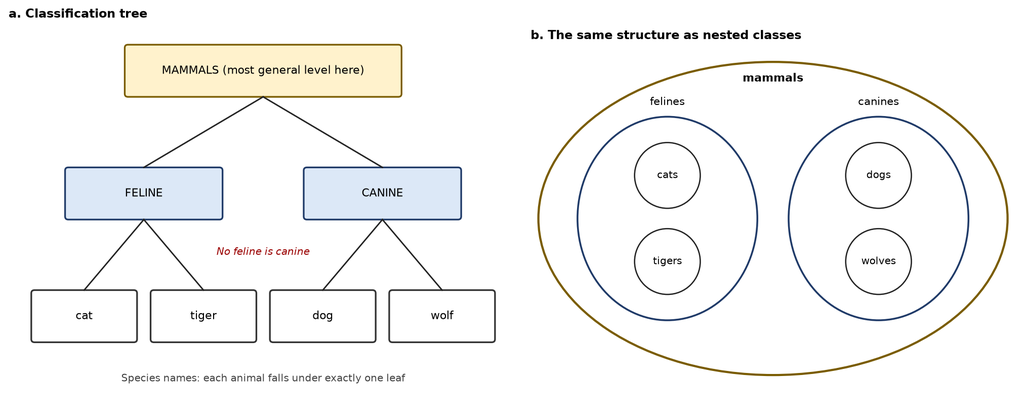

**How the names create levels.** "Mammal" names what all four share. "Feline" names what cats and tigers share and dogs and wolves lack; "canine" names the reverse. "Cat," "tiger," "dog" and "wolf" name what distinguishes each species. Each name is defined by an essence: the properties a thing "must have in order to be entitled to its name." The names therefore sit at different levels of generality, and each lower class is contained in the class above it.

**Law of identity.** Each name keeps one fixed meaning throughout the discussion. "Feline" must mean the same thing whether we apply it to cats or tigers; otherwise we would have four terms instead of three and every inference would fail (equivocation). Identity is what makes the boxes in the diagram stable.

**Law of contradiction.** Nothing can both have and lack the same property. No animal can be both feline and not feline, so the feline and canine classes cannot overlap: "No feline is canine." In the same way, within the felines nothing is both a cat and a tiger, because "cats differ from tigers."

**Law of the excluded middle.** Every animal either has a property or lacks it. Each animal in the set is either feline or not feline, so the middle level divides the set into two parts with nothing left over; at the bottom, each animal falls under exactly one species name. Together, contradiction and excluded middle make every level a *partition*: classes that do not overlap and that together cover everything.

**What follows by deduction.** Because the classes are nested and exclusive, valid syllogisms follow immediately. All cats are feline and all felines are mammals, so all cats are mammals. No feline is canine and all dogs are canine, so no dog is feline. Properties flow down the tree: whatever is true of all mammals is true of each species (Discussion 9.2: "the particular is contained in the universal").

**Identity of indiscernibles and level of discourse.** At the "feline" level a cat and a tiger have no essential difference, so they count as the same; at the species level they are different. The structure therefore tells us that sameness is always relative to a stated level, exactly as Discussion 9.1 says of lions and tigers.

**Limits.** The structure is sharp only because the laws require it. Real biological groups change over time and can blur (dogs and wolves can interbreed), and Discussion 9.2 notes that the Aristotelian laws exclude change. The tree is a property of our naming system, imposed on nature, and it fits only as far as nature's kinds are stable and distinct.

Note*Outside the readings: dogs are often classified as a subspecies of the grey wolf (Canis lupus familiaris), which illustrates how sharp naming boundaries can sit uneasily on real populations.*

U9-SG05Study guide

State the three laws of Aristotelian logic and describe how they provide a natural way to think about unchanging independent objects.

Source Unit 9 Study Questions question 5

**The three laws (Discussion 9.2).**

1. **Identity:** a thing is equal to itself (A is A). For Aristotle, things have an invariant identity; in modern logic, a defined term keeps its meaning throughout an argument.

2. **Contradiction:** no thing is anything other than itself; equivalently, nothing can have a property and its negation at the same time, so no statement is both true and false.

3. **Excluded middle:** for any thing and any property, either the thing has the property or it does not; every proposition is either true or false, with no grey area.

**Why they suit unchanging, independent objects.**

4. **Unchanging.** Identity assumes that what a thing is (its essence) stays fixed. A billiard ball that does not change can be recognized as the same ball after we turn away (Discussion 9.1). Footnote 186 notes that the laws "eliminate the possibility of change": if a thing changes, it becomes other than itself, which the laws forbid.

5. **Sharply bounded.** Contradiction and excluded middle give every object a definite yes-or-no answer to every property question. That is natural for discrete things such as stones, coins or billiard balls, which plainly either are or are not round, red or in the pocket.

6. **Independent.** The laws define a thing by its own properties, not by its relations or its history. Each object can be named, sorted into a class and reasoned about on its own, which is what makes class logic and syllogisms possible.

7. **Where it strains.** For things that grow or change (a tree after ten years, a person, a river), we must add identity criteria, as Aristotle did with the idea of the life cycle. For things that depend on context, such as light, which shows wave or particle behaviour depending on the experiment, we must specify the situation to avoid an apparent contradiction.

Note*Course slip: Discussion 9.2's one-line statements are garbled. Its "law of the excluded middle" ("No thing can have both a property and its opposite") is really the law of contradiction. The paragraph after it gives the standard meanings used above.*

U9-SG06Study guide

Determine which of the following syllogisms are valid:

a. Mice have sharp teeth  
Some animals with sharp teeth eat cheese  
Therefore mice eat cheese

b. Dogs are not giraffes  
Cats are not giraffes  
Therefore dogs are cats

c. Species in danger of extinction ought to be protected  
Smallpox virus is in danger of extinction  
Therefore the smallpox virus ought to be protected

d. All fish have legs  
All animals with legs can jump over the moon  
Therefore fish can jump over the moon

Source Unit 9 Study Questions question 6

To test a syllogism, rewrite each premise in standard form, then identify the middle term (M), the minor term (S, subject of the conclusion) and the major term (P, predicate of the conclusion). Then apply the six rules (Discussion 9.2).

**a. Invalid.** Standard form: "All mice are sharp-toothed animals" (A, minor premise) and "Some sharp-toothed animals eat cheese" (I, major premise); conclusion "All mice eat cheese" (A). The middle term, *sharp-toothed animals*, is the predicate of an affirmative premise and the subject of a particular one, so it is never distributed. This is the **fallacy of the undistributed middle**. A second fault: one premise is particular, but the conclusion is universal (Lemma 3). The cheese-eating animals may be rats, not mice.

**b. Invalid.** "No dogs are giraffes" (E) and "No cats are giraffes" (E); conclusion "All dogs are cats" (A). Two negative premises give no link through the middle term (**fallacy of exclusive premises**, Rule 4). An affirmative conclusion also cannot follow from a negative premise (Rule 5). The course gives the same form with alligators.

**c. Valid in form.** "All species in danger of extinction ought to be protected" (A, major); "The smallpox virus is a species in danger of extinction" (A, minor); conclusion A. This is first figure, AAA (the form of "All men are mortal; Socrates is a man"). The middle term is distributed in the major premise, and no rule is broken. Whether we must accept the conclusion depends on whether the premises are true. The major premise was meant for wildlife, not for disease agents, so it is false as a universal. If "endangered species" is read in two senses, the argument becomes the fallacy of four terms. This is the point of the example: a valid form does not guarantee a true conclusion.

**d. Valid.** "All animals with legs can jump over the moon" (A, major); "All fish have legs" (A, minor); conclusion "All fish can jump over the moon." Again first figure AAA, so it is valid. Both premises are false and so is the conclusion. Like the Overview's "pigs can fly," it shows that logical validity is not empirical truth: a valid argument with a false conclusion must have at least one false premise.

**Summary.** a and b are invalid; c and d are valid. The Venn diagrams in Question 8 confirm this.

Note*Outside the readings: the smallpox virus was declared eradicated from nature by the World Health Organization in 1980 and survives only in laboratory stocks, which is why it can be called "in danger of extinction."*

U9-SG07Study guide

Construct truth tables for each of the following propositions:

a. (*p*∧*q*)∨−*p*

b. (*p*∨*q*)∧−(*p*∧*q*)  
[In computer applications this is written as *pXORq* where the connective *XOR* is the “exclusive or,” defined as *p* or *q*, but not both.]

c. [(*p*→*q*)∨(*q*→*r*)]∧(*p*→*r*)

d. [(*p*→*q*)∧(*q*→*r*)]∧−*r*

Source Unit 9 Study Questions question 7

Here ¬ is the course's "−" (not). For each table there is one row per combination of truth values: 2² = 4 rows for two variables, 2³ = 8 rows for three. The rows follow the course pattern: the right-hand variable alternates T, F; the next column alternates in pairs; and so on (Discussion 9.2).

**a. (p ∧ q) ∨ ¬p**

| **p** | **q** | **p∧q** | **¬p** | **(p∧q)∨¬p** |
| --- | --- | --- | --- | --- |
| T | T | T | F | T |
| T | F | F | F | F |
| F | T | F | T | T |
| F | F | F | T | T |

It is false only when p is true and q is false. That is exactly the truth table of p → q, so the two are equivalent.

**b. (p ∨ q) ∧ ¬(p ∧ q), "exclusive or" (p XOR q)**

| **p** | **q** | **p∨q** | **¬(p∧q)** | **(p∨q)∧¬(p∧q)** |
| --- | --- | --- | --- | --- |
| T | T | T | F | F |
| T | F | T | T | T |
| F | T | T | T | T |
| F | F | F | T | F |

It is true when exactly one of p and q is true, the "one or the other but not both" used in computing.

**c. [(p → q) ∨ (q → r)] ∧ (p → r)**

| **p** | **q** | **r** | **p→q** | **q→r** | **(p→q)∨(q→r)** | **p→r** | **whole** |
| --- | --- | --- | --- | --- | --- | --- | --- |
| T | T | T | T | T | T | T | T |
| T | T | F | T | F | T | F | F |
| T | F | T | F | T | T | T | T |
| T | F | F | F | T | T | F | F |
| F | T | T | T | T | T | T | T |
| F | T | F | T | F | T | T | T |
| F | F | T | T | T | T | T | T |
| F | F | F | T | T | T | T | T |

The bracket (p → q) ∨ (q → r) is true in every row: if q is true, then p → q is true; if q is false, then q → r is true. So the whole proposition has the same truth values as p → r: false only when p is true and r is false.

**d. [(p → q) ∧ (q → r)] ∧ ¬r**

| **p** | **q** | **r** | **p→q** | **q→r** | **(p→q)∧(q→r)** | **¬r** | **whole** |
| --- | --- | --- | --- | --- | --- | --- | --- |
| T | T | T | T | T | T | F | F |
| T | T | F | T | F | F | T | F |
| T | F | T | F | T | F | F | F |
| T | F | F | F | T | F | T | F |
| F | T | T | T | T | T | F | F |
| F | T | F | T | F | F | T | F |
| F | F | T | T | T | T | F | F |
| F | F | F | T | T | T | T | T |

It is true only in the last row, where p, q and r are all false. If r is false, then q → r forces q to be false, and p → q then forces p to be false. This is a chain of contrapositive (modus tollens) steps: when the final consequence fails, every link back up the chain must fail too.

U9-SG08Study guide

Draw a Venn diagram for each of the syllogisms in Question 6, above.

Source Unit 9 Study Questions question 8

Method (Discussion 9.2): draw three overlapping circles for S (minor term), P (major term) and M (middle term). Shade the regions that a universal premise says are empty. Put an x in a region that a particular premise says has a member, or on a line when the premise does not say which side. Then read off whether the conclusion is forced. The diagrams below were drawn from the premises of Question 6.

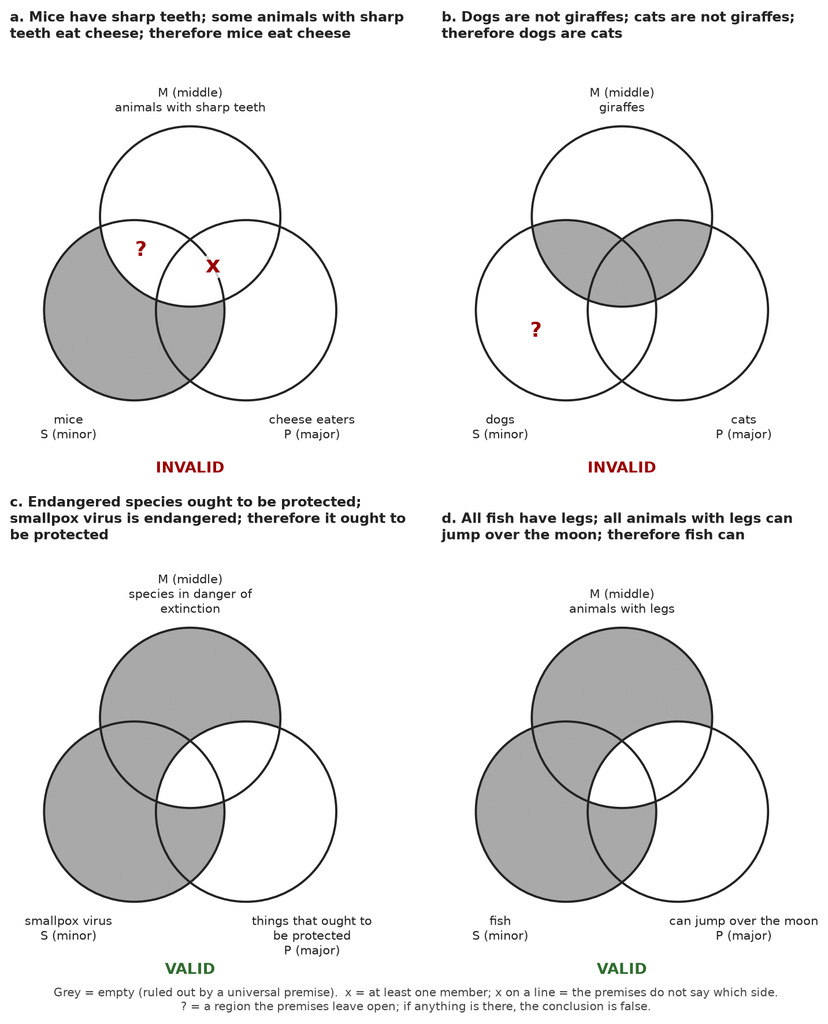

1. **a (invalid).** "All mice are sharp-toothed" shades all of *mice* outside *sharp teeth*. "Some sharp-toothed animals eat cheese" puts an x in sharp teeth ∩ cheese eaters, but on the mouse line, because the premise does not say whether those cheese eaters are mice. The region "mice with sharp teeth that do not eat cheese" (?) remains open, so "all mice eat cheese" is not forced.

2. **b (invalid).** The two E premises shade dogs ∩ giraffes and cats ∩ giraffes. Nothing is said about dogs outside giraffes, so the region "dogs that are not cats" (?) stays open. Two exclusions from the same class say nothing about how the two classes relate to each other.

3. **c (valid).** Shading "endangered species outside protected things" and "smallpox virus outside endangered species" leaves the virus circle open only inside *ought to be protected*, so the conclusion is forced.

4. **d (valid).** The same pattern: everything in *fish* outside *can jump over the moon* is shaded, so the conclusion follows from the premises, whatever their truth.

**Rule of reading.** A syllogism is valid when, after both premises are drawn, the conclusion is already drawn. Validity is not affected by whether the premises are true.

U9-SG09Study guide

You are shown four cards, two labeled with the letters A and K and two with the numbers 2 and 7:

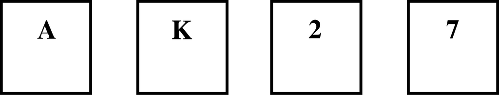

You are told that these cards follow the rule that if there is a vowel on one side, then there is an even number on the other side. Which cards must you turn over in order to test this rule?

Source Unit 9 Study Questions question 9

**Answer: turn over A and 7, and only those.**

1. **The rule is a conditional:** if vowel then even (p → q). The only case that breaks it is a vowel with an odd number on the other side (p true, q false, the single F row of the p → q truth table).

2. **A (a vowel) must be turned.** If an odd number is on the back, the rule is false. This checks the rule directly (p, so look for q).

3. **7 (odd, not-q) must be turned.** If a vowel is on the back, the rule is false. This is the contrapositive check, ¬q → ¬p, which is logically equivalent to the rule (Question 10).

4. **K need not be turned.** The rule says nothing about consonants: a consonant with any number satisfies p → q, because a false antecedent makes the conditional true.

5. **2 need not be turned.** A consonant or a vowel behind an even number is consistent with the rule. Turning it only looks for confirmation, and inferring the rule from even numbers would be affirming the consequent.

**Lesson.** A test must look for the case that could *refute* the rule. The tempting choice of A and 2 looks only for agreement, a habit that goes with the Unit 8 point that we hold opinions against contrary evidence.

Note*Outside the readings: this is Peter Wason's "selection task" (1966). In experiments, most people fail it in this abstract form.*

Note*Course slip: Discussion 9.2's experimental-design paragraph describes the contrapositive test as checking "cases where Q occurs but there was no P." That is the converse direction, and it cannot falsify P → Q. The contrapositive test is the one used here: look at cases without Q (the 7) and check that P is absent.*

U9-SG10Study guide

Prove that *p*→*q* and −*q*→−*p* are logically equivalent.

**Hint:** Show that they have the same truth tables; −*q*→−*p* is the contrapositive form of *p*→*q*.

What is the importance of the contrapositive in the hypothetico-deductive method?

Source Unit 9 Study Questions question 10

**Proof by truth table.**

| **p** | **q** | **p→q** | **¬q** | **¬p** | **¬q→¬p** |
| --- | --- | --- | --- | --- | --- |
| T | T | T | F | F | T |
| T | F | F | T | F | F |
| F | T | T | F | T | T |
| F | F | T | T | T | T |

The columns for p → q and ¬q → ¬p are identical (T, F, T, T). Each is false only when p is true and q is false. Propositions with the same truth values in every row are logically equivalent (Discussion 9.2). So p → q and its contrapositive ¬q → ¬p are equivalent. ∎

**Importance in the hypothetico-deductive method.**

1. **Hypothesis → prediction.** The method has the form H → P: if the hypothesis is true, the prediction will be observed.

2. **Falsification uses the contrapositive.** Because H → P is equivalent to ¬P → ¬H, a failed prediction validly refutes the hypothesis (modus tollens). This is the Overview's point: if a deduced, testable conclusion turns out false, "the hypothesis, or some other assumption involved in the deduction, is false." Derry puts it as: if the conclusion of a valid syllogism is false, at least one premise must be false (p. 91).

3. **Confirmation is weaker.** Observing P does not prove H; reasoning from P to H is affirming the consequent (the converse), which is invalid. Science can conclusively reject hypotheses but only provisionally accept them.

4. **Test design.** The contrapositive tells us where to look for disproof: in cases where the predicted effect is absent, check that the supposed cause was absent too, as with the 7 card in Question 9.

U9-SG11Study guide

A tautology is a proposition that is always true regardless of the truth-values of its component parts. For example,*p*∨−*p* is a true whatever the truth-value of *p*. Use truth tables to verify each of the following tautologies:

a. −(*p*∨*q*)↔(−*p*∧−*q*)

b. −(*p*∨*q*)↔(−*p*∧−*q*)

c. *p*∧*q*→*p*∨*q*

d. [−*p*→(*r*∧−*r*)]→*p*

e. [*p*∨(*q*∧*r*)]↔[(*p*∨*q*)∧(*p*∨*r*)]

Source Unit 9 Study Questions question 11

A tautology has T in every row of its final column (¬ is the course's "−").

**a. ¬(p ∨ q) ↔ (¬p ∧ ¬q)**

| **p** | **q** | **¬(p∨q)** | **¬p∧¬q** | **↔** |
| --- | --- | --- | --- | --- |
| T | T | F | F | T |
| T | F | F | F | T |
| F | T | F | F | T |
| F | F | T | T | T |

The two sides agree in every row, so the biconditional is always true. This is De Morgan's law: "not (p or q)" means "neither p nor q."

**b. ¬(p ∨ q) ↔ (¬p ∧ ¬q), as printed**

This repeats part a word for word, so the table and verdict are the same: a tautology. The intended second law of De Morgan is almost certainly ¬(p ∧ q) ↔ (¬p ∨ ¬q), and it is also a tautology:

| **p** | **q** | **¬(p∧q)** | **¬p∨¬q** | **↔** |
| --- | --- | --- | --- | --- |
| T | T | F | F | T |
| T | F | T | T | T |
| F | T | T | T | T |
| F | F | T | T | T |

**c. (p ∧ q) → (p ∨ q)**

| **p** | **q** | **p∧q** | **p∨q** | **(p∧q)→(p∨q)** |
| --- | --- | --- | --- | --- |
| T | T | T | T | T |
| T | F | F | T | T |
| F | T | F | T | T |
| F | F | F | F | T |

If both are true, then at least one is true. The conditional could only fail with a true "and" and a false "or," which never happens.

**d. [¬p → (r ∧ ¬r)] → p**

| **p** | **r** | **¬p** | **r∧¬r** | **¬p→(r∧¬r)** | **whole** |
| --- | --- | --- | --- | --- | --- |
| T | T | F | F | T | T |
| T | F | F | F | T | T |
| F | T | T | F | F | T |
| F | F | T | F | F | T |

The column for r ∧ ¬r is always false: a contradiction. This is proof by contradiction (reductio ad absurdum): if assuming not-p leads to a contradiction, then p must be true, which is the principle of non-contradiction at work.

**e. [p ∨ (q ∧ r)] ↔ [(p ∨ q) ∧ (p ∨ r)]**

| **p** | **q** | **r** | **q∧r** | **p∨(q∧r)** | **(p∨q)∧(p∨r)** | **↔** |
| --- | --- | --- | --- | --- | --- | --- |
| T | T | T | T | T | T | T |
| T | T | F | F | T | T | T |
| T | F | T | F | T | T | T |
| T | F | F | F | T | T | T |
| F | T | T | T | T | T | T |
| F | T | F | F | F | F | T |
| F | F | T | F | F | F | T |
| F | F | F | F | F | F | T |

"Or" distributes over "and," just as multiplication distributes over addition in arithmetic.

Note*Course slip: parts a and b of this Study Question are identical. The Final bank's A13 gives the corrected pair.*

### Learning objective questions10

U9-OBJ01Objective

state the principles of non-contradiction, sufficient reason and the identity of indiscernibles, and describe some of the ways they are applied in scientific thinking.

Source Unit 9 Overview objective 1

**Principle of non-contradiction.** Every statement that involves a contradiction is false, and the negation of a falsehood is true. "All triangles have four sides" is false because it asserts 3 = 4 (Discussion 9.1).

1. *In science:* in an analytic argument, a contradiction shows that a definition or rule of deduction has been violated somewhere. In empirical work, it shows that an assumption must be checked, or that we have gone beyond its range: a non-white swan does not abolish white swans, but tells us to find the conditions under which non-white ones appear. Light is not "both wave and particle"; it shows one or the other depending on the experiment.

**Principle of sufficient reason.** Nothing is so "unless there be a sufficient reason, why it should be so and not otherwise" (Leibniz). This is science's basic assumption that the world is ordered and understandable.

2. *In science:* a balance with equal weights does not move because there is no reason to prefer either side. Newton's force (F = ma) is the sufficient reason for any departure from straight-line motion, so science explains *deviations* from a natural order. The principle also appears as equal a priori probabilities (with no information, treat the possibilities as equally likely) and as optimality principles such as least action. It governs theory choice too: general relativity was accepted in 1919 on little evidence because that evidence was a sufficient reason in context.

**Principle of the identity of indiscernibles.** Two things that cannot be distinguished in any way are to be considered identical.

3. *In science:* it underlies classification and naming. Things with no essential difference get the same name, but only relative to a stated level and criteria. Lions and tigers are the same as felines and different as species. Two cue balls are identical for billiards, though they are two balls. A sociologist's study decides whether race is a relevant distinction or not.

4. **How they connect.** If nothing distinguishes two things, there is no sufficient reason to treat them as different. The wish to remove contradiction is itself a sufficient reason to look for sufficient reasons (the Necker cube, Discussion 9.1).

U9-OBJ02Objective

define the polarities top-down/bottom-up, deduction/induction, analysis/synthesis and functional/structural, and describe how they interconnect in scientific reasoning.

Source Unit 9 Overview objective 2

**Definitions (Discussion 9.1).**

1. **Top-down / bottom-up.** Top-down starts from the whole system and treats the needs of the whole as the reason for the parts' behaviour (for example, evolutionary psychology explains behaviour by its contribution to reproduction). Bottom-up starts from components and builds the system out of them and their interactions (for example, searching for specific genes for a trait).

2. **Deduction / induction (and abduction).** Deduction derives the particular from the universal by formal rules, with certainty if the premises are true. Induction infers a general conclusion from a finite set of cases (the sun rises in the east), with no certain justification. Abduction is inference to the best explanation.

3. **Analysis / synthesis.** Analysis divides a whole into its parts to study them and their interactions (chemical analysis; body to systems to organs to cells). Synthesis combines separate elements or arguments into a coherent whole (two moles of hydrogen with one of oxygen give water; Snow's synthesis of several strands of evidence).

4. **Functional / structural.** Functional explanations give reasons in terms of what the system must do in its environment (the peacock's plumage attracts mates). Structural explanations give reasons in terms of the parts and how they fit (crystal-lattice geometry explains X-ray diffraction).

**How they interconnect.**

5. The pairs line up (Table 9.1.1): top-down goes with deduction, analysis and functional explanation; bottom-up goes with induction or abduction, synthesis and structural explanation. Causation runs in the same direction as the approach: downward in a top-down account, upward in a bottom-up one.

6. In practice they alternate in a cycle. In the hypothetico-deductive method, bottom-up data are synthesized by induction into a hypothesis; the hypothesis is then used top-down to deduce predictions about parts, which are tested. Even the starting data are theory-laden, so a top-down element is present from the start. Evolutionary psychology shows the cycle reinforcing itself, which is also why its basic assumption must be checked. Science needs "a functional balance employing both" poles of each pair.

U9-OBJ03Objective

describe the difference between deductive, inductive and abductive inference.

Source Unit 9 Overview objective 3

The three forms differ in the direction of inference and in how certain the conclusion is (Discussion 9.1).

1. **Deduction (categorical inference)** goes from a general rule and a case to a result. All the balls in that bag are black; these balls are from that bag; therefore these balls are black. If the premises are true and the form is valid, the conclusion *must* be true. It adds no new empirical content beyond the premises.

2. **Induction (statistical inference)** goes from cases and results to a general rule. These balls are from that bag; these balls are black; therefore all the balls in that bag are black. With a sample: the ratio of black to white in 1000 draws estimates the ratio in the bag, with a statistical error. The conclusion goes beyond the evidence, so it can be wrong (the problem of induction). Elements were thought unchangeable until radioactivity was discovered (Derry pp. 199-200).

3. **Abduction (inference to the best explanation, Peirce)** goes from a rule and a result to the case. All the balls in that bag are black; these balls are black; therefore these balls are probably from that bag. It is used when something surprising needs explaining: the mind searches for the explanation that fits best. Its conclusion is only probable, since other explanations may fit too. Formally it resembles affirming the consequent.

4. **How the patterns relate.** Abduction is obtained from deduction by swapping the minor premise and the conclusion. Induction is obtained from abduction by swapping the major premise and the conclusion.

5. **Use in science.** Induction and abduction generate hypotheses; deduction draws testable consequences from them.

U9-OBJ04Objective

describe the difference between logical validity and empirical truth.

Source Unit 9 Overview objective 4

1. **Validity is about form.** An argument is valid when the conclusion follows necessarily from the premises: if the premises were true, the conclusion could not be false. It depends only on the structure (syntax), not on the content (Discussion 9.2).

2. **Truth is about the world.** A statement is empirically true when it fits what is actually the case, which only observation can settle.

3. **They can come apart.** "Pigs are mammals; all mammals can fly; therefore pigs can fly" is valid but has a false conclusion (Unit 9 Overview). Derry's "All cows are reptiles; all reptiles can fly; therefore all cows can fly" is valid even though no statement in it is true (p. 99). Conversely, an invalid argument can have a true conclusion: "All dogs are animals; some animals are mammals; therefore all dogs are mammals." The conclusion is true, but the middle term "animals" is never distributed (the undistributed middle, Derry p. 100), so the same form with "fish" in place of "mammals" gives true premises and a false conclusion.

4. **What follows.** A valid argument with a false conclusion must have at least one false premise; this is how the hypothetico-deductive method refutes hypotheses. But a true conclusion tells us nothing about the premises, and false premises tell us nothing about the conclusion (Derry pp. 91-92).

5. **Why it matters.** A sound argument needs both a valid form and true premises. Confusing the two is "a serious mistake" (Overview): logic checks coherence, while experiment checks fit with the world.

U9-OBJ05Objective

state the three laws of Aristotelian logic and discuss their importance for the establishment of intelligible meanings for words.

Source Unit 9 Overview objective 5

**The three laws (Discussion 9.2).**

1. **Identity:** a thing is equal to itself (A is A). In modern logic: once a term has been defined, its meaning cannot legitimately change in the rest of the discussion.

2. **Contradiction:** nothing is other than itself; nothing can have a property and its negation, and no statement can be both true and false.

3. **Excluded middle:** a thing either has a property or does not; every proposition is either true or false.

**Why they matter for intelligible meanings.**

4. **Stable reference.** For Aristotle, knowing a thing means grasping its essence, "that which it must have in order to be entitled to its name." Identity fixes that meaning, so two people talking about roses can know they mean the same thing and not carnations.

5. **Sharp boundaries.** Contradiction and excluded middle make a name divide the world cleanly into what falls under it and what does not. That is what lets us form classes, draw Venn diagrams and assign truth values.

6. **Valid inference depends on them.** The first rule of the syllogism (terms keep the same meaning throughout) "is an immediate consequence of the laws of identity and contradiction." Breaking it is the fallacy of equivocation, or four terms: "Light eliminates darkness; feathers do not eliminate darkness; therefore feathers are not light."

7. **Propositions.** The laws pick out the statements logic can handle: propositions with one fixed truth value. Questions, commands and statements whose truth changes with circumstances fall outside it.

Note*Course slip: Discussion 9.2's one-line statement of the "law of the excluded middle" ("No thing can have both a property and its opposite") actually states the law of contradiction. The text that follows gives the standard meanings used above.*

U9-OBJ06Objective

define the contrary, subcontrary, contradictory and subalternation forms of a proposition.

Source Unit 9 Overview objective 6

These are the relations between the four categorical forms with the same subject and predicate: A (All S are P), E (No S is P), I (Some S are P) and O (Some S are not P). They are shown in the square of opposition (Discussion 9.2, Figure 9.2.1).

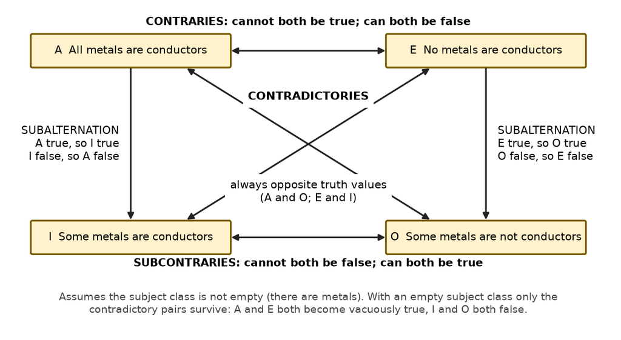

1. **Contradictory:** the two propositions always have opposite truth values. A and O are contradictories, and so are E and I. If "All metals are conductors" is true, then "Some metals are not conductors" is false, and vice versa.

2. **Contrary:** the two cannot both be true but can both be false: A and E. "All students passed" and "No students passed" are both false if some passed and some did not.

3. **Subcontrary:** the two cannot both be false but can both be true: I and O. "Some students passed" and "Some students did not pass" are both true in the mixed case.

4. **Subalternation:** a universal implies its particular of the same quality, A to I and E to O. Truth passes downward (if A is true, I is true); falsity passes upward (if I is false, A is false). Nothing follows in the other directions.

5. **Assumption:** the contrary, subcontrary and subalternation relations hold only if the subject class has members. Contradictories hold regardless.

U9-OBJ07Objective

state the form of the four figures of syllogisms; define the major and minor premises of a syllogism; identify the subject, predicate and middle terms of a syllogism; and determine the quality and quantity of statements in syllogisms.

Source Unit 9 Overview objective 7

**The four figures** depend on where the middle term M stands in the two premises. S is the minor term (subject of the conclusion) and P is the major term (predicate of the conclusion) (Discussion 9.2, Table 9.2.4).

|  | **First figure** | **Second figure** | **Third figure** | **Fourth figure** |
| --- | --- | --- | --- | --- |
| Major premise | M - P | P - M | M - P | P - M |
| Minor premise | S - M | S - M | M - S | M - S |
| Conclusion | S - P | S - P | S - P | S - P |

1. **Terms.** The *major term* (P) is the predicate of the conclusion, the *minor term* (S) is its subject, and the *middle term* (M) appears in both premises but not in the conclusion.

2. **Premises.** The *major premise* contains M and the major term; the *minor premise* contains M and the minor term. The order in which they are written does not decide which is which.

3. **Quality and quantity.** Quality is affirmative or negative; quantity is universal or particular. A = universal affirmative, E = universal negative, I = particular affirmative, O = particular negative.

4. **Worked example.** "All cats are mammals; some animals are not mammals; therefore some animals are not cats" (the course's own example). Conclusion: S = animals, P = cats, so M = mammals. Major premise "All cats are mammals" (P - M: universal affirmative, A). Minor premise "Some animals are not mammals" (S - M: particular negative, O). Conclusion: particular negative, O. That is the **second figure**, mood AOO. It is valid: M is distributed in the minor premise (the predicate of a negative), and the negative premise gives a negative conclusion.

5. **Count.** Four figures with 16 premise combinations each give the course's 64 forms. Only 19 forms are valid (footnote 188).

Note*Course slip: Table 9.2.5 lists (PN, PN) twice and omits (PN, PA). The 16 premise pairs should include each combination once.*

U9-OBJ08Objective

assess the validity of simple logical arguments given in syllogistic form.

Source Unit 9 Overview objective 8

**Method.** Put the argument in standard form, mark S, P and M, then check the six rules. Breaking any rule makes the syllogism invalid (a fallacy). Satisfying all six makes it valid (Discussion 9.2).

1. **One meaning per term.** Otherwise there are four terms (equivocation). Example: "All rats are eaten by cats; rats squeal on their friends..." uses "rat" in two senses.

2. **Middle term distributed at least once.** Otherwise the fallacy of the undistributed middle: "All cats are mammals; all dogs are mammals; therefore all dogs are cats." "Mammals" is the predicate of two affirmatives, so it is never distributed.

3. **No term distributed in the conclusion unless it is distributed in its premise.** Otherwise illicit major or illicit minor: "All reptiles are animals; no dog is a reptile; therefore no dog is an animal." "Animal" is distributed in the negative conclusion but not in the major premise.

4. **Not two negative premises.** Otherwise exclusive premises: "No dog is an alligator; no cat is an alligator; therefore every dog is a cat."

5. **A negative premise requires a negative conclusion, and a negative conclusion requires a negative premise.** Otherwise an affirmative conclusion from a negative premise ("All dogs are animals; no animal is a tree; therefore all dogs are trees"), or exclusive inclusion ("Some tabby cats are not animals").

**A valid case checked.** "All biologists are scientists; some teachers are biologists; therefore some teachers are scientists." "Biologists" is distributed in the major premise; no term is distributed in the particular affirmative conclusion; there are no negatives. All rules pass, so it is valid (first figure, AII). Lemmas such as "no valid syllogism has two particular premises" give quick checks.

U9-OBJ09Objective

construct Venn diagrams for syllogisms and use them as a means of determining validity.

Source Unit 9 Overview objective 9

**Constructing the diagram (Discussion 9.2).**

1. Draw three overlapping circles labelled S (minor term), P (major term) and M (middle term). Their 7 inner regions are all the combinations of membership.

2. **Universal premise:** shade the region it declares empty. "All M are P" shades M outside P; "No M is P" shades M ∩ P. Draw universal premises first.

3. **Particular premise:** put an x in the unshaded region that must have a member. If the premise allows two regions, put the x on the line between them.

4. **Read the result.** Check whether the conclusion is already drawn. "All S are P" needs every part of S outside P to be shaded; "Some S are P" needs an x that lies wholly inside S ∩ P. If so, the syllogism is valid; if a region that would falsify the conclusion is still open, it is invalid.

5. **Example (diagrams below).** "All mammals are vertebrates" shades mammals outside vertebrates. "All whales are mammals" shades whales outside mammals. The only unshaded part of *whales* lies inside *vertebrates*, so "all whales are vertebrates" is valid. By contrast, "All fish are vertebrates; all whales are vertebrates; therefore whales are fish" leaves the region "whales that are vertebrates but not fish" (?) open, so it is invalid (undistributed middle).

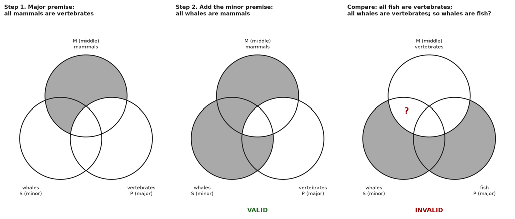

**Advantage.** The diagram checks validity "topologically": the middle-term requirements are handled automatically by the drawing, without memorizing the rules.

U9-OBJ10Objective

write out the truth tables for the logical connectives “and,” “or” and “implies,” and use them to construct truth tables for complex logical statements.

Source Unit 9 Overview objective 10

**Truth tables for the connectives (Discussion 9.2, Table 9.2.5).**

| **p** | **q** | **p∧q (and)** | **p∨q (or)** | **p→q (implies)** | **p↔q (iff)** |
| --- | --- | --- | --- | --- | --- |
| T | T | T | T | T | T |
| T | F | F | T | F | F |
| F | T | F | T | T | F |
| F | F | F | F | T | T |

1. **And** is true only when both parts are true.

2. **Or** (inclusive) is true when at least one part is true.

3. **Implies** is false only when a true p leads to a false q: "a true statement cannot imply a false statement," but a false one can imply anything.

4. **Building a complex table.** List the variables (2ⁿ rows for n variables), fill the right-hand column T, F, T, F..., the next one in pairs, and so on. Then work out the inner parts first and combine outward. Example, (p ∧ q) → r:

| **p** | **q** | **r** | **p∧q** | **(p∧q)→r** |
| --- | --- | --- | --- | --- |
| T | T | T | T | T |
| T | T | F | T | F |
| T | F | T | F | T |
| T | F | F | F | T |
| F | T | T | F | T |
| F | T | F | F | T |
| F | F | T | F | T |
| F | F | F | F | T |

5. **Reading it.** The statement fails in exactly one row (p and q true, r false). This is the one experiment that could refute "p and q together produce r."

### Lists and concept recall13

U9-R01Recall

Explain this topic from the assigned readings: the three principles of reason. Give an example or explain its significance in this unit.

Source Three principles of reason (Discussion 9.1)

1. **Leibniz.** Three principles have received general support as fundamental for accurate reasoning: non-contradiction, sufficient reason and the identity of indiscernibles. Gottfried Wilhelm von Leibniz (1646-1716) emphasized all three and took the first two as "the ultimate foundations of both reason and science" (Discussion 9.1). He dreamed of resolving disputes by calculation, with a universal language, the *characteristica universalis*, and a science of reason, the *calculus ratiocinator*, so that disputants could sit together and say, "Let us calculate." Leibniz occasionally acted as a diplomat.

2. **Why principles.** Knowledge gained by reason alone depends on its initial assumptions, so its fit with the world can never be guaranteed on rational grounds. Instead we base reasoning on principles that are the analogues of what appears universally true in experience (Discussion 9.1).

3. **The three principles.** Their statements in the course wording, their uses in science and the course examples:

| Principle | Statement (course wording) | How science uses it | Example |
| --- | --- | --- | --- |
| **Non-contradiction** (ironically, sometimes called the principle of contradiction) | "every statement involving a contradiction is to be judged false, and every statement that is the negation of a falsehood is to be judged true" | Analytic work: a contradiction signals an error in the argument, where a definition or rule of deduction was violated. Empirical work: a contradiction means an empirically derived assumption must be c… | "All triangles have four sides" asserts 3 = 4, so it is false, and "No triangle has four sides" is true; a non-white swan contradicts the assumption that all swans are white, so we change the assumpti… |
| **Sufficient reason** | Leibniz: "there can be no fact real or existing, no statement true, unless there be a sufficient reason, why it should be so and not otherwise" | The fundamental assumption of science: the world is ordered and its order is comprehensible to human reason; science explains deviations from an ideal of natural order, and where there is no deviation… | A fair balance with equal weights does not move; for Newton, straight-line motion at constant speed is natural, and a force (F = ma) is the sufficient reason for any deviation from it |
| **Identity of indiscernibles** | "two things that cannot be in any way distinguished from each other are to be considered identical" | Category formation and naming: two things get the same name if there is no essential difference between them; we must state the level of discourse and the criteria of identity | Lions and tigers are the same at the genus level (feline) but different species; two cue balls are "identical" for billiards |

4. **No contradiction in experience.** Nobody ever experiences a square triangle, a black white colour or freezing heat. Try to see both views of the Necker cube at once and you get a blurred figure or flat lines on the page, "what is actually there." Apparent contradictions are projected onto sensations, here by adding a third dimension to a two-dimensional drawing. So light is not "both a wave and a particle": "Ask a wave question and get a wave answer; ask a particle question and get a particle answer" (Discussion 9.1).

5. **Identity needs criteria.** Sufficient reason supports the identity of indiscernibles: if two things cannot be distinguished, there is no reason to treat them as different. An "essential difference" concerns "those qualities which it must possess in order to be entitled to its name" (Discussion 9.1). What counts as essential depends on context: race matters in a study of graduates' income by race, not in one by field of study; and in the Middle Eastern tale the governor is obliged to a poor man "because he is a human being."

6. **Example.** Two white billiard balls rolling on a table are two things; we call them identical only because there is no essential distinction between them "with respect to the game of billiards." One ball seen before and after we turn away is the same ball, displaced in time and space. A tree we planted, seen 10 years later, is harder: what criteria make it the same tree? Heraclitus said "you cannot step in the same river twice" (Discussion 9.1).

7. **Significance.** The principles give reasoning its best chance of fitting the world. Non-contradiction says what to dismiss: "Non-contradictory statements may or may not fit, but those that are contradictory definitely will not" (Discussion 9.1). Sufficient reason sets the task of science, explaining deviations from natural order. The identity of indiscernibles governs classification, which Unit 10 develops.

U9-R02Recall

Explain this topic from the assigned readings: the three interpretations of sufficient reason. Give an example or explain its significance in this unit.

Source Three interpretations of sufficient reason (Discussion 9.1)

1. **The principle.** Leibniz: "there can be no fact real or existing, no statement true, unless there be a sufficient reason, why it should be so and not otherwise" (Discussion 9.1). There is always a reason "why it is so and not otherwise." Discussion 9.1 gives three interpretations:

| Interpretation | Statement | Example |
| --- | --- | --- |
| 1. **Logical (analytical)** | In every true affirmative proposition the predicate is contained in the subject; in Aristotelian terms the particular is contained in the universal, so a thing has its characteristics because it belon… | What is true of all human beings must be true of each individual human being |
| 2. **Empirical** | "nothing ever comes to pass without a cause, or at least a reason"; we need a sufficient reason, not necessarily a single cause. It also shows up as the statistical **principle of equal a priori proba… | A fair balance with equal weights does not move, because there is no reason to prefer either direction; ozone depletion has no single cause (chlorine-bearing molecules that destroy ozone, their use in… |
| 3. **Efficient (optimality)** | Suggested by Leibniz for theological reasons and espoused by Pierre-Louis Moreau de Maupertuis (1698-1759): everything in nature follows a principle of maximization and minimization, the greatest resu… | Today the **principle of least action**: of all possible evolutions of a physical system, the one taken has minimal "action"; a theory built on an optimality principle is accepted as at least a possib… |

2. **Symmetry.** Sufficient reason and symmetry are closely related: the balance does not move because the two scales are symmetric (Discussion 9.1).

3. **Link to non-contradiction.** The Necker drawing is symmetric between its two views and gives no sufficient reason to prefer either view, so both can be seen (not at the same time) and contradictory opinions become possible. Hence wanting to remove contradiction is itself sufficient reason to seek sufficient reasons: "the desire to eliminate contradiction from reasoning is, in itself, sufficient reason for seeking sufficient reasons for the events of experience" (Discussion 9.1).

4. **Example.** "Sufficient" evidence means sufficient reason, not a quantity of evidence. Einstein's general relativity was accepted on almost no evidence: its predicted shift in the position of stars near the sun, from light bent by the sun's gravitational field, was confirmed by measurements during a solar eclipse in 1919, but only within 10 to 20 per cent. That was little against the mass of evidence for Newtonian gravitation, yet enough: "in the context of the times, it was sufficient reason to accept general relativity" (Discussion 9.1).

5. **Significance.** The principle is the fundamental assumption of science, that the world is ordered and its order is comprehensible to human reason. Its central use is the idea that science explains deviations from an ideal of natural order: Newton's force (F = ma) is the sufficient reason for deviation from straight-line motion. It also rules out explanation by "the capricious whim of some supernatural being" (Discussion 9.1).

U9-R03Recall

Explain this topic from the assigned readings: the four polarities of reason. Give an example or explain its significance in this unit.

Source Four polarities of reason (Discussion 9.1, Table 9.1.1)

1. **Four bipolar pairs.** Discussion 9.1 views scientific reasoning as the interaction of four bipolar pairs of concepts, which superficially line up as one dichotomy (Table 9.1.1):

| Polarity | Top-down side | Bottom-up side |
| --- | --- | --- |
| **Approach to systems** | **Top-down**: start with the whole system; its unity and the needs of its functioning are the sufficient reason for its parts (evolutionary psychology reads social behaviour by its contribution to rep… | **Bottom-up**: start with basic components and their interactions and build the system (genetics searching for specific genes for behaviour or disease) |
| **Inference method** | **Deduction**: inference by a formal logic (Aristotelian syllogisms or a propositional calculus), from the universal to the particular (it is canine or feline; it is not canine; so it is feline) | **Induction / abduction**: induction infers a general conclusion from a finite set of cases (the sun rises in the east; Snow on cholera); abduction is inference to the best explanation |
| **Reasoning process** | **Analysis**: divide the whole into parts and study them and their interactions; asks "What are the essential components of a system?" (chemical analysis; the body into systems, organs, tissues and ce… | **Synthesis**: combine elements into a coherent whole; asks "What is the unifying principle or idea?" (making water from hydrogen and oxygen; Snow combining strands of evidence) |
| **Form of explanation** | **Functional**: properties explained by the functions the system must fulfil in its environment (the peacock's plumage attracts a mate) | **Structural**: properties explained by components, their interactions and their fit (X-ray diffraction patterns explained by crystal lattice geometry) |

2. **Direction of causality.** The direction of causality follows the approach: top-down explains lower levels by higher-level causes, and bottom-up explains higher levels by lower-level causes (Discussion 9.1).

3. **Correspondences.** Top-down, we seek global laws and by analysis deduce the properties expected of the components, giving a functional explanation. Bottom-up, we begin with the components and their interactions and use induction to build a synthetic view, giving a structural explanation (Discussion 9.1).

4. **Example.** The hypothetico-deductive method uses both sides. From data, by induction or abduction, we generate an explanatory hypothesis (bottom-up synthesis); then we assume it and deduce testable consequences (top-down); a fit raises confidence, a misfit (contradiction) means adjusting the hypothesis. Even the starting data is "theory-laden," so top-down aspects appear in the posing of the question. Evolutionary psychology deduces the cognitive modules needed for Paleolithic survival, trying to construct "flow charts for the mind," and complements this with bottom-up synthesis from studies of cognitive abilities; the cycle is valid only as far as its basic assumption, genetic determination, fits reality (Discussion 9.1).

5. **Significance.** Science does not choose one side; it needs "a functional balance employing both," and its vitality depends on the interplay (Discussion 9.1). Francis Bacon put it as a double ladder: "[A]ll true and fruitful natural philosophy hath a double scale or ladder, ascendant and descendent, ascending from experiments to the invention of causes, and descending from causes to the invention of new experiments." The scientist's job is to know which approach and which questions each moment of research needs.

U9-R04Recall

Explain this topic from the assigned readings: the three forms of inference: deduction, induction and abduction. Give an example or explain its significance in this unit.

Source Three forms of inference (Discussion 9.1)

1. **Three forms.** Deduction is inference according to a formalized logic, from the universal to the particular; induction is the inference of a general, universal conclusion from a finite set of examples; abduction, first distinguished by the American logician Charles Sanders Peirce, is inference to the best explanation (Discussion 9.1).

| Form | Pattern (balls and bag) | Certainty |
| --- | --- | --- |
| **Deduction** (categorical inference) | All of the balls in that bag are black; these balls are from that bag; therefore these balls are black | Certain if the premises are true |
| **Induction** (statistical inference) | These balls are from that bag; these balls are black; therefore all of the balls in that bag are black | Never certain: by the "problem of induction" there is no certain justification except experience, and there is no formal "logic of discovery" |
| **Abduction** (inference to the best explanation, C. S. Peirce) | All of the balls in that bag are black; these balls are black; therefore these balls are from that bag | A best fit among the possible explanations, not a proof |

2. **Pattern rules.** From the deductive pattern, induction swaps the parts: major premise → conclusion, minor premise → major premise, conclusion → minor premise. Abduction keeps the major premise and swaps minor premise ↔ conclusion. From the abductive pattern, induction keeps the minor premise and swaps major premise ↔ conclusion (Discussion 9.1). Checking with the balls: the deductive conclusion "these balls are black" is the minor premise of both induction and abduction.

3. **Fuller examples.** Induction: in 1000 samples drawn from the bag the ratio of black to white balls is *r*, so the ratio in the bag is *r*, with an estimate of statistical error. Abduction: bag A has more black balls than white and bag B more white than black; this ball is black, so it is probably from bag A. Deduction: every furry carnivore is canine or feline; this one is not canine; therefore it must be feline (Discussion 9.1).

4. **Example.** Abduction is how the mind meets the unusual: when the expected order is altered, the brain searches memory or generates explanations until one seems satisfactory, "or in desperation will make up an explanation" (Discussion 9.1). Choosing among possibilities on a single clue, or on several apparently unrelated clues, is abductive. Inductively, we expect the sun to rise in the east from a finite number of past mornings, and Snow concluded that cholera is spread by contaminated water.

5. **Significance.** The hypothetico-deductive method uses all three: begin with data and, by induction or abduction, generate an explanatory hypothesis (ideally several, keeping the most likely for testing), then deduce consequences that can be tested (Discussion 9.1). Only deduction is certain, and only given its premises, so a hypothesis reached by induction or abduction stays provisional until it is tested.

U9-R05Recall

Explain this topic from the assigned readings: logical validity versus empirical truth. Give an example or explain its significance in this unit.

Source Validity versus truth (Unit 9 Overview; Derry ch. 7)

1. **Validity.** Logical validity is about form, or coherence: an argument is valid when its conclusion follows necessarily from its premises, whatever the premises say. In the modern view logic applies to language usage, to how we can legitimately use words and evaluate true or false statements; it "applies to the world only to the extent that our linguistic descriptions fit the world" (Unit 9 Overview). Modern logic "deals only with the form of statements" (Discussion 9.2).

2. **Truth.** Empirical truth is about fit with the world, and only observation or experiment can settle it. Because validity rests on coherence and truth on fit, "logical validity (which is based on coherence) and empirical truth may disagree" (Unit 9 Overview).

3. **Do not confuse them.** "It is a serious mistake to confuse empirical truth and logical validity" (Unit 9 Overview). The course example: Pigs are mammals; All mammals can fly; Therefore pigs can fly. The argument is logically valid but its conclusion is empirically false, because the premise that all mammals can fly is false.